# T3 Experiment Pilot: Condition Comparison

Contact vs. Chat vs. Game — Pre-Post Changes by Condition

Published

March 4, 2026

## Sample

```r
n_total <- nrow(dat)
n_by_condition <- dat %>% count(treatment)
n_contact <- n_by_condition %>% filter(treatment == "Contact") %>% pull(n)
if (!pool_controls) {
  n_chat <- n_by_condition %>% filter(treatment == "Chat") %>% pull(n)
  n_game <- n_by_condition %>% filter(treatment == "Game") %>% pull(n)
} else {
  n_control <- n_by_condition %>% filter(treatment == "Control") %>% pull(n)
}
mean_age   <- mean(dat$age, na.rm = TRUE)
pct_female <- mean(dat$gender == "Female", na.rm = TRUE) * 100
```

We recruited 401 participants from Prolific: 208 in the Contact condition and 193 in the Control condition (Chat + Game pooled; mean age = 42.20, 52% female).

```r
dat %>%
  group_by(treatment) %>%
  summarise(
    N = n(),
    `Democrats (D→R)` = sum(learner_party == "D→R"),
    `Republicans (R→D)` = sum(learner_party == "R→D"),
    `Mean Age` = mean(age, na.rm = TRUE) %>% numformat(),
    `% Female` = (sum(gender == "Female", na.rm = TRUE) / n() * 100) %>% numformat(0),
    `Extremism (M)` = mean(political_extremism, na.rm = TRUE) %>% numformat(),
    .groups = "drop"
  ) %>%
  gt() %>%
  tab_header(title = "Sample Composition by Condition")
```

Sample Composition by Condition

| treatment | N | Democrats (D→R) | Republicans (R→D) | Mean Age | % Female | Extremism (M) |
| --- | --- | --- | --- | --- | --- | --- |
| Contact | 208 | 99 | 109 | 41.30 | 50 | 76.36 |
| Control | 193 | 103 | 90 | 43.17 | 53 | 77.84 |

```r
# Actual green score by party (from own responses)
actual_by_party <- dat %>%
  group_by(learner_party) %>%
  summarise(
    actual = mean(actual_green, na.rm = TRUE) %>% numformat(),
    .groups = "drop"
  )

dat %>%
  group_by(treatment, learner_party) %>%
  summarise(
    `Baseline belief (M)` = mean(green_outgroup_pre, na.rm = TRUE) %>% numformat(),
    .groups = "drop"
  ) %>%
  left_join(actual_by_party, by = "learner_party") %>%
  rename(Condition = treatment, `Learner party` = learner_party,
         `Actual outgroup mean` = actual) %>%
  gt() %>%
  tab_header(title = "Baseline Outgroup Env. Beliefs by Condition and Party",
             subtitle = "Composite mean of env1–6 (1–5 scale); higher = more pro-environment attributed to outgroup") %>%
  tab_footnote("Actual = true mean from the outgroup's own responses. D→R = Democrats estimating Republicans; R→D = Republicans estimating Democrats.",
               locations = cells_title())
```

Mean baseline outgroup environmental attitude beliefs (composite of env1–6, 1–5 scale) by condition and learner party. ‘Actual’ is the true mean of the outgroup’s own responses (Republicans’ actual for D→R; Democrats’ actual for R→D).

Baseline Outgroup Env. Beliefs by Condition and Party<sup>1</sup>

Composite mean of env1–6 (1–5 scale); higher = more pro-environment attributed to outgroup<sup>1</sup>

| Condition | Learner party | Baseline belief (M) | Actual outgroup mean |
| --- | --- | --- | --- |
| Contact | D→R | 2.10 | 3.59 |
| Contact | R→D | 3.86 | 4.06 |
| Control | D→R | 2.09 | 3.59 |
| Control | R→D | 3.94 | 4.06 |

<sup>1</sup> Actual = true mean from the outgroup's own responses. D→R = Democrats estimating Republicans; R→D = Republicans estimating Democrats.

### Condition balance check

```r
# Check randomization: are conditions balanced on baseline measures?
bal_acc  <- aov(accuracy_pre ~ treatment, data = dat)
bal_warm <- aov(warmth_outgroup_pre ~ treatment, data = dat)
bal_ext  <- aov(political_extremism ~ treatment, data = dat)

bal_acc_p  <- summary(bal_acc)[[1]][["Pr(>F)"]][1]
bal_warm_p <- summary(bal_warm)[[1]][["Pr(>F)"]][1]
bal_ext_p  <- summary(bal_ext)[[1]][["Pr(>F)"]][1]
```

### Differential engagement / cheating check

```r
# Survey phase: tab switches and hidden time (same for all conditions)
eng_survey_aov_switch <- aov(tab_switch_count   ~ treatment, data = dat)
eng_survey_aov_hidden <- aov(I(time_hidden_ms / 1000) ~ treatment, data = dat)
eng_survey_switch_p <- summary(eng_survey_aov_switch)[[1]][["Pr(>F)"]][1]
eng_survey_hidden_p <- summary(eng_survey_aov_hidden)[[1]][["Pr(>F)"]][1]

# Intervention phase: tab switches and time in intervention window
eng_bot_aov_switch <- aov(tab_switch_count_bot ~ treatment, data = dat)
eng_bot_aov_hidden <- aov(I(time_hidden_ms_bot / 60000) ~ treatment, data = dat)
eng_bot_switch_p <- summary(eng_bot_aov_switch)[[1]][["Pr(>F)"]][1]
eng_bot_hidden_p <- summary(eng_bot_aov_hidden)[[1]][["Pr(>F)"]][1]

# Pairwise for bot tab switches (the only marginally significant survey metric)
eng_bot_switch_tukey <- dat %>% tukey_hsd(tab_switch_count_bot ~ treatment)
if (!pool_controls) {
  eng_bot_contact_game_p <- eng_bot_switch_tukey %>%
    filter(group1 == "Contact", group2 == "Game") %>% pull(p.adj)
} else {
  eng_bot_contact_game_p <- eng_bot_switch_tukey %>%
    filter(group1 == "Contact", group2 == "Control") %>% pull(p.adj)
}

# Summary table
eng_summary <- dat %>%
  group_by(treatment) %>%
  summarise(
    `Survey switches (M)` = mean(tab_switch_count, na.rm = TRUE),
    `Survey hidden (sec, M)` = mean(time_hidden_ms / 1000, na.rm = TRUE),
    `Intervention switches (M)` = mean(tab_switch_count_bot, na.rm = TRUE),
    `Intervention time in window (min, M)` = mean(time_hidden_ms_bot / 60000, na.rm = TRUE),
    .groups = "drop"
  )
```

```r
eng_summary %>%
  mutate(across(where(is.double), ~ numformat(.x))) %>%
  rename(Condition = treatment) %>%
  gt() %>%
  tab_header(title = "Engagement by Condition") %>%
  tab_footnote(
    "Survey phase: tab switches and hidden time during the questionnaire. Intervention phase: switches and time during the treatment window.",
    locations = cells_title()
  )
```

Engagement by Condition<sup>1</sup>

| Condition | Survey switches (M) | Survey hidden (sec, M) | Intervention switches (M) | Intervention time in window (min, M) |
| --- | --- | --- | --- | --- |
| Contact | 0.21 | 2.85 | 1.45 | 4.49 |
| Control | 0.12 | 1.86 | 0.70 | 0.28 |

<sup>1</sup> Survey phase: tab switches and hidden time during the questionnaire. Intervention phase: switches and time during the treatment window.

### Outlier removal

```r
dat <- dat %>%
  mutate(
    acc_change  = accuracy_post - accuracy_pre,
    warm_change = warmth_outgroup_post - warmth_outgroup_pre
  )

# ── Cook's D > 4/n from ANCOVA (accuracy and warmth) ─────────────────────────
ancova_acc  <- lm(accuracy_post        ~ accuracy_pre        + treatment, data = dat)
ancova_warm <- lm(warmth_outgroup_post ~ warmth_outgroup_pre + treatment, data = dat)
cooks_thresh <- 4 / nrow(dat)

dat <- dat %>%
  mutate(
    cooks_acc  = cooks.distance(ancova_acc),
    cooks_warm = cooks.distance(ancova_warm),
    flag_cooks = cooks_acc > cooks_thresh | cooks_warm > cooks_thresh
  )

# ── Mahalanobis distance on (acc_change, warm_change) ────────────────────────
# Chi-square threshold: p < .025, df = 2
mah_thresh <- qchisq(0.975, df = 2)
dat <- dat %>%
  mutate(
    mah_d    = mahalanobis(cbind(acc_change, warm_change),
                           colMeans(cbind(acc_change, warm_change), na.rm = TRUE),
                           cov(cbind(acc_change, warm_change), use = "complete.obs")),
    flag_mah = mah_d > mah_thresh
  )

ids_cooks <- dat$ResponseId[dat$flag_cooks]
ids_mah   <- dat$ResponseId[dat$flag_mah]
n_cooks   <- length(ids_cooks)
n_mah     <- length(ids_mah)
n_overlap <- sum(ids_mah %in% ids_cooks)   # Mah is a strict subset of Cook's D

# Use Mahalanobis for removal (more conservative; Cook's D subset already included)
outlier_ids <- ids_mah
n_before  <- nrow(dat)
dat       <- dat %>% filter(!ResponseId %in% outlier_ids)
n_removed <- n_before - nrow(dat)

# ── Regression-to-mean evidence (on cleaned data) ────────────────────────────
rtm_cors <- dat %>%
  group_by(treatment) %>%
  summarise(r_pre_change = cor(accuracy_pre, acc_change, use = "complete.obs"),
            .groups = "drop")
rtm_cors_text <- rtm_cors %>%
  mutate(s = paste0(treatment, ": *r* = ", numformat(r_pre_change))) %>%
  pull(s) %>% paste(collapse = ", ")
```

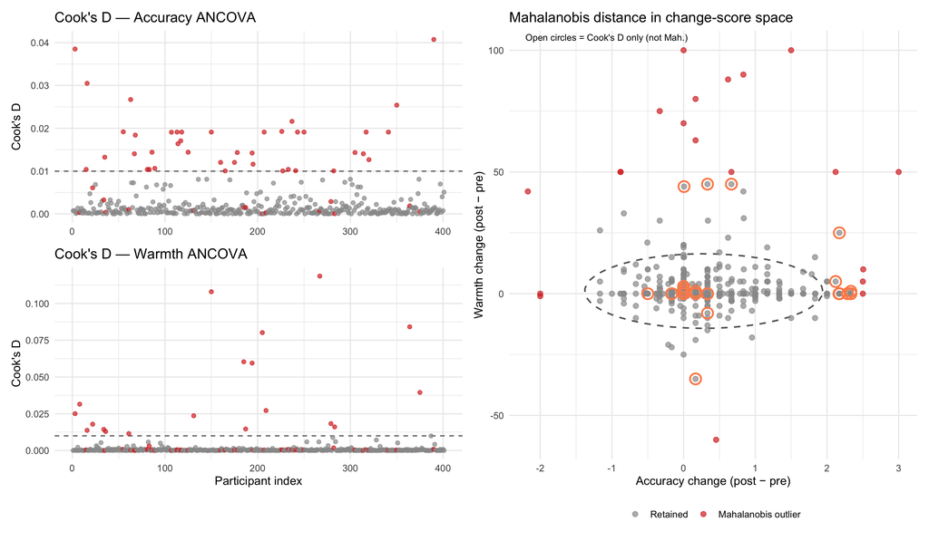

```r
dat_all <- bind_rows(
  dat,
  bind_rows(
    filter(read_parquet(paste0(base_path, if (full_data) "analysis_data.parquet" else "analysis_data_Feb17.parquet")),
           TRUE) %>%
      mutate(
        acc_change  = accuracy_post - accuracy_pre,
        warm_change = warmth_outgroup_post - warmth_outgroup_pre,
        treatment   = factor(if (pool_controls)
                               if_else(treatment == "Contact", "Contact", "Control")
                             else treatment,
                             levels = if (pool_controls) c("Contact","Control")
                                      else c("Contact","Chat","Game"))
      )
  ) %>% filter(ResponseId %in% c(ids_cooks, ids_mah))
) %>% distinct(ResponseId, .keep_all = TRUE)

# Rebuild Cook's D on full pre-removal data for plotting
dat_pre <- read_parquet(paste0(base_path, if (full_data) "analysis_data.parquet" else "analysis_data_Feb17.parquet")) %>%
  mutate(
    acc_change  = accuracy_post - accuracy_pre,
    warm_change = warmth_outgroup_post - warmth_outgroup_pre,
    treatment   = factor(if (pool_controls)
                           if_else(treatment == "Contact", "Contact", "Control")
                         else treatment,
                         levels = if (pool_controls) c("Contact","Control")
                                  else c("Contact","Chat","Game"))
  )

anc_acc_pre  <- lm(accuracy_post        ~ accuracy_pre        + treatment, data = dat_pre)
anc_warm_pre <- lm(warmth_outgroup_post ~ warmth_outgroup_pre + treatment, data = dat_pre)
mah_pre <- mahalanobis(
  cbind(dat_pre$acc_change, dat_pre$warm_change),
  colMeans(cbind(dat_pre$acc_change, dat_pre$warm_change), na.rm = TRUE),
  cov(cbind(dat_pre$acc_change, dat_pre$warm_change), use = "complete.obs")
)

plot_dat <- dat_pre %>%
  mutate(
    cooks_acc  = cooks.distance(anc_acc_pre),
    cooks_warm = cooks.distance(anc_warm_pre),
    mah_d      = mah_pre,
    flag_cooks = cooks_acc > cooks_thresh | cooks_warm > cooks_thresh,
    flag_mah   = mah_d > mah_thresh,
    idx        = row_number()
  )

# Cook's D panels
p_cook_acc <- ggplot(plot_dat, aes(x = idx, y = cooks_acc, color = flag_cooks)) +
  geom_hline(yintercept = cooks_thresh, linetype = "dashed", color = "gray40") +
  geom_point(size = 1.5, alpha = 0.7) +
  scale_color_manual(values = c("FALSE" = "gray60", "TRUE" = "#D73027"), guide = "none") +
  labs(x = NULL, y = "Cook's D", title = "Cook's D — Accuracy ANCOVA") +
  theme_minimal(base_size = 11)

p_cook_warm <- ggplot(plot_dat, aes(x = idx, y = cooks_warm, color = flag_cooks)) +
  geom_hline(yintercept = cooks_thresh, linetype = "dashed", color = "gray40") +
  geom_point(size = 1.5, alpha = 0.7) +
  scale_color_manual(values = c("FALSE" = "gray60", "TRUE" = "#D73027"), guide = "none") +
  labs(x = "Participant index", y = "Cook's D", title = "Cook's D — Warmth ANCOVA") +
  theme_minimal(base_size = 11)

# Mahalanobis scatter
p_mah <- ggplot(plot_dat, aes(x = acc_change, y = warm_change)) +
  stat_ellipse(level = 0.975, linetype = "dashed", color = "gray40", linewidth = 0.7) +
  geom_point(aes(color = flag_mah), size = 2, alpha = 0.7) +
  geom_point(data = filter(plot_dat, flag_cooks & !flag_mah),
             shape = 1, size = 4, color = "#FC8D59", stroke = 1.2) +
  scale_color_manual(values = c("FALSE" = "gray60", "TRUE" = "#D73027"),
                     labels = c("Retained", "Mahalanobis outlier"),
                     name = NULL) +
  annotate("text", x = -Inf, y = Inf, hjust = -0.1, vjust = 1.5, size = 3,
           label = "Open circles = Cook's D only (not Mah.)") +
  labs(x = "Accuracy change (post − pre)", y = "Warmth change (post − pre)",
       title = "Mahalanobis distance in change-score space") +
  theme_minimal(base_size = 11) +
  theme(legend.position = "bottom")

(p_cook_acc / p_cook_warm) | p_mah
```

**Outlier methods compared.** Cook’s D (threshold 4/*n* = 0.0100) flagged 56 participants across the two ANCOVA models. Mahalanobis distance on the joint (accuracy change, warmth change) space (χ² threshold *p* < .025, df = 2) flagged 20, all of whom were also flagged by Cook’s D. The remaining 36 Cook’s D flags were influential in one ANCOVA but not extreme in the bivariate change space. We use the **Mahalanobis criterion** for removal as it directly captures participants with unusual *combinations* of change scores, is scale-invariant, and results in a more conservative exclusion (*N* removed = 20). All analyses below use the cleaned sample (*N* = 381).

**Baseline and change.** Within each condition, participants who started with the lowest accuracy tended to show the largest improvements (Contact: *r* = -0.72, Control: *r* = -0.61). This is mechanically expected in any pre-post design and applies similarly across conditions, so it does not confound the condition comparison. The DiD contrast and ANCOVA below account for baseline by design.

```r
desc_vars <- list(
  "Accuracy (pre)"        = "accuracy_pre",
  "Accuracy (post)"       = "accuracy_post",
  "Warmth (pre)"          = "warmth_outgroup_pre",
  "Warmth (post)"         = "warmth_outgroup_post",
  "Confidence (pre)"      = "confidence_outgroup_pre",
  "Confidence (post)"     = "confidence_outgroup_post",
  "Donation (cents)"      = "donation",
  "Age"                   = "age",
  "Political extremism"   = "political_extremism"
)

fmt_msd <- function(x) {
  m <- mean(x, na.rm = TRUE)
  s <- sd(x,   na.rm = TRUE)
  paste0(numformat(m), " (", numformat(s), ")")
}

conds <- levels(dat$treatment)

desc_tbl <- map_dfr(names(desc_vars), function(label) {
  col <- desc_vars[[label]]
  row <- tibble(Variable = label, Overall = fmt_msd(dat[[col]]))
  for (cond in conds) {
    row[[cond]] <- fmt_msd(dat[[col]][dat$treatment == cond])
  }
  row
})

desc_tbl %>%
  gt() %>%
  tab_header(title = "Descriptive Statistics by Condition",
             subtitle = "M (SD); after Cook's D outlier removal") %>%
  tab_footnote("Accuracy = negative absolute error (higher = more accurate). Warmth on 0–100 scale. Confidence on 1–5 scale.",
               locations = cells_title())
```

Descriptive statistics (M ± SD) for all key variables overall and by condition, after outlier removal.

Descriptive Statistics by Condition<sup>1</sup>

| Variable | Overall | Contact | Control |
| --- | --- | --- | --- |
| Accuracy (pre) | -1.12 (0.83) | -1.13 (0.83) | -1.10 (0.84) |
| Accuracy (post) | -0.77 (0.64) | -0.76 (0.60) | -0.78 (0.68) |
| Warmth (pre) | 33.04 (25.99) | 35.86 (26.20) | 29.99 (25.49) |
| Warmth (post) | 34.83 (27.10) | 38.21 (27.42) | 31.17 (26.35) |
| Confidence (pre) | 3.12 (1.02) | 3.08 (1.05) | 3.16 (0.98) |
| Confidence (post) | 3.39 (1.01) | 3.47 (0.96) | 3.30 (1.06) |
| Donation (cents) | 20.15 (21.50) | 20.13 (21.40) | 20.17 (21.68) |
| Age | 42.17 (13.40) | 41.04 (13.32) | 43.39 (13.42) |
| Political extremism | 76.85 (24.10) | 76.05 (25.37) | 77.72 (22.68) |

<sup>1</sup> Accuracy = negative absolute error (higher = more accurate). Warmth on 0–100 scale. Confidence on 1–5 scale.

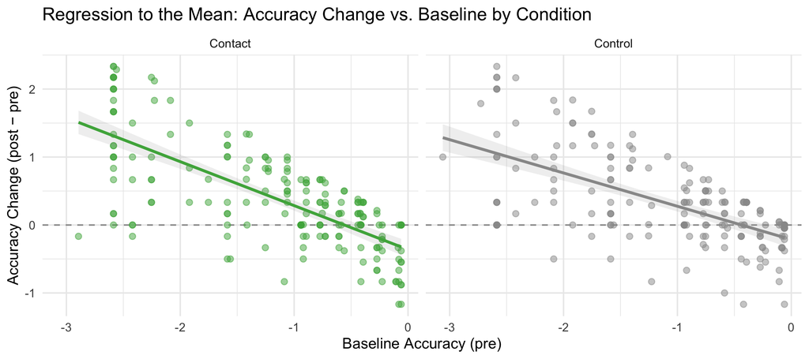

Accuracy change vs. baseline accuracy by condition. Strong negative slopes indicate regression to the mean: participants who started most inaccurate improved most, regardless of condition.

```r
ggplot(dat, aes(x = accuracy_pre, y = acc_change, color = treatment)) +
  geom_hline(yintercept = 0, linetype = "dashed", color = "gray60") +
  geom_point(alpha = 0.5, size = 2) +
  geom_smooth(method = "lm", se = TRUE, alpha = 0.15) +
  scale_color_manual(values = condition_colors, name = "Condition") +
  facet_wrap(~ treatment) +
  labs(
    x = "Baseline Accuracy (pre)",
    y = "Accuracy Change (post − pre)",
    title = "Regression to the Mean: Accuracy Change vs. Baseline by Condition"
  ) +
  theme_minimal(base_size = 12) +
  theme(legend.position = "none")
```

```r
ggsave(paste0(fig_path, "rtm_check.png"), width = 9, height = 4, dpi = 300)
```

## Pre-Post Changes Overall

Before examining condition differences, we verify that the pre-post design shows evidence of change across the full sample.

```r
# Accuracy
acc_overall <- t.test(dat$accuracy_post, dat$accuracy_pre, paired = TRUE)
acc_d_overall <- mean(dat$accuracy_post - dat$accuracy_pre) / sd(dat$accuracy_post - dat$accuracy_pre)

# Warmth
warm_overall <- t.test(dat$warmth_outgroup_post, dat$warmth_outgroup_pre, paired = TRUE)
warm_d_overall <- mean(dat$warmth_outgroup_post - dat$warmth_outgroup_pre) / sd(dat$warmth_outgroup_post - dat$warmth_outgroup_pre)

# Confidence
conf_overall <- t.test(dat$confidence_outgroup_post, dat$confidence_outgroup_pre, paired = TRUE)
conf_d_overall <- mean(dat$confidence_outgroup_post - dat$confidence_outgroup_pre) / sd(dat$confidence_outgroup_post - dat$confidence_outgroup_pre)
```

Across the full sample, accuracy improved (*t*(380) = 9.60, *p* < .001, *d* = 0.49), outgroup warmth increased (*t*(380) = 4.28, *p* < .001, *d* = 0.22), and confidence changed (*t*(380) = 4.94, *p* < .001, *d* = 0.25).

## Condition Differences (Main Analysis)

The primary question is whether the Contact condition shows greater pre-post improvement than the two control conditions (Chat, Game) pooled together. We use a mixed-effects model with a `time × treatment` interaction, and test the key contrast: Contact Δ vs. average of Chat Δ and Game Δ.

### Accuracy

```r
accuracy_long <- dat %>%
  select(ResponseId, treatment, learner_party, accuracy_pre, accuracy_post) %>%
  pivot_longer(c(accuracy_pre, accuracy_post),
               names_to = "time", names_pattern = "accuracy_(pre|post)",
               values_to = "accuracy") %>%
  mutate(time = factor(time, levels = c("pre", "post")))

# Model: time × treatment (reference = Contact)
m_acc <- lmer(accuracy ~ time * treatment + (1 | ResponseId), data = accuracy_long)

# Pre-post differences within each condition
emm_acc_by_cond <- emmeans(m_acc, ~ time | treatment)
acc_contrasts <- contrast(emm_acc_by_cond, "revpairwise", by = "treatment") %>%
  as_tibble()  # positive = improvement (post - pre)

# Full grid for DiD contrasts — adaptive to pool_controls toggle
# Grid order (3-cond): pre×Contact, post×Contact, pre×Chat, post×Chat, pre×Game, post×Game
# Grid order (pooled): pre×Contact, post×Contact, pre×Control, post×Control
emm_acc_full <- emmeans(m_acc, ~ time * treatment)
pull_did <- function(tbl, nm, col) tbl %>% filter(contrast == nm) %>% pull({{ col }})

if (pool_controls) {
  acc_did <- contrast(emm_acc_full, list(
    `Contact vs. Control` = c(1, -1, -1, 1)   # Control Δ - Contact Δ ... sign: positive = Control > Contact
  ))
  # flip sign so positive = Contact improved more
  acc_did_tbl <- acc_did %>% as_tibble() %>% mutate(estimate = -estimate)
  acc_main_b  <- pull_did(acc_did_tbl, "Contact vs. Control", estimate)
  acc_main_se <- pull_did(acc_did_tbl, "Contact vs. Control", SE)
  acc_main_p  <- pull_did(acc_did_tbl, "Contact vs. Control", p.value)
  acc_chat_vs_contact_b <- NA_real_; acc_chat_vs_contact_p <- NA_real_
  acc_game_vs_contact_b <- NA_real_; acc_game_vs_contact_p <- NA_real_
  acc_chat_vs_game_b    <- NA_real_; acc_chat_vs_game_p    <- NA_real_
} else {
  acc_did <- contrast(emm_acc_full, list(
    `Contact vs. pooled controls` = c(-1,  1,  0.5, -0.5,  0.5, -0.5),
    `Chat vs. Contact`            = c( 1, -1, -1,    1,    0,    0  ),
    `Game vs. Contact`            = c( 1, -1,  0,    0,   -1,    1  ),
    `Chat vs. Game`               = c( 0,  0, -1,    1,    1,   -1  )
  ))
  acc_did_tbl           <- acc_did %>% as_tibble()
  acc_main_b            <- pull_did(acc_did_tbl, "Contact vs. pooled controls", estimate)
  acc_main_se           <- pull_did(acc_did_tbl, "Contact vs. pooled controls", SE)
  acc_main_p            <- pull_did(acc_did_tbl, "Contact vs. pooled controls", p.value)
  acc_chat_vs_contact_b <- pull_did(acc_did_tbl, "Chat vs. Contact", estimate)
  acc_chat_vs_contact_p <- pull_did(acc_did_tbl, "Chat vs. Contact", p.value)
  acc_game_vs_contact_b <- pull_did(acc_did_tbl, "Game vs. Contact", estimate)
  acc_game_vs_contact_p <- pull_did(acc_did_tbl, "Game vs. Contact", p.value)
  acc_chat_vs_game_b    <- pull_did(acc_did_tbl, "Chat vs. Game",    estimate)
  acc_chat_vs_game_p    <- pull_did(acc_did_tbl, "Chat vs. Game",    p.value)
}
```

The time × treatment interaction tests whether conditions differed in accuracy improvement.

```r
acc_contrasts %>%
  select(Condition = treatment,
         `Pre→Post Improvement` = estimate,
         SE, df, `t-ratio` = t.ratio, `p-value` = p.value) %>%
  mutate(
    `Pre→Post Improvement` = numformat(`Pre→Post Improvement`),
    SE = numformat(SE),
    df = numformat(df, 0),
    `t-ratio` = numformat(`t-ratio`),
    `p-value` = map_chr(`p-value`, pformat)
  ) %>%
  gt() %>%
  tab_header(title = "Accuracy: Pre-Post Improvement by Condition") %>%
  tab_footnote("Positive = improvement. Estimated from mixed-effects model (Contact as reference).",
               locations = cells_title())
```

Accuracy: Pre-Post Improvement by Condition<sup>1</sup>

| Condition | Pre→Post Improvement | SE | df | t-ratio | p-value |
| --- | --- | --- | --- | --- | --- |
| Contact | 0.37 | 0.05 | 379 | 7.36 | < .001 |
| Control | 0.33 | 0.05 | 379 | 6.20 | < .001 |

<sup>1</sup> Positive = improvement. Estimated from mixed-effects model (Contact as reference).

**Primary test:** Contact vs. Control: *b* = 0.05, SE = 0.07, *p* = 0.528.

### Model choice: lmer vs. ANCOVA

```r
# Pre-post correlation by condition (drives the key tradeoff between lmer and ANCOVA)
prepost_cors <- dat %>%
  group_by(treatment) %>%
  summarise(
    r_prepost = cor(accuracy_pre, accuracy_post, use = "complete.obs"),
    .groups = "drop"
  )

# ANCOVA: regress post on pre + treatment
ancova_acc <- lm(accuracy_post ~ accuracy_pre + treatment, data = dat)
ancova_pre_coef <- coef(ancova_acc)["accuracy_pre"]
ancova_pre_se   <- summary(ancova_acc)$coefficients["accuracy_pre", "Std. Error"]
ancova_pre_p    <- summary(ancova_acc)$coefficients["accuracy_pre", "Pr(>|t|)"]

# Test homogeneity of regression slopes (pre × condition interaction)
ancova_hom   <- lm(accuracy_post ~ accuracy_pre * treatment, data = dat)
ancova_hom_p <- anova(ancova_acc, ancova_hom)$`Pr(>F)`[2]

if (!pool_controls) {
  ancova_game_b <- coef(ancova_acc)["treatmentGame"]
  ancova_chat_b <- coef(ancova_acc)["treatmentChat"]
  ancova_game_p <- summary(ancova_acc)$coefficients["treatmentGame", "Pr(>|t|)"]
  ancova_chat_p <- summary(ancova_acc)$coefficients["treatmentChat", "Pr(>|t|)"]
} else {
  ancova_game_b <- NA_real_; ancova_chat_b <- NA_real_
  ancova_game_p <- NA_real_; ancova_chat_p <- NA_real_
}
```

For a **randomized pre-post design**, both `lmer(accuracy ~ time * treatment + (1|id))` and `lm(accuracy_post ~ accuracy_pre + treatment)` (ANCOVA) are valid, but they make different assumptions. **ANCOVA** is generally preferred in randomized experiments [@vickers2001analysing]. It regresses the post-score on the pre-score as a covariate, removing pre-score variance from the residuals and increasing statistical power. In our data, the pre-score coefficient is *b* = 0.43 (*SE* = 0.03, *p* < .001): substantially less than 1.0, which means there is regression to the mean and ANCOVA extracts more power than a change-score approach.

**lmer** (`lmer(y ~ time * treatment + (1|id))`) models both time points jointly with a random intercept per participant. The random intercept implicitly assumes the pre-score coefficient equals 1, equivalent to an ANCOVA with *b* = 1 for `pre`. When the true pre-post correlation is well below 1 — here *r* = 0.49 (Contact), *r* = 0.63 (Control) — the lmer model leaves avoidable residual variance on the table.

**Homogeneity of slopes:** ANCOVA requires the pre → post regression slope to be the same in all conditions. The `pre × treatment` interaction test gives *p* = 0.016. This assumption is borderline violated; lmer is more robust in this case.

**Both models agree:** conditions do not differ significantly in accuracy improvement. For the pre-registered full study, we will use **ANCOVA** as the primary specification and lmer as a robustness check.

```r
# Build a side-by-side comparison table: lmer DiD vs ANCOVA
ancova_se_mat <- summary(ancova_acc)$coefficients

if (pool_controls) {
  # Only one contrast available: Contact vs. Control
  ancova_ctrl_b  <- coef(ancova_acc)["treatmentControl"]
  ancova_ctrl_se <- ancova_se_mat["treatmentControl", "Std. Error"]
  ancova_ctrl_p  <- ancova_se_mat["treatmentControl", "Pr(>|t|)"]
  model_compare <- tribble(
    ~Contrast,              ~`lmer b`, ~`lmer SE`, ~`lmer p`,
                             ~`ANCOVA b`, ~`ANCOVA SE`, ~`ANCOVA p`,
    "Contact vs. Control",
      acc_main_b,
      pull_did(acc_did_tbl, "Contact vs. Control", SE),
      acc_main_p,
      -ancova_ctrl_b,        # flip sign: positive = Contact improved more
      ancova_ctrl_se,
      ancova_ctrl_p
  )
} else {
  model_compare <- tribble(
    ~Contrast,                    ~`lmer b`, ~`lmer SE`, ~`lmer p`,
                                   ~`ANCOVA b`, ~`ANCOVA SE`, ~`ANCOVA p`,
    "Contact vs. pooled controls",
      acc_main_b,
      pull_did(acc_did_tbl, "Contact vs. pooled controls", SE),
      acc_main_p,
      -(0.5 * ancova_chat_b + 0.5 * ancova_game_b),
      NA_real_, NA_real_,
    "Chat vs. Contact",
      acc_chat_vs_contact_b,
      pull_did(acc_did_tbl, "Chat vs. Contact", SE),
      acc_chat_vs_contact_p,
      ancova_chat_b,
      ancova_se_mat["treatmentChat", "Std. Error"],
      ancova_chat_p,
    "Game vs. Contact",
      acc_game_vs_contact_b,
      pull_did(acc_did_tbl, "Game vs. Contact", SE),
      acc_game_vs_contact_p,
      ancova_game_b,
      ancova_se_mat["treatmentGame", "Std. Error"],
      ancova_game_p,
    "Chat vs. Game",
      acc_chat_vs_game_b,
      pull_did(acc_did_tbl, "Chat vs. Game", SE),
      acc_chat_vs_game_p,
      ancova_chat_b - ancova_game_b,
      NA_real_, NA_real_
  )
}

model_compare %>%
  mutate(across(c(`lmer b`, `lmer SE`, `ANCOVA b`, `ANCOVA SE`),
                ~ ifelse(is.na(.x), "—", numformat(.x))),
         `lmer p`   = map_chr(`lmer p`,   ~ ifelse(is.na(.x), "—", pformat(.x))),
         `ANCOVA p` = map_chr(`ANCOVA p`, ~ ifelse(is.na(.x), "—", pformat(.x)))) %>%
  gt() %>%
  tab_header(title = "lmer vs. ANCOVA: Accuracy Condition Comparisons") %>%
  tab_spanner(label = "lmer (DiD contrast)", columns = c(`lmer b`, `lmer SE`, `lmer p`)) %>%
  tab_spanner(label = "ANCOVA (lm post ~ pre + condition)", columns = c(`ANCOVA b`, `ANCOVA SE`, `ANCOVA p`)) %>%
  tab_footnote("lmer estimates from emmeans DiD contrasts on the full time × treatment grid. ANCOVA estimates are regression coefficients (contact = reference). Contact vs. pooled ANCOVA SE omitted (non-standard linear combination).",
               locations = cells_title())
```

lmer vs. ANCOVA: Accuracy Condition Comparisons<sup>1</sup>

| Contrast | lmer (DiD contrast) lmer b | lmer (DiD contrast) lmer SE | lmer (DiD contrast) lmer p | ANCOVA (lm post ~ pre + condition) ANCOVA b | ANCOVA (lm post ~ pre + condition) ANCOVA SE | ANCOVA (lm post ~ pre + condition) ANCOVA p |
| --- | --- | --- | --- | --- | --- | --- |
| Contact vs. Control | 0.05 | 0.07 | = 0.528 | 0.03 | 0.05 | = 0.607 |

<sup>1</sup> lmer estimates from emmeans DiD contrasts on the full time × treatment grid. ANCOVA estimates are regression coefficients (contact = reference). Contact vs. pooled ANCOVA SE omitted (non-standard linear combination).

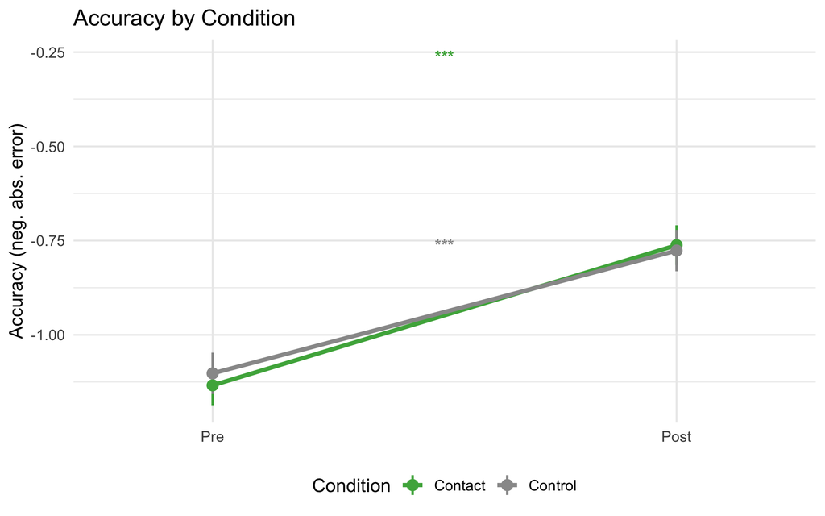

Accuracy (negative absolute error) by condition and time. Points show estimated marginal means ± SE from the mixed-effects model.

```r
emm_acc_tbl <- as_tibble(emm_acc_by_cond) %>%
  mutate(time = factor(time, levels = c("pre", "post")))

p_acc <- ggplot(emm_acc_tbl,
                aes(x = time, y = emmean, group = treatment, color = treatment)) +
  geom_line(linewidth = 1.4) +
  geom_pointrange(aes(ymin = emmean - SE, ymax = emmean + SE), size = 0.6, linewidth = 0.8) +
  # Significance stars per condition (spaced by row index)
  geom_text(data = acc_contrasts %>%
              mutate(
                x = 1.5,
                y = max(emm_acc_tbl$emmean) + 0.5,
                label = p_to_stars(p.value),
                y_offset = (row_number() - 1) * -0.5
              ),
            aes(x = x, y = y + y_offset, label = label, color = treatment),
            size = 4, fontface = "bold", show.legend = FALSE, inherit.aes = FALSE) +
  scale_color_manual(values = condition_colors, name = "Condition") +
  scale_x_discrete(labels = c("Pre", "Post"), expand = expansion(add = 0.3)) +
  labs(y = "Accuracy (neg. abs. error)", x = NULL, title = "Accuracy by Condition") +
  theme_minimal(base_size = 13) +
  theme(legend.position = "bottom")

p_acc
```

```r
ggsave(paste0(fig_path, "accuracy_by_condition.png"), p_acc, width = 8, height = 5, dpi = 300)
```

### Warmth

```r
warmth_long <- dat %>%
  select(ResponseId, treatment, learner_party, warmth_outgroup_pre, warmth_outgroup_post) %>%
  pivot_longer(c(warmth_outgroup_pre, warmth_outgroup_post),
               names_to = "time", names_pattern = "warmth_outgroup_(pre|post)",
               values_to = "warmth") %>%
  mutate(time = factor(time, levels = c("pre", "post")))

m_warm <- lmer(warmth ~ time * treatment + (1 | ResponseId), data = warmth_long)

emm_warm_by_cond <- emmeans(m_warm, ~ time | treatment)
warm_contrasts <- contrast(emm_warm_by_cond, "revpairwise", by = "treatment") %>%
  as_tibble()

emm_warm_full <- emmeans(m_warm, ~ time * treatment)

if (pool_controls) {
  warm_did <- contrast(emm_warm_full, list(
    `Contact vs. Control` = c(1, -1, -1, 1)
  ))
  warm_did_tbl <- warm_did %>% as_tibble() %>% mutate(estimate = -estimate)
  warm_main_b  <- pull_did(warm_did_tbl, "Contact vs. Control", estimate)
  warm_main_se <- pull_did(warm_did_tbl, "Contact vs. Control", SE)
  warm_main_p  <- pull_did(warm_did_tbl, "Contact vs. Control", p.value)
  warm_chat_vs_contact_b <- NA_real_; warm_chat_vs_contact_p <- NA_real_
  warm_game_vs_contact_b <- NA_real_; warm_game_vs_contact_p <- NA_real_
  warm_chat_vs_game_b    <- NA_real_; warm_chat_vs_game_p    <- NA_real_
} else {
  warm_did <- contrast(emm_warm_full, list(
    `Contact vs. pooled controls` = c(-1,  1,  0.5, -0.5,  0.5, -0.5),
    `Chat vs. Contact`            = c( 1, -1, -1,    1,    0,    0  ),
    `Game vs. Contact`            = c( 1, -1,  0,    0,   -1,    1  ),
    `Chat vs. Game`               = c( 0,  0, -1,    1,    1,   -1  )
  ))
  warm_did_tbl           <- warm_did %>% as_tibble()
  warm_main_b            <- pull_did(warm_did_tbl, "Contact vs. pooled controls", estimate)
  warm_main_se           <- pull_did(warm_did_tbl, "Contact vs. pooled controls", SE)
  warm_main_p            <- pull_did(warm_did_tbl, "Contact vs. pooled controls", p.value)
  warm_chat_vs_contact_b <- pull_did(warm_did_tbl, "Chat vs. Contact", estimate)
  warm_chat_vs_contact_p <- pull_did(warm_did_tbl, "Chat vs. Contact", p.value)
  warm_game_vs_contact_b <- pull_did(warm_did_tbl, "Game vs. Contact", estimate)
  warm_game_vs_contact_p <- pull_did(warm_did_tbl, "Game vs. Contact", p.value)
  warm_chat_vs_game_b    <- pull_did(warm_did_tbl, "Chat vs. Game",    estimate)
  warm_chat_vs_game_p    <- pull_did(warm_did_tbl, "Chat vs. Game",    p.value)
}
```

```r
warm_contrasts %>%
  select(Condition = treatment,
         `Pre→Post Improvement` = estimate,
         SE, df, `t-ratio` = t.ratio, `p-value` = p.value) %>%
  mutate(
    `Pre→Post Improvement` = numformat(`Pre→Post Improvement`),
    SE = numformat(SE),
    df = numformat(df, 0),
    `t-ratio` = numformat(`t-ratio`),
    `p-value` = map_chr(`p-value`, pformat)
  ) %>%
  gt() %>%
  tab_header(title = "Warmth: Pre-Post Improvement by Condition") %>%
  tab_footnote("Positive = increase in outgroup warmth. Estimated from mixed-effects model.",
               locations = cells_title())
```

Warmth: Pre-Post Improvement by Condition<sup>1</sup>

| Condition | Pre→Post Improvement | SE | df | t-ratio | p-value |
| --- | --- | --- | --- | --- | --- |
| Contact | 2.35 | 0.58 | 379 | 4.07 | < .001 |
| Control | 1.17 | 0.60 | 379 | 1.96 | = 0.051 |

<sup>1</sup> Positive = increase in outgroup warmth. Estimated from mixed-effects model.

**Primary test:** Contact vs. Control: *b* = 1.17, SE = 0.83, *p* = 0.160.

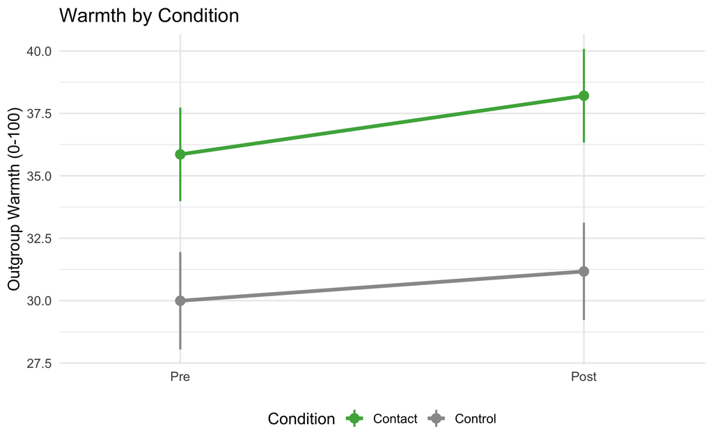

Outgroup warmth (0-100) by condition and time. Points show estimated marginal means ± SE.

```r
emm_warm_tbl <- as_tibble(emm_warm_by_cond) %>%
  mutate(time = factor(time, levels = c("pre", "post")))

p_warm <- ggplot(emm_warm_tbl,
                 aes(x = time, y = emmean, group = treatment, color = treatment)) +
  geom_line(linewidth = 1.4) +
  geom_pointrange(aes(ymin = emmean - SE, ymax = emmean + SE), size = 0.6, linewidth = 0.8) +
  scale_color_manual(values = condition_colors, name = "Condition") +
  scale_x_discrete(labels = c("Pre", "Post"), expand = expansion(add = 0.3)) +
  labs(y = "Outgroup Warmth (0-100)", x = NULL, title = "Warmth by Condition") +
  theme_minimal(base_size = 13) +
  theme(legend.position = "bottom")

p_warm
```

```r
ggsave(paste0(fig_path, "warmth_by_condition.png"), p_warm, width = 8, height = 5, dpi = 300)
```

### Confidence

```r
confidence_long <- dat %>%
  select(ResponseId, treatment, learner_party, confidence_outgroup_pre, confidence_outgroup_post) %>%
  pivot_longer(c(confidence_outgroup_pre, confidence_outgroup_post),
               names_to = "time", names_pattern = "confidence_outgroup_(pre|post)",
               values_to = "confidence") %>%
  mutate(time = factor(time, levels = c("pre", "post")))

m_conf <- lmer(confidence ~ time * treatment + (1 | ResponseId), data = confidence_long)

emm_conf_by_cond <- emmeans(m_conf, ~ time | treatment)
conf_contrasts <- contrast(emm_conf_by_cond, "revpairwise", by = "treatment") %>%
  as_tibble()

emm_conf_full <- emmeans(m_conf, ~ time * treatment)

if (pool_controls) {
  conf_did <- contrast(emm_conf_full, list(
    `Contact vs. Control` = c(1, -1, -1, 1)
  ))
  conf_did_tbl <- conf_did %>% as_tibble() %>% mutate(estimate = -estimate)
  conf_main_b  <- pull_did(conf_did_tbl, "Contact vs. Control", estimate)
  conf_main_se <- pull_did(conf_did_tbl, "Contact vs. Control", SE)
  conf_main_p  <- pull_did(conf_did_tbl, "Contact vs. Control", p.value)
  conf_chat_vs_contact_b <- NA_real_; conf_chat_vs_contact_p <- NA_real_
  conf_game_vs_contact_b <- NA_real_; conf_game_vs_contact_p <- NA_real_
  conf_chat_vs_game_b    <- NA_real_; conf_chat_vs_game_p    <- NA_real_
} else {
  conf_did <- contrast(emm_conf_full, list(
    `Contact vs. pooled controls` = c(-1,  1,  0.5, -0.5,  0.5, -0.5),
    `Chat vs. Contact`            = c( 1, -1, -1,    1,    0,    0  ),
    `Game vs. Contact`            = c( 1, -1,  0,    0,   -1,    1  ),
    `Chat vs. Game`               = c( 0,  0, -1,    1,    1,   -1  )
  ))
  conf_did_tbl           <- conf_did %>% as_tibble()
  conf_main_b            <- pull_did(conf_did_tbl, "Contact vs. pooled controls", estimate)
  conf_main_se           <- pull_did(conf_did_tbl, "Contact vs. pooled controls", SE)
  conf_main_p            <- pull_did(conf_did_tbl, "Contact vs. pooled controls", p.value)
  conf_chat_vs_contact_b <- pull_did(conf_did_tbl, "Chat vs. Contact", estimate)
  conf_chat_vs_contact_p <- pull_did(conf_did_tbl, "Chat vs. Contact", p.value)
  conf_game_vs_contact_b <- pull_did(conf_did_tbl, "Game vs. Contact", estimate)
  conf_game_vs_contact_p <- pull_did(conf_did_tbl, "Game vs. Contact", p.value)
  conf_chat_vs_game_b    <- pull_did(conf_did_tbl, "Chat vs. Game",    estimate)
  conf_chat_vs_game_p    <- pull_did(conf_did_tbl, "Chat vs. Game",    p.value)
}
```

```r
conf_contrasts %>%
  select(Condition = treatment,
         `Pre→Post Change` = estimate,
         SE, df, `t-ratio` = t.ratio, `p-value` = p.value) %>%
  mutate(
    `Pre→Post Change` = numformat(`Pre→Post Change`),
    SE = numformat(SE),
    df = numformat(df, 0),
    `t-ratio` = numformat(`t-ratio`),
    `p-value` = map_chr(`p-value`, pformat)
  ) %>%
  gt() %>%
  tab_header(title = "Confidence: Pre-Post Change by Condition") %>%
  tab_footnote("Positive = increase in confidence. Estimated from mixed-effects model.",
               locations = cells_title())
```

Confidence: Pre-Post Change by Condition<sup>1</sup>

| Condition | Pre→Post Change | SE | df | t-ratio | p-value |
| --- | --- | --- | --- | --- | --- |
| Contact | 0.39 | 0.07 | 379 | 5.21 | < .001 |
| Control | 0.14 | 0.08 | 379 | 1.76 | = 0.079 |

<sup>1</sup> Positive = increase in confidence. Estimated from mixed-effects model.

**Primary test:** Contact vs. Control: *b* = 0.25, SE = 0.11, *p* = 0.020.

## Behavioral Outcomes by Condition

### Dictator Game Donation

```r
dat <- dat %>% mutate(donated_any = as.integer(donation > 0))

don_by_condition <- dat %>%
  group_by(treatment) %>%
  summarise(
    N          = n(),
    M          = mean(donation, na.rm = TRUE),
    SD         = sd(donation, na.rm = TRUE),
    SE         = SD / sqrt(N),
    pct_donated = mean(donated_any) * 100,
    mean_pos   = mean(donation[donation > 0], na.rm = TRUE),
    .groups = "drop"
  )

# Continuous donation: overall ANOVA + Tukey pairwise
don_aov <- aov(donation ~ treatment, data = dat)
don_aov_p <- summary(don_aov)[[1]][["Pr(>F)"]][1]
don_aov_f <- summary(don_aov)[[1]][["F value"]][1]
don_pairwise <- dat %>% tukey_hsd(donation ~ treatment)

extract_tukey <- function(tbl, g1, g2) {
  tbl %>% filter(group1 == g1, group2 == g2)
}

# Stage 1 (any donation): overall ANOVA + Tukey pairwise
don_aov_bin <- aov(donated_any ~ treatment, data = dat)
don_aov_bin_p <- summary(don_aov_bin)[[1]][["Pr(>F)"]][1]
don_aov_bin_f <- summary(don_aov_bin)[[1]][["F value"]][1]
don_pairwise_bin <- dat %>% tukey_hsd(donated_any ~ treatment)

# Stage 2 (amount among donors): ANOVA
dat_donors <- dat %>% filter(donated_any == 1)
don_aov_pos <- aov(donation ~ treatment, data = dat_donors)
don_aov_pos_p <- summary(don_aov_pos)[[1]][["Pr(>F)"]][1]
don_aov_pos_f <- summary(don_aov_pos)[[1]][["F value"]][1]

# Condition-specific pairwise (only meaningful when 3 conditions)
if (!pool_controls) {
  don_cont_chat_game     <- extract_tukey(don_pairwise,     "Chat", "Game")
  don_bin_contact_chat_p <- extract_tukey(don_pairwise_bin, "Contact", "Chat")$p.adj
  don_bin_contact_game_p <- extract_tukey(don_pairwise_bin, "Contact", "Game")$p.adj
  don_bin_chat_game_p    <- extract_tukey(don_pairwise_bin, "Chat",    "Game")$p.adj
} else {
  don_cont_chat_game     <- tibble(p.adj = NA_real_)
  don_bin_contact_chat_p <- NA_real_
  don_bin_contact_game_p <- extract_tukey(don_pairwise_bin, "Contact", "Control")$p.adj
  don_bin_chat_game_p    <- NA_real_
}
```

```r
don_by_condition %>%
  mutate(across(c(M, SD, SE, mean_pos), numformat),
         pct_donated = numformat(pct_donated, 0)) %>%
  select(Condition = treatment, N,
         `% Donated` = pct_donated,
         `Mean (all)` = M, SD,
         `Mean (donors only)` = mean_pos) %>%
  gt() %>%
  tab_header(title = "Dictator Game: Donation by Condition") %>%
  tab_footnote("% Donated = proportion who gave any amount > 0. Mean (donors only) excludes zeros.",
               locations = cells_title())
```

Dictator Game: Donation by Condition<sup>1</sup>

| Condition | N | % Donated | Mean (all) | SD | Mean (donors only) |
| --- | --- | --- | --- | --- | --- |
| Contact | 198 | 56 | 20.13 | 21.40 | 36.23 |
| Control | 183 | 55 | 20.17 | 21.68 | 36.92 |

<sup>1</sup> % Donated = proportion who gave any amount > 0. Mean (donors only) excludes zeros.

```r
bind_rows(
  don_pairwise %>% select(group1, group2, estimate, p.adj) %>% mutate(DV = "Continuous (0-50¢)"),
  don_pairwise_bin %>% select(group1, group2, estimate, p.adj) %>% mutate(DV = "Any donation (0/1)")
) %>%
  mutate(
    Comparison = paste0(group1, " vs. ", group2),
    estimate = numformat(estimate),
    p.adj = map_chr(p.adj, pformat)
  ) %>%
  select(DV, Comparison, `Difference` = estimate, `p (Tukey)` = p.adj) %>%
  gt() %>%
  tab_header(title = "Pairwise Tukey Comparisons: Donation") %>%
  tab_footnote("Tukey-corrected p-values.", locations = cells_title())
```

Pairwise Tukey Comparisons: Donation<sup>1</sup>

| DV | Comparison | Difference | p (Tukey) |
| --- | --- | --- | --- |
| Continuous (0-50¢) | Contact vs. Control | 0.05 | = 0.982 |
| Any donation (0/1) | Contact vs. Control | -0.01 | = 0.859 |

<sup>1</sup> Tukey-corrected p-values.

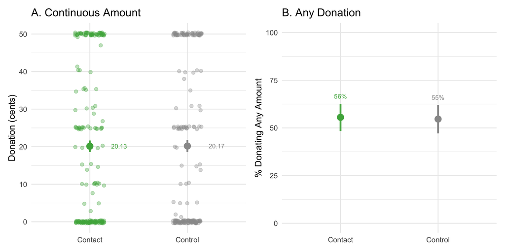

Left: Dictator game donation (0-50 cents) by condition — individual points, mean ± SE. Right: Proportion donating any amount.

```r
p_don_cont <- ggplot(dat, aes(x = treatment, y = donation, color = treatment)) +
  geom_jitter(width = 0.15, alpha = 0.35, size = 2) +
  geom_pointrange(data = don_by_condition,
                  aes(x = treatment, y = M, ymin = M - SE, ymax = M + SE),
                  size = 0.8, linewidth = 1.2, inherit.aes = FALSE,
                  color = condition_colors[as.character(don_by_condition$treatment)]) +
  geom_text(data = don_by_condition,
            aes(x = treatment, y = M, label = numformat(M)),
            nudge_x = 0.3, size = 3.2, show.legend = FALSE,
            color = condition_colors[as.character(don_by_condition$treatment)]) +
  scale_color_manual(values = condition_colors) +
  labs(y = "Donation (cents)", x = NULL, title = "A. Continuous Amount") +
  theme_minimal(base_size = 13) +
  theme(legend.position = "none")

# % donated panel with 95% CI
don_bin_ci <- don_by_condition %>%
  mutate(
    n_donated = round(pct_donated / 100 * N),
    ci_lo = map2_dbl(n_donated, N, ~ binom.test(.x, .y)$conf.int[1] * 100),
    ci_hi = map2_dbl(n_donated, N, ~ binom.test(.x, .y)$conf.int[2] * 100)
  )

p_don_bin <- ggplot(don_bin_ci, aes(x = treatment, y = pct_donated, color = treatment)) +
  geom_pointrange(aes(ymin = ci_lo, ymax = ci_hi), size = 0.8, linewidth = 1.2) +
  geom_text(aes(y = ci_hi + 4, label = paste0(round(pct_donated), "%")),
            size = 3.2, show.legend = FALSE) +
  scale_color_manual(values = condition_colors) +
  scale_y_continuous(limits = c(0, 100), breaks = seq(0, 100, 25)) +
  labs(y = "% Donating Any Amount", x = NULL, title = "B. Any Donation") +
  theme_minimal(base_size = 13) +
  theme(legend.position = "none")

p_don <- p_don_cont + p_don_bin
p_don
```

```r
ggsave(paste0(fig_path, "donation_by_condition.png"), p_don, width = 10, height = 5, dpi = 300)
```

### Talk Partner Preference

```r
dat <- dat %>%
  mutate(
    chose_outgroup = case_when(
      participant_party == "Democrat"   & talk_partner == "I'd rather talk with a republican" ~ 1,
      participant_party == "Republican" & talk_partner == "I'd rather talk with a democrat"   ~ 1,
      TRUE ~ 0
    )
  )

talk_by_condition <- dat %>%
  group_by(treatment) %>%
  summarise(
    n_total      = n(),
    n_outgroup   = sum(chose_outgroup, na.rm = TRUE),
    pct_outgroup = n_outgroup / n_total * 100,
    ci_lo = binom.test(n_outgroup, n_total)$conf.int[1] * 100,
    ci_hi = binom.test(n_outgroup, n_total)$conf.int[2] * 100,
    .groups = "drop"
  )

# Overall chi-square
talk_tab <- table(dat$treatment, dat$chose_outgroup)
talk_chisq <- chisq.test(talk_tab)

# Pairwise Fisher's exact tests (only when 3 conditions exist)
if (!pool_controls) {
  fish_contact_chat <- fisher.test(talk_tab[c("Contact", "Chat"), ])
  fish_contact_game <- fisher.test(talk_tab[c("Contact", "Game"), ])
  fish_chat_game    <- fisher.test(talk_tab[c("Chat",    "Game"), ])
} else {
  fish_contact_chat <- list(p.value = NA_real_, estimate = NA_real_)
  fish_contact_game <- fisher.test(talk_tab[c("Contact", "Control"), ])
  fish_chat_game    <- list(p.value = NA_real_, estimate = NA_real_)
}
```

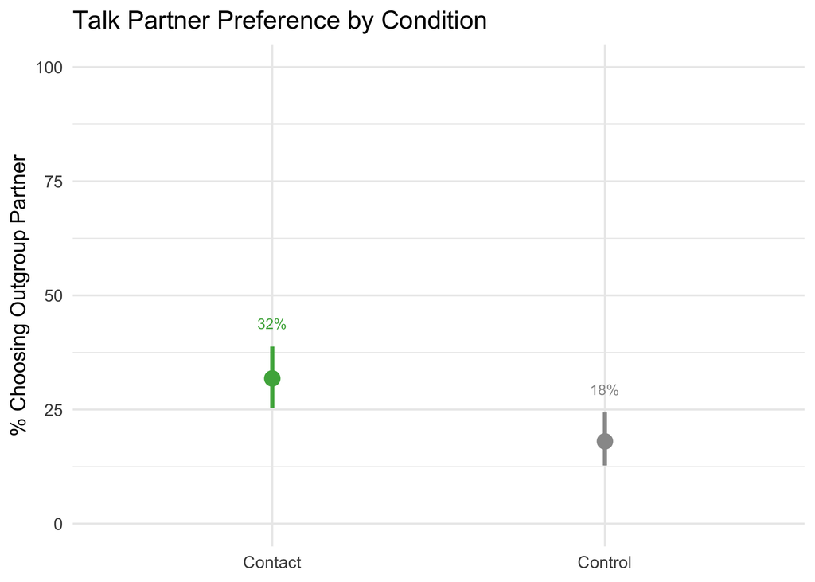

Proportion choosing to talk with an outgroup member by condition. Error bars show 95% CI.

```r
p_talk <- ggplot(talk_by_condition,
                 aes(x = treatment, y = pct_outgroup, color = treatment)) +
  geom_pointrange(aes(ymin = ci_lo, ymax = ci_hi), size = 0.8, linewidth = 1.2) +
  geom_text(aes(y = ci_hi + 5, label = paste0(round(pct_outgroup), "%")),
            size = 3.2, show.legend = FALSE) +
  scale_color_manual(values = condition_colors) +
  scale_y_continuous(limits = c(0, 100), breaks = seq(0, 100, 25)) +
  labs(y = "% Choosing Outgroup Partner", x = NULL,
       title = "Talk Partner Preference by Condition") +
  theme_minimal(base_size = 13) +
  theme(legend.position = "none")

p_talk
```

```r
ggsave(paste0(fig_path, "talk_partner_by_condition.png"), p_talk, width = 7, height = 5, dpi = 300)
```

The overall chi-square test for condition differences in outgroup partner preference: *χ²* = 8.87, *p* = 0.003. Contact vs. Control: OR = 0.47, *p* = 0.002.

## Combined Improvement Figure

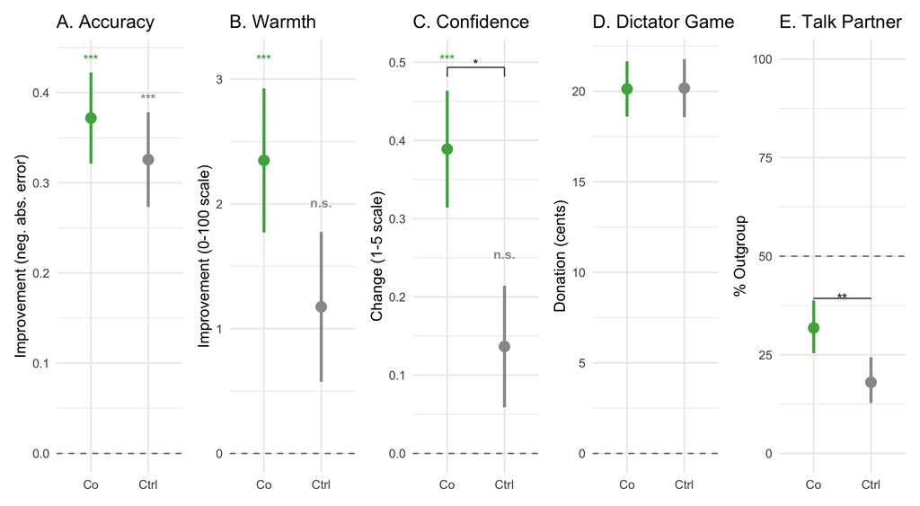

Pre-post improvement by condition across all outcomes. Error bars show ± SE. Stars above points indicate within-condition improvement vs. zero. Brackets show between-condition DiD contrasts (lmer) for pre-post outcomes; Tukey HSD for donation and Fisher exact for talk partner.

```r
# Abbreviated x-axis labels
x_labels <- if (pool_controls) {
  c("Contact" = "Co", "Control" = "Ctrl")
} else {
  c("Contact" = "Co", "Chat" = "Ch", "Game" = "Ga")
}

# Between-condition pairwise p-values from DiD contrasts
# Returns a tibble: group1, group2, p (numeric positions 1/2/3 on x-axis)
pairwise_did <- function(did_tbl) {
  if (pool_controls) {
    tibble(
      x1 = 1, x2 = 2,
      p  = pull_did(did_tbl, "Contact vs. Control", p.value)
    )
  } else {
    tibble(
      x1 = c(1, 1, 2),
      x2 = c(2, 3, 3),
      p  = c(
        pull_did(did_tbl, "Chat vs. Contact", p.value),
        pull_did(did_tbl, "Game vs. Contact", p.value),
        pull_did(did_tbl, "Chat vs. Game",    p.value)
      )
    )
  }
}

# Add significance brackets as annotation layers
# yrange: the observed (ymin, ymax) range of the pointranges
add_brackets <- function(pairs, ymax_data, y_scale = 1) {
  sig <- pairs %>% filter(p < .05) %>% mutate(stars = p_to_stars(p))
  if (nrow(sig) == 0) return(list())
  # Stack brackets above data
  bracket_gap  <- diff(range(ymax_data)) * 0.12 * y_scale
  bracket_step <- diff(range(ymax_data)) * 0.18 * y_scale
  top0 <- max(ymax_data) + bracket_gap
  layers <- list()
  for (i in seq_len(nrow(sig))) {
    row  <- sig[i, ]
    ytop <- top0 + (i - 1) * bracket_step
    # horizontal bar
    layers <- c(layers, list(
      annotate("segment", x = row$x1, xend = row$x2, y = ytop, yend = ytop,
               color = "gray30", linewidth = 0.5),
      # left tick
      annotate("segment", x = row$x1, xend = row$x1,
               y = ytop - bracket_gap * 0.4, yend = ytop,
               color = "gray30", linewidth = 0.5),
      # right tick
      annotate("segment", x = row$x2, xend = row$x2,
               y = ytop - bracket_gap * 0.4, yend = ytop,
               color = "gray30", linewidth = 0.5),
      # stars
      annotate("text", x = (row$x1 + row$x2) / 2, y = ytop + bracket_gap * 0.15,
               label = row$stars, size = 3.5, fontface = "bold", color = "gray20")
    ))
  }
  layers
}

# Base panel builder: within-condition dots + within-condition stars near point
make_panel <- function(contrasts_tbl, title, y_lab, pairs = NULL, y_scale = 1) {
  d <- contrasts_tbl %>%
    mutate(stars = p_to_stars(p.value), ymin = estimate - SE, ymax = estimate + SE)

  p <- d %>%
    ggplot(aes(x = treatment, y = estimate, color = treatment)) +
    geom_hline(yintercept = 0, linetype = "dashed", color = "gray50") +
    geom_pointrange(aes(ymin = ymin, ymax = ymax), size = 0.7, linewidth = 1.1) +
    geom_text(aes(y = ymax + diff(range(c(ymin, ymax))) * 0.10,
                  label = stars),
              size = 3.5, fontface = "bold", show.legend = FALSE) +
    scale_color_manual(values = condition_colors) +
    scale_x_discrete(labels = x_labels) +
    labs(x = NULL, y = y_lab, title = title) +
    theme_minimal(base_size = 12) +
    theme(legend.position = "none")

  if (!is.null(pairs)) {
    brks <- add_brackets(pairs, d$ymax, y_scale)
    for (lyr in brks) p <- p + lyr
  }
  p
}

acc_pairs  <- pairwise_did(acc_did_tbl)
warm_pairs <- pairwise_did(warm_did_tbl)
conf_pairs <- pairwise_did(conf_did_tbl)

pa <- make_panel(acc_contrasts,  "A. Accuracy",   "Improvement (neg. abs. error)", acc_pairs)
pb <- make_panel(warm_contrasts, "B. Warmth",     "Improvement (0-100 scale)",     warm_pairs)
pc <- make_panel(conf_contrasts, "C. Confidence", "Change (1-5 scale)",            conf_pairs)

# Donation panel: Tukey pairwise between conditions
don_pairs <- if (pool_controls) {
  tibble(x1 = 1, x2 = 2,
         p  = extract_tukey(don_pairwise, "Contact", "Control")$p.adj)
} else {
  tibble(
    x1 = c(1, 1, 2),
    x2 = c(2, 3, 3),
    p  = c(
      extract_tukey(don_pairwise, "Contact", "Chat")$p.adj,
      extract_tukey(don_pairwise, "Contact", "Game")$p.adj,
      extract_tukey(don_pairwise, "Chat",    "Game")$p.adj
    )
  )
}

don_d <- don_by_condition %>% mutate(ymin = M - SE, ymax = M + SE)
pd <- ggplot(don_d, aes(x = treatment, y = M, color = treatment)) +
  geom_hline(yintercept = 0, linetype = "dashed", color = "gray50") +
  geom_pointrange(aes(ymin = ymin, ymax = ymax), size = 0.7, linewidth = 1.1) +
  scale_color_manual(values = condition_colors) +
  scale_x_discrete(labels = x_labels) +
  labs(x = NULL, y = "Donation (cents)", title = "D. Dictator Game") +
  theme_minimal(base_size = 12) +
  theme(legend.position = "none")
for (lyr in add_brackets(don_pairs, don_d$ymax)) pd <- pd + lyr

# Talk partner panel: Fisher exact pairwise
talk_pairs <- if (pool_controls) {
  tibble(x1 = 1, x2 = 2, p = fish_contact_game$p.value)
} else {
  tibble(
    x1 = c(1, 1, 2),
    x2 = c(2, 3, 3),
    p  = c(fish_contact_chat$p.value, fish_contact_game$p.value, fish_chat_game$p.value)
  )
}

talk_d <- talk_by_condition %>% mutate(ymin = ci_lo, ymax = ci_hi)
pe <- ggplot(talk_d, aes(x = treatment, y = pct_outgroup, color = treatment)) +
  geom_hline(yintercept = 50, linetype = "dashed", color = "gray50") +
  geom_pointrange(aes(ymin = ymin, ymax = ymax), size = 0.7, linewidth = 1.1) +
  scale_color_manual(values = condition_colors) +
  scale_x_discrete(labels = x_labels) +
  scale_y_continuous(limits = c(0, 100)) +
  labs(x = NULL, y = "% Outgroup", title = "E. Talk Partner") +
  theme_minimal(base_size = 12) +
  theme(legend.position = "none")
for (lyr in add_brackets(talk_pairs, talk_d$ymax, y_scale = 0.3)) pe <- pe + lyr

p_combined <- pa + pb + pc + pd + pe + plot_layout(ncol = 5)
ggsave(paste0(fig_path, "combined_by_condition.png"), p_combined, width = 14, height = 5.5, dpi = 300)
p_combined
```

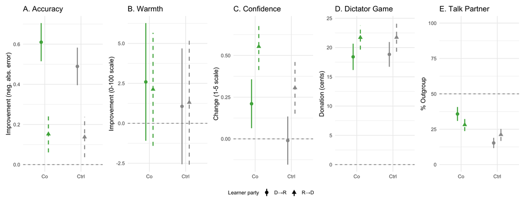

Pre-post improvement by condition and learner party (D→R = Democrats learning about Republicans; R→D = Republicans learning about Democrats). Points are offset by party; linetype distinguishes parties. Error bars show ± SE.

```r
# ── Fit 3-way models for each DV ──────────────────────────────────────────────
m_acc_3way_cf  <- lmer(accuracy    ~ time * treatment * learner_party + (1 | ResponseId),
                        data = accuracy_long, REML = FALSE)
m_warm_3way_cf <- lmer(warmth      ~ time * treatment * learner_party + (1 | ResponseId),
                        data = warmth_long,   REML = FALSE)
m_conf_3way_cf <- lmer(confidence  ~ time * treatment * learner_party + (1 | ResponseId),
                        data = confidence_long, REML = FALSE)

# ── Extract DiD by party: post - pre emmean per condition × party ─────────────
party_did <- function(model, dv_label, y_label) {
  emm <- emmeans(model, ~ time | treatment * learner_party) %>%
    as_tibble() %>%
    select(treatment, learner_party, time, emmean, SE)

  did <- emm %>%
    pivot_wider(names_from = time, values_from = c(emmean, SE),
                id_cols = c(treatment, learner_party)) %>%
    mutate(
      estimate = emmean_post - emmean_pre,
      SE       = sqrt(SE_pre^2 + SE_post^2),
      ymin     = estimate - SE,
      ymax     = estimate + SE
    )

  dodge <- position_dodge(width = 0.4)

  ggplot(did, aes(x = treatment, y = estimate,
                  color = treatment, linetype = learner_party,
                  shape = learner_party, group = learner_party)) +
    geom_hline(yintercept = 0, linetype = "dashed", color = "gray50") +
    geom_pointrange(aes(ymin = ymin, ymax = ymax),
                    size = 0.6, linewidth = 0.9,
                    position = dodge) +
    scale_color_manual(values = condition_colors) +
    scale_linetype_manual(values = c("D→R" = "solid", "R→D" = "dashed"),
                          name = "Learner party") +
    scale_shape_manual(values = c("D→R" = 16, "R→D" = 17),
                       name = "Learner party") +
    scale_x_discrete(labels = x_labels) +
    guides(color = "none") +
    labs(x = NULL, y = y_label, title = dv_label) +
    theme_minimal(base_size = 12) +
    theme(legend.position = "bottom",
          legend.title = element_text(size = 10))
}

pa_p <- party_did(m_acc_3way_cf,  "A. Accuracy",   "Improvement (neg. abs. error)")
pb_p <- party_did(m_warm_3way_cf, "B. Warmth",     "Improvement (0-100 scale)")
pc_p <- party_did(m_conf_3way_cf, "C. Confidence", "Change (1-5 scale)")

# ── Donation by party: use raw means (no lmer for binary-ish DV) ────────────
don_party <- dat %>%
  group_by(treatment, learner_party) %>%
  summarise(M  = mean(donation, na.rm = TRUE),
            SE = sd(donation,   na.rm = TRUE) / sqrt(n()),
            .groups = "drop") %>%
  mutate(ymin = M - SE, ymax = M + SE)

dodge <- position_dodge(width = 0.4)

pd_p <- ggplot(don_party, aes(x = treatment, y = M,
                               color = treatment, linetype = learner_party,
                               shape = learner_party, group = learner_party)) +
  geom_hline(yintercept = 0, linetype = "dashed", color = "gray50") +
  geom_pointrange(aes(ymin = ymin, ymax = ymax),
                  size = 0.6, linewidth = 0.9,
                  position = dodge) +
  scale_color_manual(values = condition_colors) +
  scale_linetype_manual(values = c("D→R" = "solid", "R→D" = "dashed"),
                        name = "Learner party") +
  scale_shape_manual(values = c("D→R" = 16, "R→D" = 17),
                     name = "Learner party") +
  scale_x_discrete(labels = x_labels) +
  guides(color = "none") +
  labs(x = NULL, y = "Donation (cents)", title = "D. Dictator Game") +
  theme_minimal(base_size = 12) +
  theme(legend.position = "bottom",
        legend.title = element_text(size = 10))

# ── Talk partner by party ────────────────────────────────────────────────────
talk_party <- dat %>%
  group_by(treatment, learner_party) %>%
  summarise(
    n_out = sum(chose_outgroup == 1, na.rm = TRUE),
    n     = sum(!is.na(chose_outgroup)),
    .groups = "drop"
  ) %>%
  mutate(
    pct_outgroup = 100 * n_out / n,
    SE           = 100 * sqrt(pct_outgroup/100 * (1 - pct_outgroup/100) / n),
    ymin         = pmax(0,   pct_outgroup - SE),
    ymax         = pmin(100, pct_outgroup + SE)
  )

pe_p <- ggplot(talk_party, aes(x = treatment, y = pct_outgroup,
                                color = treatment, linetype = learner_party,
                                shape = learner_party, group = learner_party)) +
  geom_hline(yintercept = 50, linetype = "dashed", color = "gray50") +
  geom_pointrange(aes(ymin = ymin, ymax = ymax),
                  size = 0.6, linewidth = 0.9,
                  position = dodge) +
  scale_color_manual(values = condition_colors) +
  scale_linetype_manual(values = c("D→R" = "solid", "R→D" = "dashed"),
                        name = "Learner party") +
  scale_shape_manual(values = c("D→R" = 16, "R→D" = 17),
                     name = "Learner party") +
  scale_x_discrete(labels = x_labels) +
  scale_y_continuous(limits = c(0, 100)) +
  guides(color = "none") +
  labs(x = NULL, y = "% Outgroup", title = "E. Talk Partner") +
  theme_minimal(base_size = 12) +
  theme(legend.position = "bottom",
        legend.title = element_text(size = 10))

p_combined_party <- pa_p + pb_p + pc_p + pd_p + pe_p +
  plot_layout(ncol = 5, guides = "collect") &
  theme(legend.position = "bottom")

ggsave(paste0(fig_path, "combined_by_condition_party.png"),
       p_combined_party, width = 14, height = 6, dpi = 300)
p_combined_party
```

## Moderating Role of Party

We also check whether the condition effects are moderated by learner party (D→R vs R→D).

```r
# 3-way: time × treatment × party
accuracy_long_party <- accuracy_long

m_acc_3way <- lmer(accuracy ~ time * treatment * learner_party + (1 | ResponseId),
                   data = accuracy_long_party, REML = FALSE)
m_acc_2way <- lmer(accuracy ~ time * treatment + time * learner_party +
                     treatment * learner_party + (1 | ResponseId),
                   data = accuracy_long_party, REML = FALSE)

lrt_acc <- anova(m_acc_2way, m_acc_3way)
lrt_acc_p <- lrt_acc$`Pr(>Chisq)`[2]

# Warmth 3-way
warmth_long_party <- warmth_long
m_warm_3way <- lmer(warmth ~ time * treatment * learner_party + (1 | ResponseId),
                    data = warmth_long_party, REML = FALSE)
m_warm_2way <- lmer(warmth ~ time * treatment + time * learner_party +
                      treatment * learner_party + (1 | ResponseId),
                    data = warmth_long_party, REML = FALSE)
lrt_warm <- anova(m_warm_2way, m_warm_3way)
lrt_warm_p <- lrt_warm$`Pr(>Chisq)`[2]
```

A likelihood ratio test found that party did not significantly moderate the condition × time interaction for accuracy (*p* = 0.448) and did not significantly moderate it for warmth (*p* = 0.671).

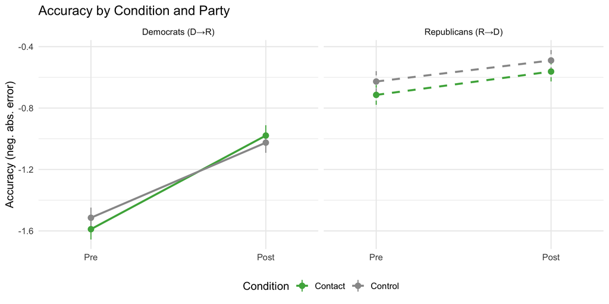

Estimated marginal means for accuracy by condition and learner party.

```r
emm_acc_party <- emmeans(m_acc_3way, ~ time | treatment * learner_party) %>%
  as_tibble() %>%
  mutate(time = factor(time, levels = c("pre", "post")))

ggplot(emm_acc_party,
       aes(x = time, y = emmean, group = interaction(treatment, learner_party),
           color = treatment, linetype = learner_party)) +
  geom_line(linewidth = 1.1) +
  geom_pointrange(aes(ymin = emmean - SE, ymax = emmean + SE), size = 0.5) +
  facet_wrap(~ learner_party, labeller = labeller(learner_party = c("D→R" = "Democrats (D→R)", "R→D" = "Republicans (R→D)"))) +
  scale_color_manual(values = condition_colors, name = "Condition") +
  scale_linetype_manual(values = c("D→R" = "solid", "R→D" = "dashed"), guide = "none") +
  scale_x_discrete(labels = c("Pre", "Post"), expand = expansion(add = 0.3)) +
  labs(y = "Accuracy (neg. abs. error)", x = NULL,
       title = "Accuracy by Condition and Party") +
  theme_minimal(base_size = 13) +
  theme(legend.position = "bottom")
```

```r
ggsave(paste0(fig_path, "accuracy_condition_party.png"), width = 10, height = 5, dpi = 300)
```

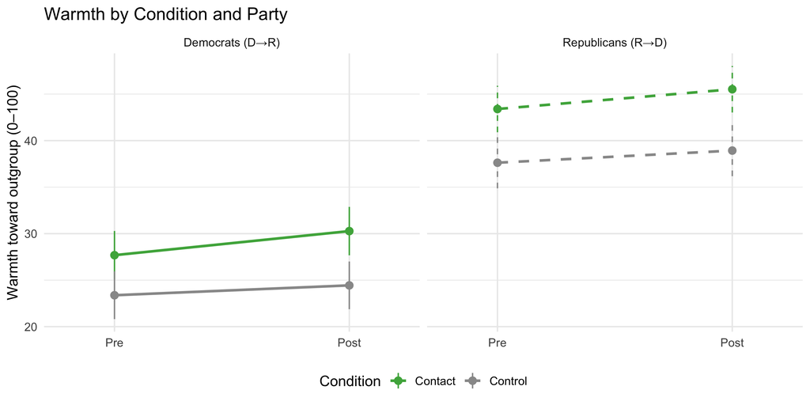

Estimated marginal means for warmth by condition and learner party.

```r
emm_warm_party <- emmeans(m_warm_3way, ~ time | treatment * learner_party) %>%
  as_tibble() %>%
  mutate(time = factor(time, levels = c("pre", "post")))

ggplot(emm_warm_party,
       aes(x = time, y = emmean, group = interaction(treatment, learner_party),
           color = treatment, linetype = learner_party)) +
  geom_line(linewidth = 1.1) +
  geom_pointrange(aes(ymin = emmean - SE, ymax = emmean + SE), size = 0.5) +
  facet_wrap(~ learner_party, labeller = labeller(learner_party = c("D→R" = "Democrats (D→R)", "R→D" = "Republicans (R→D)"))) +
  scale_color_manual(values = condition_colors, name = "Condition") +
  scale_linetype_manual(values = c("D→R" = "solid", "R→D" = "dashed"), guide = "none") +
  scale_x_discrete(labels = c("Pre", "Post"), expand = expansion(add = 0.3)) +
  labs(y = "Warmth toward outgroup (0–100)", x = NULL,
       title = "Warmth by Condition and Party") +
  theme_minimal(base_size = 13) +
  theme(legend.position = "bottom")
```

```r
ggsave(paste0(fig_path, "warmth_condition_party.png"), width = 10, height = 5, dpi = 300)
```

## Summary Table

```r
# Compute condition-level summaries for key DVs
summary_rows <- bind_rows(
  # Accuracy
  dat %>% group_by(treatment) %>%
    summarise(DV = "Accuracy",
              Pre = mean(accuracy_pre, na.rm=TRUE) %>% numformat(),
              Post = mean(accuracy_post, na.rm=TRUE) %>% numformat(),
              Change = mean(accuracy_post - accuracy_pre, na.rm=TRUE) %>% numformat(),
              .groups="drop"),
  # Warmth
  dat %>% group_by(treatment) %>%
    summarise(DV = "Outgroup Warmth",
              Pre = mean(warmth_outgroup_pre, na.rm=TRUE) %>% numformat(),
              Post = mean(warmth_outgroup_post, na.rm=TRUE) %>% numformat(),
              Change = mean(warmth_outgroup_post - warmth_outgroup_pre, na.rm=TRUE) %>% numformat(),
              .groups="drop"),
  # Confidence
  dat %>% group_by(treatment) %>%
    summarise(DV = "Confidence",
              Pre = mean(confidence_outgroup_pre, na.rm=TRUE) %>% numformat(),
              Post = mean(confidence_outgroup_post, na.rm=TRUE) %>% numformat(),
              Change = mean(confidence_outgroup_post - confidence_outgroup_pre, na.rm=TRUE) %>% numformat(),
              .groups="drop")
) %>%
  select(DV, Condition = treatment, Pre, Post, Change)

summary_rows %>%
  gt(groupname_col = "DV") %>%
  tab_header(title = "Pre-Post Changes by Condition and DV") %>%
  tab_footnote("Change = Post − Pre. Positive = improvement/increase.",
               locations = cells_title())
```

Pre-post changes by condition across all dependent variables.

Pre-Post Changes by Condition and DV<sup>1</sup>

| Condition | Pre | Post | Change |
| --- | --- | --- | --- |
| Accuracy |  |  |  |
| Contact | -1.13 | -0.76 | 0.37 |
| Control | -1.10 | -0.78 | 0.33 |
| Outgroup Warmth |  |  |  |
| Contact | 35.86 | 38.21 | 2.35 |
| Control | 29.99 | 31.17 | 1.17 |
| Confidence |  |  |  |
| Contact | 3.08 | 3.47 | 0.39 |
| Control | 3.16 | 3.30 | 0.14 |

<sup>1</sup> Change = Post − Pre. Positive = improvement/increase.

## Appendix: Simulation — lmer vs. ANCOVA Power and Bias

To understand which model better recovers a known treatment effect, we run a Monte Carlo simulation calibrated to this study’s design. We fix pre-scores to be equal across conditions (randomization holds), give the treatment condition a true post-score advantage, and ask: which model (a) recovers the true effect with less bias, and (b) detects it with higher power?

```r
set.seed(2024)

# Parameters calibrated to observed data
n_trt_sim  <- n_contact   # ~126
n_ctrl_sim <- n_total - n_contact  # non-Contact participants
n_sims     <- 2

# From observed data
pre_mean <- mean(dat$accuracy_pre, na.rm = TRUE)
pre_sd   <- sd(dat$accuracy_pre,  na.rm = TRUE)
post_sd  <- sd(dat$accuracy_post, na.rm = TRUE)

# Use average pre-post correlation across conditions (pooled or per-condition)
if (!pool_controls) {
  # Exclude Chat outlier; average Contact and Game
  rho_sim <- mean(c(
    cor(dat$accuracy_pre[dat$treatment == "Contact"],
        dat$accuracy_post[dat$treatment == "Contact"], use = "complete.obs"),
    cor(dat$accuracy_pre[dat$treatment == "Game"],
        dat$accuracy_post[dat$treatment == "Game"], use = "complete.obs")
  ))
} else {
  rho_sim <- cor(dat$accuracy_pre, dat$accuracy_post, use = "complete.obs")
}

resid_sd <- post_sd * sqrt(1 - rho_sim^2)
b_pre_sim <- rho_sim * (post_sd / pre_sd)

# True effect sizes to sweep
true_effects <- c(0, 0.1, 0.2, 0.3, 0.5)

sim_one <- function(true_delta) {
  # Pre: same in both groups
  pre_trt  <- rnorm(n_trt_sim,  pre_mean, pre_sd)
  pre_ctrl <- rnorm(n_ctrl_sim, pre_mean, pre_sd)

  # Post: true effect in treatment only
  post_trt  <- b_pre_sim * pre_trt  + true_delta + rnorm(n_trt_sim,  0, resid_sd)
  post_ctrl <- b_pre_sim * pre_ctrl +           0 + rnorm(n_ctrl_sim, 0, resid_sd)

  d <- data.frame(
    id        = seq_len(n_trt_sim + n_ctrl_sim),
    treatment = factor(c(rep("Treatment", n_trt_sim), rep("Control", n_ctrl_sim)),
                       levels = c("Control", "Treatment")),
    pre       = c(pre_trt,  pre_ctrl),
    post      = c(post_trt, post_ctrl)
  )

  # ANCOVA — unname() prevents name concatenation in replicate() matrix rownames
  anc     <- lm(post ~ pre + treatment, data = d)
  anc_est <- unname(coef(anc)["treatmentTreatment"])
  anc_p   <- unname(summary(anc)$coefficients["treatmentTreatment", "Pr(>|t|)"])

  # lmer
  d_long <- d %>%
    pivot_longer(c(pre, post), names_to = "time", values_to = "y") %>%
    mutate(time = factor(time, levels = c("pre", "post")))
  suppressMessages(
    m <- lmer(y ~ time * treatment + (1 | id), data = d_long)
  )
  emm      <- emmeans(m, ~ time * treatment)
  ctr      <- contrast(emm, list(did = c(-1, 1, 1, -1)))
  lmer_est <- unname(summary(ctr)$estimate)
  lmer_p   <- unname(summary(ctr)$p.value)

  c(anc_est = anc_est, anc_p = anc_p, lmer_est = lmer_est, lmer_p = lmer_p)
}

sim_results <- map_dfr(true_effects, function(delta) {
  # replicate returns a matrix: rows = named output elements, cols = simulations
  mat <- replicate(n_sims, sim_one(delta))  # dim: 4 x n_sims
  tibble(
    true_delta = delta,
    anc_bias   = mean(mat["anc_est", ])  - delta,
    anc_se     = sd(mat[  "anc_est", ]),
    anc_power  = mean(mat["anc_p",   ] < .05),
    lmer_bias  = mean(mat["lmer_est",]) - delta,
    lmer_se    = sd(mat[  "lmer_est",]),
    lmer_power = mean(mat["lmer_p",  ] < .05)
  )
})
```

```r
sim_results %>%
  mutate(
    across(c(anc_bias, anc_se, lmer_bias, lmer_se), ~ numformat(.x, 3)),
    anc_power  = numformat(anc_power  * 100, 1),
    lmer_power = numformat(lmer_power * 100, 1),
    true_delta = numformat(true_delta, 2)
  ) %>%
  select(
    `True effect` = true_delta,
    `ANCOVA bias` = anc_bias, `ANCOVA SE` = anc_se, `ANCOVA power (%)` = anc_power,
    `lmer bias`   = lmer_bias, `lmer SE`   = lmer_se, `lmer power (%)`   = lmer_power
  ) %>%
  gt() %>%
  tab_header(
    title    = "Simulation: ANCOVA vs. lmer — Bias, Efficiency, and Power",
    subtitle = paste0(
      "N = ", n_trt_sim, " (treatment) + ", n_ctrl_sim, " (control); ",
      "pre-post r ≈ ", numformat(rho_sim), "; ", n_sims, " simulations per effect size"
    )
  ) %>%
  tab_spanner(label = "ANCOVA (lm post ~ pre + condition)",
              columns = c(`ANCOVA bias`, `ANCOVA SE`, `ANCOVA power (%)`)) %>%
  tab_spanner(label = "lmer (time × treatment + random intercept)",
              columns = c(`lmer bias`, `lmer SE`, `lmer power (%)`)) %>%
  tab_footnote(
    "Bias = mean(estimated) − true effect. SE = SD of estimates across simulations (lower = more efficient). Power = % of simulations with p < .05.",
    locations = cells_title()
  )
```

Simulation: ANCOVA vs. lmer — Bias, Efficiency, and Power<sup>1</sup>

N = 208 (treatment) + 193 (control); pre-post r ≈ 0.56; 2 simulations per effect size<sup>1</sup>

| True effect | ANCOVA (lm post ~ pre + condition) ANCOVA bias | ANCOVA (lm post ~ pre + condition) ANCOVA SE | ANCOVA (lm post ~ pre + condition) ANCOVA power (%) | lmer (time × treatment + random intercept) lmer bias | lmer (time × treatment + random intercept) lmer SE | lmer (time × treatment + random intercept) lmer power (%) |
| --- | --- | --- | --- | --- | --- | --- |
| 0.00 | -0.007 | 0.004 | 0.0 | -0.022 | 0.004 | 0.0 |
| 0.10 | 0.025 | 0.012 | 100.0 | -0.211 | 0.082 | 50.0 |
| 0.20 | -0.011 | 0.144 | 50.0 | -0.409 | 0.114 | 50.0 |
| 0.30 | 0.006 | 0.080 | 100.0 | -0.592 | 0.020 | 100.0 |
| 0.50 | -0.040 | 0.003 | 100.0 | -0.887 | 0.014 | 100.0 |

<sup>1</sup> Bias = mean(estimated) − true effect. SE = SD of estimates across simulations (lower = more efficient). Power = % of simulations with p < .05.

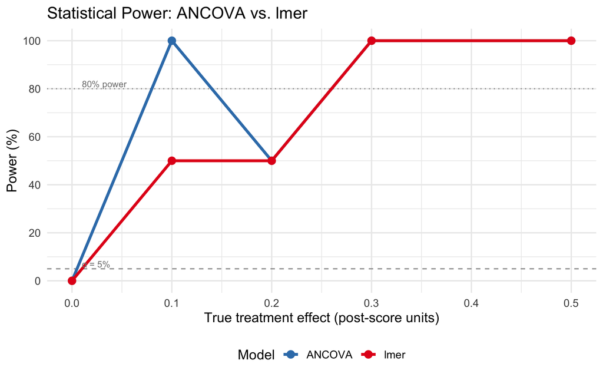

```r
sim_results %>%
  select(true_delta, anc_power, lmer_power) %>%
  pivot_longer(c(anc_power, lmer_power), names_to = "model", values_to = "power") %>%
  mutate(model = recode(model, "anc_power" = "ANCOVA", "lmer_power" = "lmer")) %>%
  ggplot(aes(x = true_delta, y = power * 100, color = model, group = model)) +
  geom_hline(yintercept = 5,  linetype = "dashed", color = "gray60", linewidth = 0.5) +
  geom_hline(yintercept = 80, linetype = "dotted", color = "gray60", linewidth = 0.5) +
  geom_line(linewidth = 1.3) +
  geom_point(size = 3) +
  annotate("text", x = 0.01, y = 7,  label = "α = 5%",    size = 3, color = "gray50", hjust = 0) +
  annotate("text", x = 0.01, y = 82, label = "80% power", size = 3, color = "gray50", hjust = 0) +
  scale_color_manual(values = c("ANCOVA" = "#377EB8", "lmer" = "#E41A1C"), name = "Model") +
  scale_y_continuous(limits = c(0, 100), breaks = seq(0, 100, 20)) +
  labs(
    x = "True treatment effect (post-score units)",
    y = "Power (%)",
    title = "Statistical Power: ANCOVA vs. lmer"
  ) +
  theme_minimal(base_size = 13) +
  theme(legend.position = "bottom")
```

```r
ggsave(paste0(fig_path, "simulation_power.png"), width = 8, height = 5, dpi = 300)
```

# Appendix: Outlier Robustness

How sensitive are the main DiD estimates to the choice of outlier exclusion strategy? We compare four samples: the full data, z-score exclusions (|within-condition z| > 2.5 on either change score), Cook’s D exclusions (> 4/*n* on either ANCOVA), and Mahalanobis exclusions (χ²(2) p < .025 on the joint change-score space). Only the 3-condition version is shown.

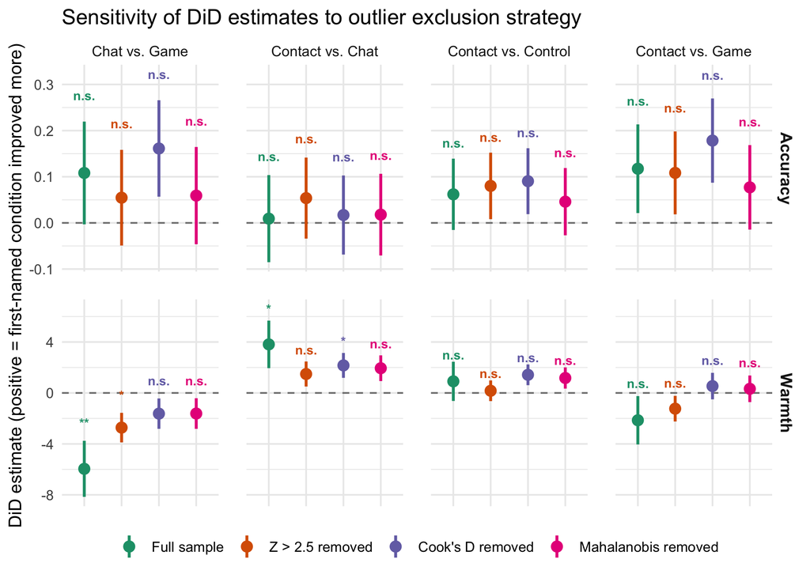

DiD estimates across four outlier exclusion strategies. Each column is a pairwise condition contrast (e.g. ‘Contact vs. Chat’ = Contact Δ minus Chat Δ); positive values mean the first-named condition improved more. Accuracy and Warmth are shown in separate rows with independent y-axes. Error bars = ±SE.

```r
# ── Helper: fit all pairwise DiD contrasts for a given dataset + condition set ─
pairwise_did_contrasts <- function(d, conds) {
  d <- d %>% mutate(treatment = factor(treatment, levels = conds))
  n <- length(conds)

  fit_one <- function(dv_pre, dv_post, dv_label) {
    long <- d %>%
      select(ResponseId, treatment, all_of(c(dv_pre, dv_post))) %>%
      pivot_longer(c(all_of(dv_pre), all_of(dv_post)),
                   names_to = "time", values_to = "y") %>%
      mutate(time = factor(if_else(str_detect(time, "pre"), "pre", "post"),
                           levels = c("pre", "post")))
    m   <- lmer(y ~ time * treatment + (1 | ResponseId), data = long, REML = FALSE)
    emm <- emmeans(m, ~ time * treatment)
    pairs_idx <- combn(seq_along(conds), 2, simplify = FALSE)
    con_list  <- lapply(pairs_idx, function(idx) {
      v <- numeric(2 * n)
      i <- idx[1]; j <- idx[2]
      v[(2*i-1):(2*i)] <- c(-1,  1)
      v[(2*j-1):(2*j)] <- c( 1, -1)
      v
    })
    names(con_list) <- sapply(pairs_idx, function(idx)
      paste0(conds[idx[1]], " vs. ", conds[idx[2]]))
    contrast(emm, con_list) %>% as_tibble() %>% mutate(dv = dv_label)
  }

  bind_rows(
    fit_one("accuracy_pre",        "accuracy_post",        "Accuracy"),
    fit_one("warmth_outgroup_pre",  "warmth_outgroup_post", "Warmth")
  )
}

# ── Build the four samples (always on raw full/Feb17 data, 3 conditions) ──────
dat_raw <- read_parquet(paste0(base_path,
  if (full_data) "analysis_data.parquet" else "analysis_data_Feb17.parquet")) %>%
  mutate(
    treatment   = factor(treatment, levels = c("Contact", "Chat", "Game")),
    acc_change  = accuracy_post - accuracy_pre,
    warm_change = warmth_outgroup_post - warmth_outgroup_pre
  )

# z-score flags
dat_raw <- dat_raw %>%
  group_by(treatment) %>%
  mutate(acc_z  = scale(acc_change)[, 1],
         warm_z = scale(warm_change)[, 1]) %>%
  ungroup()
ids_z_rob <- dat_raw$ResponseId[abs(dat_raw$acc_z) > 2.5 | abs(dat_raw$warm_z) > 2.5]

# Cook's D flags
anc_a <- lm(accuracy_post        ~ accuracy_pre        + treatment, data = dat_raw)
anc_w <- lm(warmth_outgroup_post ~ warmth_outgroup_pre + treatment, data = dat_raw)
ct    <- 4 / nrow(dat_raw)
ids_cd_rob <- dat_raw$ResponseId[cooks.distance(anc_a) > ct | cooks.distance(anc_w) > ct]

# Mahalanobis flags
mah_rob <- mahalanobis(
  cbind(dat_raw$acc_change, dat_raw$warm_change),
  colMeans(cbind(dat_raw$acc_change, dat_raw$warm_change), na.rm = TRUE),
  cov(cbind(dat_raw$acc_change, dat_raw$warm_change), use = "complete.obs")
)
ids_mah_rob <- dat_raw$ResponseId[mah_rob > qchisq(0.975, df = 2)]

conds_3 <- c("Contact", "Chat", "Game")

# ── Helper: Contact vs. pooled controls DiD ──────────────────────────────────
contact_vs_control_did <- function(d) {
  d <- d %>%
    mutate(trt2 = if_else(treatment == "Contact", "Contact", "Control"),
           trt2 = factor(trt2, levels = c("Contact", "Control")))

  fit_pooled <- function(dv_pre, dv_post, dv_label) {
    long <- d %>%
      select(ResponseId, trt2, all_of(c(dv_pre, dv_post))) %>%
      pivot_longer(c(all_of(dv_pre), all_of(dv_post)),
                   names_to = "time", values_to = "y") %>%
      mutate(time = factor(if_else(str_detect(time, "pre"), "pre", "post"),
                           levels = c("pre", "post")))
    m   <- lmer(y ~ time * trt2 + (1 | ResponseId), data = long, REML = FALSE)
    emm <- emmeans(m, ~ time * trt2)
    con <- list(`Contact vs. Control` = c(-1, 1, 1, -1))
    contrast(emm, con) %>% as_tibble() %>% mutate(dv = dv_label)
  }

  bind_rows(
    fit_pooled("accuracy_pre",       "accuracy_post",        "Accuracy"),
    fit_pooled("warmth_outgroup_pre", "warmth_outgroup_post", "Warmth")
  ) %>% mutate(contrast = "Contact vs. Control")
}

did_robust <- bind_rows(
  pairwise_did_contrasts(dat_raw,                                      conds_3) %>% mutate(sample = "Full sample"),
  pairwise_did_contrasts(filter(dat_raw, !ResponseId %in% ids_z_rob),  conds_3) %>% mutate(sample = "Z > 2.5 removed"),
  pairwise_did_contrasts(filter(dat_raw, !ResponseId %in% ids_cd_rob), conds_3) %>% mutate(sample = "Cook's D removed"),
  pairwise_did_contrasts(filter(dat_raw, !ResponseId %in% ids_mah_rob),conds_3) %>% mutate(sample = "Mahalanobis removed"),
  contact_vs_control_did(dat_raw)                                                %>% mutate(sample = "Full sample"),
  contact_vs_control_did(filter(dat_raw, !ResponseId %in% ids_z_rob))            %>% mutate(sample = "Z > 2.5 removed"),
  contact_vs_control_did(filter(dat_raw, !ResponseId %in% ids_cd_rob))           %>% mutate(sample = "Cook's D removed"),
  contact_vs_control_did(filter(dat_raw, !ResponseId %in% ids_mah_rob))          %>% mutate(sample = "Mahalanobis removed")
) %>%
  mutate(
    sample = factor(sample, levels = c("Full sample", "Z > 2.5 removed",
                                       "Cook's D removed", "Mahalanobis removed")),
    ymin   = estimate - SE,
    ymax   = estimate + SE,
    stars  = p_to_stars(p.value)
  )

# Per-panel star y position: add a small offset above the panel's own ymax
did_robust <- did_robust %>%
  group_by(dv, contrast) %>%
  mutate(star_y = ymax + (max(ymax) - min(ymin)) * 0.18) %>%
  ungroup()

ggplot(did_robust, aes(x = sample, y = estimate, color = sample)) +
  geom_hline(yintercept = 0, linetype = "dashed", color = "gray50") +
  geom_pointrange(aes(ymin = ymin, ymax = ymax), size = 0.55, linewidth = 0.85) +
  geom_text(aes(y = star_y, label = stars), size = 2.8, fontface = "bold") +
  facet_grid(dv ~ contrast, scales = "free") +
  scale_color_brewer(palette = "Dark2", name = NULL) +
  labs(x = NULL,
       y = "DiD estimate (positive = first-named condition improved more)",
       title = "Sensitivity of DiD estimates to outlier exclusion strategy") +
  theme_minimal(base_size = 11) +
  theme(axis.text.x  = element_blank(),
        axis.ticks.x = element_blank(),
        legend.position = "bottom",
        panel.spacing = unit(1.2, "lines"),
        strip.text.x = element_text(size = 9),
        strip.text.y = element_text(size = 10, face = "bold"))
```

# Appendix: Comments

```r
dat %>%
  filter(!is.na(comments)) %>%
  select(ResponseId, treatment, comments) %>%
  gt() %>%
  tab_header(title = "Participant Comments")
```

User comments

Participant Comments

[output not shown]

[output cut: 74 more lines]

## Sample

```r
n_total <- nrow(dat)
n_by_condition <- dat %>% count(treatment)
n_contact <- n_by_condition %>% filter(treatment == "Contact") %>% pull(n)
if (!pool_controls) {
  n_chat <- n_by_condition %>% filter(treatment == "Chat") %>% pull(n)
  n_game <- n_by_condition %>% filter(treatment == "Game") %>% pull(n)
} else {
  n_control <- n_by_condition %>% filter(treatment == "Control") %>% pull(n)
}
mean_age   <- mean(dat$age, na.rm = TRUE)
pct_female <- mean(dat$gender == "Female", na.rm = TRUE) * 100
```

We recruited 401 participants from Prolific: 208 in the Contact condition, 99 in the Chat condition, and 94 in the Game condition (mean age = 42.20, 52% female).

```r
dat %>%
  group_by(treatment) %>%
  summarise(
    N = n(),
    `Democrats (D→R)` = sum(learner_party == "D→R"),
    `Republicans (R→D)` = sum(learner_party == "R→D"),
    `Mean Age` = mean(age, na.rm = TRUE) %>% numformat(),
    `% Female` = (sum(gender == "Female", na.rm = TRUE) / n() * 100) %>% numformat(0),
    `Extremism (M)` = mean(political_extremism, na.rm = TRUE) %>% numformat(),
    .groups = "drop"
  ) %>%
  gt() %>%
  tab_header(title = "Sample Composition by Condition")
```

Sample Composition by Condition

| treatment | N | Democrats (D→R) | Republicans (R→D) | Mean Age | % Female | Extremism (M) |
| --- | --- | --- | --- | --- | --- | --- |
| Contact | 208 | 99 | 109 | 41.30 | 50 | 76.36 |
| Chat | 99 | 50 | 49 | 44.10 | 53 | 78.46 |
| Game | 94 | 53 | 41 | 42.19 | 53 | 77.19 |

```r
# Actual green score by party (from own responses)
actual_by_party <- dat %>%
  group_by(learner_party) %>%
  summarise(
    actual = mean(actual_green, na.rm = TRUE) %>% numformat(),
    .groups = "drop"
  )

dat %>%
  group_by(treatment, learner_party) %>%
  summarise(
    `Baseline belief (M)` = mean(green_outgroup_pre, na.rm = TRUE) %>% numformat(),
    .groups = "drop"
  ) %>%
  left_join(actual_by_party, by = "learner_party") %>%
  rename(Condition = treatment, `Learner party` = learner_party,
         `Actual outgroup mean` = actual) %>%
  gt() %>%
  tab_header(title = "Baseline Outgroup Env. Beliefs by Condition and Party",
             subtitle = "Composite mean of env1–6 (1–5 scale); higher = more pro-environment attributed to outgroup") %>%
  tab_footnote("Actual = true mean from the outgroup's own responses. D→R = Democrats estimating Republicans; R→D = Republicans estimating Democrats.",
               locations = cells_title())
```

Mean baseline outgroup environmental attitude beliefs (composite of env1–6, 1–5 scale) by condition and learner party. ‘Actual’ is the true mean of the outgroup’s own responses (Republicans’ actual for D→R; Democrats’ actual for R→D).

Baseline Outgroup Env. Beliefs by Condition and Party<sup>1</sup>

Composite mean of env1–6 (1–5 scale); higher = more pro-environment attributed to outgroup<sup>1</sup>

| Condition | Learner party | Baseline belief (M) | Actual outgroup mean |
| --- | --- | --- | --- |
| Contact | D→R | 2.10 | 3.59 |
| Contact | R→D | 3.86 | 4.06 |
| Chat | D→R | 2.13 | 3.59 |
| Chat | R→D | 3.86 | 4.06 |
| Game | D→R | 2.05 | 3.59 |
| Game | R→D | 4.03 | 4.06 |

<sup>1</sup> Actual = true mean from the outgroup's own responses. D→R = Democrats estimating Republicans; R→D = Republicans estimating Democrats.

### Condition balance check

```r
# Check randomization: are conditions balanced on baseline measures?
bal_acc  <- aov(accuracy_pre ~ treatment, data = dat)
bal_warm <- aov(warmth_outgroup_pre ~ treatment, data = dat)
bal_ext  <- aov(political_extremism ~ treatment, data = dat)

bal_acc_p  <- summary(bal_acc)[[1]][["Pr(>F)"]][1]
bal_warm_p <- summary(bal_warm)[[1]][["Pr(>F)"]][1]
bal_ext_p  <- summary(bal_ext)[[1]][["Pr(>F)"]][1]
```

Conditions did not differ significantly on baseline accuracy (*F* = 0.847), baseline warmth (*F* = 0.038), or political extremism (*F* = 0.774), supporting successful randomization.

### Differential engagement / cheating check

```r
# Survey phase: tab switches and hidden time (same for all conditions)
eng_survey_aov_switch <- aov(tab_switch_count   ~ treatment, data = dat)
eng_survey_aov_hidden <- aov(I(time_hidden_ms / 1000) ~ treatment, data = dat)
eng_survey_switch_p <- summary(eng_survey_aov_switch)[[1]][["Pr(>F)"]][1]
eng_survey_hidden_p <- summary(eng_survey_aov_hidden)[[1]][["Pr(>F)"]][1]

# Intervention phase: tab switches and time in intervention window
eng_bot_aov_switch <- aov(tab_switch_count_bot ~ treatment, data = dat)
eng_bot_aov_hidden <- aov(I(time_hidden_ms_bot / 60000) ~ treatment, data = dat)
eng_bot_switch_p <- summary(eng_bot_aov_switch)[[1]][["Pr(>F)"]][1]
eng_bot_hidden_p <- summary(eng_bot_aov_hidden)[[1]][["Pr(>F)"]][1]

# Pairwise for bot tab switches (the only marginally significant survey metric)
eng_bot_switch_tukey <- dat %>% tukey_hsd(tab_switch_count_bot ~ treatment)
if (!pool_controls) {
  eng_bot_contact_game_p <- eng_bot_switch_tukey %>%
    filter(group1 == "Contact", group2 == "Game") %>% pull(p.adj)
} else {
  eng_bot_contact_game_p <- eng_bot_switch_tukey %>%
    filter(group1 == "Contact", group2 == "Control") %>% pull(p.adj)
}

# Summary table
eng_summary <- dat %>%
  group_by(treatment) %>%
  summarise(
    `Survey switches (M)` = mean(tab_switch_count, na.rm = TRUE),
    `Survey hidden (sec, M)` = mean(time_hidden_ms / 1000, na.rm = TRUE),
    `Intervention switches (M)` = mean(tab_switch_count_bot, na.rm = TRUE),
    `Intervention time in window (min, M)` = mean(time_hidden_ms_bot / 60000, na.rm = TRUE),
    .groups = "drop"
  )
```

```r
eng_summary %>%
  mutate(across(where(is.double), ~ numformat(.x))) %>%
  rename(Condition = treatment) %>%
  gt() %>%
  tab_header(title = "Engagement by Condition") %>%
  tab_footnote(
    "Survey phase: tab switches and hidden time during the questionnaire. Intervention phase: switches and time during the treatment window.",
    locations = cells_title()
  )
```

Engagement by Condition<sup>1</sup>

| Condition | Survey switches (M) | Survey hidden (sec, M) | Intervention switches (M) | Intervention time in window (min, M) |
| --- | --- | --- | --- | --- |
| Contact | 0.21 | 2.85 | 1.45 | 4.49 |
| Chat | 0.14 | 2.45 | 1.18 | 0.41 |
| Game | 0.11 | 1.24 | 0.19 | 0.15 |

<sup>1</sup> Survey phase: tab switches and hidden time during the questionnaire. Intervention phase: switches and time during the treatment window.

**Survey phase** (left the survey screen): conditions did not differ in tab switches (*F* = 0.420) or hidden time (*F* = 0.517), ruling out differential cheating during measurement.

### Outlier removal

```r
dat <- dat %>%
  mutate(
    acc_change  = accuracy_post - accuracy_pre,
    warm_change = warmth_outgroup_post - warmth_outgroup_pre
  )

# ── Cook's D > 4/n from ANCOVA (accuracy and warmth) ─────────────────────────
ancova_acc  <- lm(accuracy_post        ~ accuracy_pre        + treatment, data = dat)
ancova_warm <- lm(warmth_outgroup_post ~ warmth_outgroup_pre + treatment, data = dat)
cooks_thresh <- 4 / nrow(dat)

dat <- dat %>%
  mutate(
    cooks_acc  = cooks.distance(ancova_acc),
    cooks_warm = cooks.distance(ancova_warm),
    flag_cooks = cooks_acc > cooks_thresh | cooks_warm > cooks_thresh
  )

# ── Mahalanobis distance on (acc_change, warm_change) ────────────────────────
# Chi-square threshold: p < .025, df = 2
mah_thresh <- qchisq(0.975, df = 2)
dat <- dat %>%
  mutate(
    mah_d    = mahalanobis(cbind(acc_change, warm_change),
                           colMeans(cbind(acc_change, warm_change), na.rm = TRUE),
                           cov(cbind(acc_change, warm_change), use = "complete.obs")),
    flag_mah = mah_d > mah_thresh
  )

ids_cooks <- dat$ResponseId[dat$flag_cooks]
ids_mah   <- dat$ResponseId[dat$flag_mah]
n_cooks   <- length(ids_cooks)
n_mah     <- length(ids_mah)
n_overlap <- sum(ids_mah %in% ids_cooks)   # Mah is a strict subset of Cook's D

# Use Mahalanobis for removal (more conservative; Cook's D subset already included)
outlier_ids <- ids_mah
n_before  <- nrow(dat)
dat       <- dat %>% filter(!ResponseId %in% outlier_ids)
n_removed <- n_before - nrow(dat)

# ── Regression-to-mean evidence (on cleaned data) ────────────────────────────
rtm_cors <- dat %>%
  group_by(treatment) %>%
  summarise(r_pre_change = cor(accuracy_pre, acc_change, use = "complete.obs"),
            .groups = "drop")
rtm_cors_text <- rtm_cors %>%
  mutate(s = paste0(treatment, ": *r* = ", numformat(r_pre_change))) %>%
  pull(s) %>% paste(collapse = ", ")
```

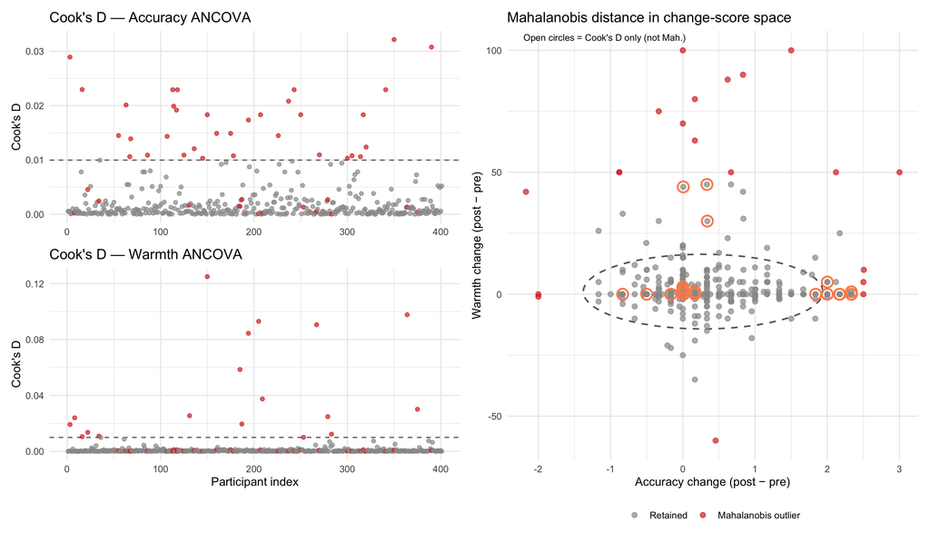

```r
dat_all <- bind_rows(
  dat,
  bind_rows(
    filter(read_parquet(paste0(base_path, if (full_data) "analysis_data.parquet" else "analysis_data_Feb17.parquet")),
           TRUE) %>%
      mutate(
        acc_change  = accuracy_post - accuracy_pre,
        warm_change = warmth_outgroup_post - warmth_outgroup_pre,
        treatment   = factor(if (pool_controls)
                               if_else(treatment == "Contact", "Contact", "Control")
                             else treatment,
                             levels = if (pool_controls) c("Contact","Control")
                                      else c("Contact","Chat","Game"))
      )
  ) %>% filter(ResponseId %in% c(ids_cooks, ids_mah))
) %>% distinct(ResponseId, .keep_all = TRUE)

# Rebuild Cook's D on full pre-removal data for plotting
dat_pre <- read_parquet(paste0(base_path, if (full_data) "analysis_data.parquet" else "analysis_data_Feb17.parquet")) %>%
  mutate(
    acc_change  = accuracy_post - accuracy_pre,
    warm_change = warmth_outgroup_post - warmth_outgroup_pre,
    treatment   = factor(if (pool_controls)
                           if_else(treatment == "Contact", "Contact", "Control")
                         else treatment,
                         levels = if (pool_controls) c("Contact","Control")
                                  else c("Contact","Chat","Game"))
  )

anc_acc_pre  <- lm(accuracy_post        ~ accuracy_pre        + treatment, data = dat_pre)
anc_warm_pre <- lm(warmth_outgroup_post ~ warmth_outgroup_pre + treatment, data = dat_pre)
mah_pre <- mahalanobis(
  cbind(dat_pre$acc_change, dat_pre$warm_change),
  colMeans(cbind(dat_pre$acc_change, dat_pre$warm_change), na.rm = TRUE),
  cov(cbind(dat_pre$acc_change, dat_pre$warm_change), use = "complete.obs")
)

plot_dat <- dat_pre %>%
  mutate(
    cooks_acc  = cooks.distance(anc_acc_pre),
    cooks_warm = cooks.distance(anc_warm_pre),
    mah_d      = mah_pre,
    flag_cooks = cooks_acc > cooks_thresh | cooks_warm > cooks_thresh,
    flag_mah   = mah_d > mah_thresh,
    idx        = row_number()
  )

# Cook's D panels
p_cook_acc <- ggplot(plot_dat, aes(x = idx, y = cooks_acc, color = flag_cooks)) +
  geom_hline(yintercept = cooks_thresh, linetype = "dashed", color = "gray40") +
  geom_point(size = 1.5, alpha = 0.7) +
  scale_color_manual(values = c("FALSE" = "gray60", "TRUE" = "#D73027"), guide = "none") +
  labs(x = NULL, y = "Cook's D", title = "Cook's D — Accuracy ANCOVA") +
  theme_minimal(base_size = 11)

p_cook_warm <- ggplot(plot_dat, aes(x = idx, y = cooks_warm, color = flag_cooks)) +
  geom_hline(yintercept = cooks_thresh, linetype = "dashed", color = "gray40") +
  geom_point(size = 1.5, alpha = 0.7) +
  scale_color_manual(values = c("FALSE" = "gray60", "TRUE" = "#D73027"), guide = "none") +
  labs(x = "Participant index", y = "Cook's D", title = "Cook's D — Warmth ANCOVA") +
  theme_minimal(base_size = 11)

# Mahalanobis scatter
p_mah <- ggplot(plot_dat, aes(x = acc_change, y = warm_change)) +
  stat_ellipse(level = 0.975, linetype = "dashed", color = "gray40", linewidth = 0.7) +
  geom_point(aes(color = flag_mah), size = 2, alpha = 0.7) +
  geom_point(data = filter(plot_dat, flag_cooks & !flag_mah),
             shape = 1, size = 4, color = "#FC8D59", stroke = 1.2) +
  scale_color_manual(values = c("FALSE" = "gray60", "TRUE" = "#D73027"),
                     labels = c("Retained", "Mahalanobis outlier"),
                     name = NULL) +
  annotate("text", x = -Inf, y = Inf, hjust = -0.1, vjust = 1.5, size = 3,
           label = "Open circles = Cook's D only (not Mah.)") +
  labs(x = "Accuracy change (post − pre)", y = "Warmth change (post − pre)",
       title = "Mahalanobis distance in change-score space") +
  theme_minimal(base_size = 11) +
  theme(legend.position = "bottom")

(p_cook_acc / p_cook_warm) | p_mah
```

**Outlier methods compared.** Cook’s D (threshold 4/*n* = 0.0100) flagged 48 participants across the two ANCOVA models. Mahalanobis distance on the joint (accuracy change, warmth change) space (χ² threshold *p* < .025, df = 2) flagged 20, all of whom were also flagged by Cook’s D. The remaining 28 Cook’s D flags were influential in one ANCOVA but not extreme in the bivariate change space. We use the **Mahalanobis criterion** for removal as it directly captures participants with unusual *combinations* of change scores, is scale-invariant, and results in a more conservative exclusion (*N* removed = 20). All analyses below use the cleaned sample (*N* = 381).

**Baseline and change.** Within each condition, participants who started with the lowest accuracy tended to show the largest improvements (Contact: *r* = -0.72, Chat: *r* = -0.62, Game: *r* = -0.62). This is mechanically expected in any pre-post design and applies similarly across conditions, so it does not confound the condition comparison. The DiD contrast and ANCOVA below account for baseline by design.

```r
desc_vars <- list(
  "Accuracy (pre)"        = "accuracy_pre",
  "Accuracy (post)"       = "accuracy_post",
  "Warmth (pre)"          = "warmth_outgroup_pre",
  "Warmth (post)"         = "warmth_outgroup_post",
  "Confidence (pre)"      = "confidence_outgroup_pre",
  "Confidence (post)"     = "confidence_outgroup_post",
  "Donation (cents)"      = "donation",
  "Age"                   = "age",
  "Political extremism"   = "political_extremism"
)

fmt_msd <- function(x) {
  m <- mean(x, na.rm = TRUE)
  s <- sd(x,   na.rm = TRUE)
  paste0(numformat(m), " (", numformat(s), ")")
}

conds <- levels(dat$treatment)

desc_tbl <- map_dfr(names(desc_vars), function(label) {
  col <- desc_vars[[label]]
  row <- tibble(Variable = label, Overall = fmt_msd(dat[[col]]))
  for (cond in conds) {
    row[[cond]] <- fmt_msd(dat[[col]][dat$treatment == cond])
  }
  row
})

desc_tbl %>%
  gt() %>%
  tab_header(title = "Descriptive Statistics by Condition",
             subtitle = "M (SD); after Cook's D outlier removal") %>%
  tab_footnote("Accuracy = negative absolute error (higher = more accurate). Warmth on 0–100 scale. Confidence on 1–5 scale.",
               locations = cells_title())
```

Descriptive statistics (M ± SD) for all key variables overall and by condition, after outlier removal.

Descriptive Statistics by Condition<sup>1</sup>

| Variable | Overall | Contact | Chat | Game |
| --- | --- | --- | --- | --- |
| Accuracy (pre) | -1.12 (0.83) | -1.13 (0.83) | -1.08 (0.80) | -1.13 (0.89) |
| Accuracy (post) | -0.77 (0.64) | -0.76 (0.60) | -0.72 (0.64) | -0.84 (0.73) |
| Warmth (pre) | 33.04 (25.99) | 35.86 (26.20) | 31.29 (26.13) | 28.56 (24.84) |
| Warmth (post) | 34.83 (27.10) | 38.21 (27.42) | 31.70 (26.50) | 30.59 (26.31) |
| Confidence (pre) | 3.12 (1.02) | 3.08 (1.05) | 3.07 (0.97) | 3.25 (1.00) |
| Confidence (post) | 3.39 (1.01) | 3.47 (0.96) | 3.28 (1.05) | 3.31 (1.08) |
| Donation (cents) | 20.15 (21.50) | 20.13 (21.40) | 22.07 (22.41) | 18.08 (20.76) |
| Age | 42.17 (13.40) | 41.04 (13.32) | 44.26 (13.69) | 42.44 (13.11) |
| Political extremism | 76.85 (24.10) | 76.05 (25.37) | 78.21 (23.19) | 77.18 (22.23) |

<sup>1</sup> Accuracy = negative absolute error (higher = more accurate). Warmth on 0–100 scale. Confidence on 1–5 scale.

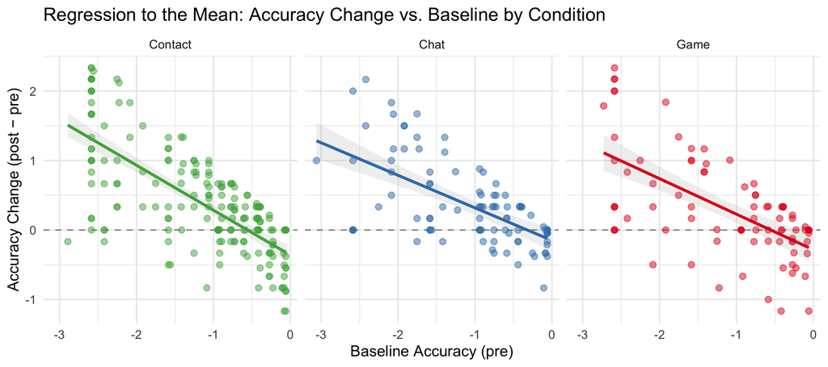

Accuracy change vs. baseline accuracy by condition. Strong negative slopes indicate regression to the mean: participants who started most inaccurate improved most, regardless of condition.

```r
ggplot(dat, aes(x = accuracy_pre, y = acc_change, color = treatment)) +
  geom_hline(yintercept = 0, linetype = "dashed", color = "gray60") +
  geom_point(alpha = 0.5, size = 2) +
  geom_smooth(method = "lm", se = TRUE, alpha = 0.15) +
  scale_color_manual(values = condition_colors, name = "Condition") +
  facet_wrap(~ treatment) +
  labs(
    x = "Baseline Accuracy (pre)",
    y = "Accuracy Change (post − pre)",
    title = "Regression to the Mean: Accuracy Change vs. Baseline by Condition"
  ) +
  theme_minimal(base_size = 12) +
  theme(legend.position = "none")
```

```r
ggsave(paste0(fig_path, "rtm_check.png"), width = 9, height = 4, dpi = 300)
```

## Pre-Post Changes Overall

Before examining condition differences, we verify that the pre-post design shows evidence of change across the full sample.

```r
# Accuracy
acc_overall <- t.test(dat$accuracy_post, dat$accuracy_pre, paired = TRUE)
acc_d_overall <- mean(dat$accuracy_post - dat$accuracy_pre) / sd(dat$accuracy_post - dat$accuracy_pre)

# Warmth
warm_overall <- t.test(dat$warmth_outgroup_post, dat$warmth_outgroup_pre, paired = TRUE)
warm_d_overall <- mean(dat$warmth_outgroup_post - dat$warmth_outgroup_pre) / sd(dat$warmth_outgroup_post - dat$warmth_outgroup_pre)

# Confidence
conf_overall <- t.test(dat$confidence_outgroup_post, dat$confidence_outgroup_pre, paired = TRUE)
conf_d_overall <- mean(dat$confidence_outgroup_post - dat$confidence_outgroup_pre) / sd(dat$confidence_outgroup_post - dat$confidence_outgroup_pre)
```

Across the full sample, accuracy improved (*t*(380) = 9.60, *p* < .001, *d* = 0.49), outgroup warmth increased (*t*(380) = 4.28, *p* < .001, *d* = 0.22), and confidence changed (*t*(380) = 4.94, *p* < .001, *d* = 0.25).

## Condition Differences (Main Analysis)

The primary question is whether the Contact condition shows greater pre-post improvement than the two control conditions (Chat, Game) pooled together. We use a mixed-effects model with a `time × treatment` interaction, and test the key contrast: Contact Δ vs. average of Chat Δ and Game Δ.

### Accuracy

```r
accuracy_long <- dat %>%
  select(ResponseId, treatment, learner_party, accuracy_pre, accuracy_post) %>%
  pivot_longer(c(accuracy_pre, accuracy_post),
               names_to = "time", names_pattern = "accuracy_(pre|post)",
               values_to = "accuracy") %>%
  mutate(time = factor(time, levels = c("pre", "post")))

# Model: time × treatment (reference = Contact)
m_acc <- lmer(accuracy ~ time * treatment + (1 | ResponseId), data = accuracy_long)

# Pre-post differences within each condition
emm_acc_by_cond <- emmeans(m_acc, ~ time | treatment)
acc_contrasts <- contrast(emm_acc_by_cond, "revpairwise", by = "treatment") %>%
  as_tibble()  # positive = improvement (post - pre)

# Full grid for DiD contrasts — adaptive to pool_controls toggle
# Grid order (3-cond): pre×Contact, post×Contact, pre×Chat, post×Chat, pre×Game, post×Game
# Grid order (pooled): pre×Contact, post×Contact, pre×Control, post×Control
emm_acc_full <- emmeans(m_acc, ~ time * treatment)
pull_did <- function(tbl, nm, col) tbl %>% filter(contrast == nm) %>% pull({{ col }})

if (pool_controls) {
  acc_did <- contrast(emm_acc_full, list(
    `Contact vs. Control` = c(1, -1, -1, 1)   # Control Δ - Contact Δ ... sign: positive = Control > Contact
  ))
  # flip sign so positive = Contact improved more
  acc_did_tbl <- acc_did %>% as_tibble() %>% mutate(estimate = -estimate)
  acc_main_b  <- pull_did(acc_did_tbl, "Contact vs. Control", estimate)
  acc_main_se <- pull_did(acc_did_tbl, "Contact vs. Control", SE)
  acc_main_p  <- pull_did(acc_did_tbl, "Contact vs. Control", p.value)
  acc_chat_vs_contact_b <- NA_real_; acc_chat_vs_contact_p <- NA_real_
  acc_game_vs_contact_b <- NA_real_; acc_game_vs_contact_p <- NA_real_
  acc_chat_vs_game_b    <- NA_real_; acc_chat_vs_game_p    <- NA_real_
} else {
  acc_did <- contrast(emm_acc_full, list(
    `Contact vs. pooled controls` = c(-1,  1,  0.5, -0.5,  0.5, -0.5),
    `Chat vs. Contact`            = c( 1, -1, -1,    1,    0,    0  ),
    `Game vs. Contact`            = c( 1, -1,  0,    0,   -1,    1  ),
    `Chat vs. Game`               = c( 0,  0, -1,    1,    1,   -1  )
  ))
  acc_did_tbl           <- acc_did %>% as_tibble()
  acc_main_b            <- pull_did(acc_did_tbl, "Contact vs. pooled controls", estimate)
  acc_main_se           <- pull_did(acc_did_tbl, "Contact vs. pooled controls", SE)
  acc_main_p            <- pull_did(acc_did_tbl, "Contact vs. pooled controls", p.value)
  acc_chat_vs_contact_b <- pull_did(acc_did_tbl, "Chat vs. Contact", estimate)
  acc_chat_vs_contact_p <- pull_did(acc_did_tbl, "Chat vs. Contact", p.value)
  acc_game_vs_contact_b <- pull_did(acc_did_tbl, "Game vs. Contact", estimate)
  acc_game_vs_contact_p <- pull_did(acc_did_tbl, "Game vs. Contact", p.value)
  acc_chat_vs_game_b    <- pull_did(acc_did_tbl, "Chat vs. Game",    estimate)
  acc_chat_vs_game_p    <- pull_did(acc_did_tbl, "Chat vs. Game",    p.value)
}
```

The time × treatment interaction tests whether conditions differed in accuracy improvement.

```r
acc_contrasts %>%
  select(Condition = treatment,
         `Pre→Post Improvement` = estimate,
         SE, df, `t-ratio` = t.ratio, `p-value` = p.value) %>%
  mutate(
    `Pre→Post Improvement` = numformat(`Pre→Post Improvement`),
    SE = numformat(SE),
    df = numformat(df, 0),
    `t-ratio` = numformat(`t-ratio`),
    `p-value` = map_chr(`p-value`, pformat)
  ) %>%
  gt() %>%
  tab_header(title = "Accuracy: Pre-Post Improvement by Condition") %>%
  tab_footnote("Positive = improvement. Estimated from mixed-effects model (Contact as reference).",
               locations = cells_title())
```

Accuracy: Pre-Post Improvement by Condition<sup>1</sup>

| Condition | Pre→Post Improvement | SE | df | t-ratio | p-value |
| --- | --- | --- | --- | --- | --- |
| Contact | 0.37 | 0.05 | 378 | 7.35 | < .001 |
| Chat | 0.35 | 0.07 | 378 | 4.87 | < .001 |
| Game | 0.29 | 0.08 | 378 | 3.86 | < .001 |

<sup>1</sup> Positive = improvement. Estimated from mixed-effects model (Contact as reference).

**Primary test:** Contact vs. pooled controls: *b* = 0.05, SE = 0.07, *p* = 0.516. **Pairwise:** Chat vs. Contact (*b* = -0.02, *p* = 0.840); Game vs. Contact (*b* = -0.08, *p* = 0.401); Chat vs. Game (*b* = 0.06, *p* = 0.575).

### Model choice: lmer vs. ANCOVA

```r
# Pre-post correlation by condition (drives the key tradeoff between lmer and ANCOVA)
prepost_cors <- dat %>%
  group_by(treatment) %>%
  summarise(
    r_prepost = cor(accuracy_pre, accuracy_post, use = "complete.obs"),
    .groups = "drop"
  )

# ANCOVA: regress post on pre + treatment
ancova_acc <- lm(accuracy_post ~ accuracy_pre + treatment, data = dat)
ancova_pre_coef <- coef(ancova_acc)["accuracy_pre"]
ancova_pre_se   <- summary(ancova_acc)$coefficients["accuracy_pre", "Std. Error"]
ancova_pre_p    <- summary(ancova_acc)$coefficients["accuracy_pre", "Pr(>|t|)"]

# Test homogeneity of regression slopes (pre × condition interaction)
ancova_hom   <- lm(accuracy_post ~ accuracy_pre * treatment, data = dat)
ancova_hom_p <- anova(ancova_acc, ancova_hom)$`Pr(>F)`[2]

if (!pool_controls) {
  ancova_game_b <- coef(ancova_acc)["treatmentGame"]
  ancova_chat_b <- coef(ancova_acc)["treatmentChat"]
  ancova_game_p <- summary(ancova_acc)$coefficients["treatmentGame", "Pr(>|t|)"]
  ancova_chat_p <- summary(ancova_acc)$coefficients["treatmentChat", "Pr(>|t|)"]
} else {
  ancova_game_b <- NA_real_; ancova_chat_b <- NA_real_
  ancova_game_p <- NA_real_; ancova_chat_p <- NA_real_
}
```

For a **randomized pre-post design**, both `lmer(accuracy ~ time * treatment + (1|id))` and `lm(accuracy_post ~ accuracy_pre + treatment)` (ANCOVA) are valid, but they make different assumptions. **ANCOVA** is generally preferred in randomized experiments [@vickers2001analysing]. It regresses the post-score on the pre-score as a covariate, removing pre-score variance from the residuals and increasing statistical power. In our data, the pre-score coefficient is *b* = 0.43 (*SE* = 0.03, *p* < .001): substantially less than 1.0, which means there is regression to the mean and ANCOVA extracts more power than a change-score approach.

**lmer** (`lmer(y ~ time * treatment + (1|id))`) models both time points jointly with a random intercept per participant. The random intercept implicitly assumes the pre-score coefficient equals 1, equivalent to an ANCOVA with *b* = 1 for `pre`. When the true pre-post correlation is well below 1 — here *r* = 0.49 (Contact), *r* = 0.67 (Chat), *r* = 0.60 (Game) — the lmer model leaves avoidable residual variance on the table.

**Homogeneity of slopes:** ANCOVA requires the pre → post regression slope to be the same in all conditions. The `pre × treatment` interaction test gives *p* = 0.053. This assumption is not violated, supporting ANCOVA as the primary model.

**Both models agree:** conditions do not differ significantly in accuracy improvement. For the pre-registered full study, we will use **ANCOVA** as the primary specification and lmer as a robustness check.

```r
# Build a side-by-side comparison table: lmer DiD vs ANCOVA
ancova_se_mat <- summary(ancova_acc)$coefficients

if (pool_controls) {
  # Only one contrast available: Contact vs. Control
  ancova_ctrl_b  <- coef(ancova_acc)["treatmentControl"]
  ancova_ctrl_se <- ancova_se_mat["treatmentControl", "Std. Error"]
  ancova_ctrl_p  <- ancova_se_mat["treatmentControl", "Pr(>|t|)"]
  model_compare <- tribble(
    ~Contrast,              ~`lmer b`, ~`lmer SE`, ~`lmer p`,
                             ~`ANCOVA b`, ~`ANCOVA SE`, ~`ANCOVA p`,
    "Contact vs. Control",
      acc_main_b,
      pull_did(acc_did_tbl, "Contact vs. Control", SE),
      acc_main_p,
      -ancova_ctrl_b,        # flip sign: positive = Contact improved more
      ancova_ctrl_se,
      ancova_ctrl_p
  )
} else {
  model_compare <- tribble(
    ~Contrast,                    ~`lmer b`, ~`lmer SE`, ~`lmer p`,
                                   ~`ANCOVA b`, ~`ANCOVA SE`, ~`ANCOVA p`,
    "Contact vs. pooled controls",
      acc_main_b,
      pull_did(acc_did_tbl, "Contact vs. pooled controls", SE),
      acc_main_p,
      -(0.5 * ancova_chat_b + 0.5 * ancova_game_b),
      NA_real_, NA_real_,
    "Chat vs. Contact",
      acc_chat_vs_contact_b,
      pull_did(acc_did_tbl, "Chat vs. Contact", SE),
      acc_chat_vs_contact_p,
      ancova_chat_b,
      ancova_se_mat["treatmentChat", "Std. Error"],
      ancova_chat_p,
    "Game vs. Contact",
      acc_game_vs_contact_b,
      pull_did(acc_did_tbl, "Game vs. Contact", SE),
      acc_game_vs_contact_p,
      ancova_game_b,
      ancova_se_mat["treatmentGame", "Std. Error"],
      ancova_game_p,
    "Chat vs. Game",
      acc_chat_vs_game_b,
      pull_did(acc_did_tbl, "Chat vs. Game", SE),
      acc_chat_vs_game_p,
      ancova_chat_b - ancova_game_b,
      NA_real_, NA_real_
  )
}

model_compare %>%
  mutate(across(c(`lmer b`, `lmer SE`, `ANCOVA b`, `ANCOVA SE`),
                ~ ifelse(is.na(.x), "—", numformat(.x))),
         `lmer p`   = map_chr(`lmer p`,   ~ ifelse(is.na(.x), "—", pformat(.x))),
         `ANCOVA p` = map_chr(`ANCOVA p`, ~ ifelse(is.na(.x), "—", pformat(.x)))) %>%
  gt() %>%
  tab_header(title = "lmer vs. ANCOVA: Accuracy Condition Comparisons") %>%
  tab_spanner(label = "lmer (DiD contrast)", columns = c(`lmer b`, `lmer SE`, `lmer p`)) %>%
  tab_spanner(label = "ANCOVA (lm post ~ pre + condition)", columns = c(`ANCOVA b`, `ANCOVA SE`, `ANCOVA p`)) %>%
  tab_footnote("lmer estimates from emmeans DiD contrasts on the full time × treatment grid. ANCOVA estimates are regression coefficients (contact = reference). Contact vs. pooled ANCOVA SE omitted (non-standard linear combination).",
               locations = cells_title())
```

lmer vs. ANCOVA: Accuracy Condition Comparisons<sup>1</sup>

| Contrast | lmer (DiD contrast) lmer b | lmer (DiD contrast) lmer SE | lmer (DiD contrast) lmer p | ANCOVA (lm post ~ pre + condition) ANCOVA b | ANCOVA (lm post ~ pre + condition) ANCOVA SE | ANCOVA (lm post ~ pre + condition) ANCOVA p |
| --- | --- | --- | --- | --- | --- | --- |
| Contact vs. pooled controls | 0.05 | 0.07 | = 0.516 | 0.03 | — | — |
| Chat vs. Contact | -0.02 | 0.09 | = 0.840 | 0.02 | 0.07 | = 0.814 |
| Game vs. Contact | -0.08 | 0.09 | = 0.401 | -0.08 | 0.07 | = 0.265 |
| Chat vs. Game | 0.06 | 0.11 | = 0.575 | 0.09 | — | — |

<sup>1</sup> lmer estimates from emmeans DiD contrasts on the full time × treatment grid. ANCOVA estimates are regression coefficients (contact = reference). Contact vs. pooled ANCOVA SE omitted (non-standard linear combination).

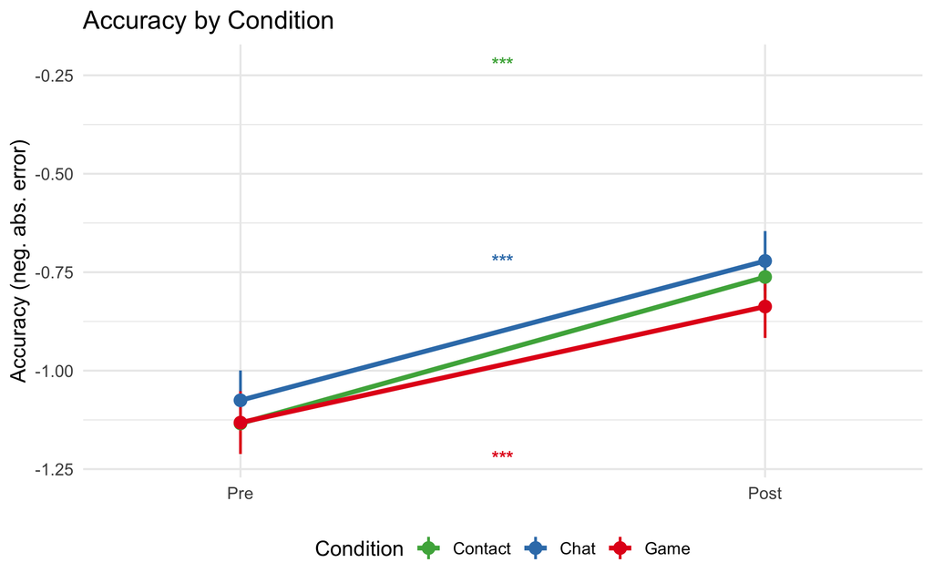

Accuracy (negative absolute error) by condition and time. Points show estimated marginal means ± SE from the mixed-effects model.

```r
emm_acc_tbl <- as_tibble(emm_acc_by_cond) %>%
  mutate(time = factor(time, levels = c("pre", "post")))

p_acc <- ggplot(emm_acc_tbl,
                aes(x = time, y = emmean, group = treatment, color = treatment)) +
  geom_line(linewidth = 1.4) +
  geom_pointrange(aes(ymin = emmean - SE, ymax = emmean + SE), size = 0.6, linewidth = 0.8) +
  # Significance stars per condition (spaced by row index)
  geom_text(data = acc_contrasts %>%
              mutate(
                x = 1.5,
                y = max(emm_acc_tbl$emmean) + 0.5,
                label = p_to_stars(p.value),
                y_offset = (row_number() - 1) * -0.5
              ),
            aes(x = x, y = y + y_offset, label = label, color = treatment),
            size = 4, fontface = "bold", show.legend = FALSE, inherit.aes = FALSE) +
  scale_color_manual(values = condition_colors, name = "Condition") +
  scale_x_discrete(labels = c("Pre", "Post"), expand = expansion(add = 0.3)) +
  labs(y = "Accuracy (neg. abs. error)", x = NULL, title = "Accuracy by Condition") +
  theme_minimal(base_size = 13) +
  theme(legend.position = "bottom")

p_acc
```

```r
ggsave(paste0(fig_path, "accuracy_by_condition.png"), p_acc, width = 8, height = 5, dpi = 300)
```

### Warmth

```r
warmth_long <- dat %>%
  select(ResponseId, treatment, learner_party, warmth_outgroup_pre, warmth_outgroup_post) %>%
  pivot_longer(c(warmth_outgroup_pre, warmth_outgroup_post),
               names_to = "time", names_pattern = "warmth_outgroup_(pre|post)",
               values_to = "warmth") %>%
  mutate(time = factor(time, levels = c("pre", "post")))

m_warm <- lmer(warmth ~ time * treatment + (1 | ResponseId), data = warmth_long)

emm_warm_by_cond <- emmeans(m_warm, ~ time | treatment)
warm_contrasts <- contrast(emm_warm_by_cond, "revpairwise", by = "treatment") %>%
  as_tibble()

emm_warm_full <- emmeans(m_warm, ~ time * treatment)

if (pool_controls) {
  warm_did <- contrast(emm_warm_full, list(
    `Contact vs. Control` = c(1, -1, -1, 1)
  ))
  warm_did_tbl <- warm_did %>% as_tibble() %>% mutate(estimate = -estimate)
  warm_main_b  <- pull_did(warm_did_tbl, "Contact vs. Control", estimate)
  warm_main_se <- pull_did(warm_did_tbl, "Contact vs. Control", SE)
  warm_main_p  <- pull_did(warm_did_tbl, "Contact vs. Control", p.value)
  warm_chat_vs_contact_b <- NA_real_; warm_chat_vs_contact_p <- NA_real_
  warm_game_vs_contact_b <- NA_real_; warm_game_vs_contact_p <- NA_real_
  warm_chat_vs_game_b    <- NA_real_; warm_chat_vs_game_p    <- NA_real_
} else {
  warm_did <- contrast(emm_warm_full, list(
    `Contact vs. pooled controls` = c(-1,  1,  0.5, -0.5,  0.5, -0.5),
    `Chat vs. Contact`            = c( 1, -1, -1,    1,    0,    0  ),
    `Game vs. Contact`            = c( 1, -1,  0,    0,   -1,    1  ),
    `Chat vs. Game`               = c( 0,  0, -1,    1,    1,   -1  )
  ))
  warm_did_tbl           <- warm_did %>% as_tibble()
  warm_main_b            <- pull_did(warm_did_tbl, "Contact vs. pooled controls", estimate)
  warm_main_se           <- pull_did(warm_did_tbl, "Contact vs. pooled controls", SE)
  warm_main_p            <- pull_did(warm_did_tbl, "Contact vs. pooled controls", p.value)
  warm_chat_vs_contact_b <- pull_did(warm_did_tbl, "Chat vs. Contact", estimate)
  warm_chat_vs_contact_p <- pull_did(warm_did_tbl, "Chat vs. Contact", p.value)
  warm_game_vs_contact_b <- pull_did(warm_did_tbl, "Game vs. Contact", estimate)
  warm_game_vs_contact_p <- pull_did(warm_did_tbl, "Game vs. Contact", p.value)
  warm_chat_vs_game_b    <- pull_did(warm_did_tbl, "Chat vs. Game",    estimate)
  warm_chat_vs_game_p    <- pull_did(warm_did_tbl, "Chat vs. Game",    p.value)
}
```

```r
warm_contrasts %>%
  select(Condition = treatment,
         `Pre→Post Improvement` = estimate,
         SE, df, `t-ratio` = t.ratio, `p-value` = p.value) %>%
  mutate(
    `Pre→Post Improvement` = numformat(`Pre→Post Improvement`),
    SE = numformat(SE),
    df = numformat(df, 0),
    `t-ratio` = numformat(`t-ratio`),
    `p-value` = map_chr(`p-value`, pformat)
  ) %>%
  gt() %>%
  tab_header(title = "Warmth: Pre-Post Improvement by Condition") %>%
  tab_footnote("Positive = increase in outgroup warmth. Estimated from mixed-effects model.",
               locations = cells_title())
```

Warmth: Pre-Post Improvement by Condition<sup>1</sup>

| Condition | Pre→Post Improvement | SE | df | t-ratio | p-value |
| --- | --- | --- | --- | --- | --- |
| Contact | 2.35 | 0.58 | 378 | 4.07 | < .001 |
| Chat | 0.41 | 0.83 | 378 | 0.49 | = 0.624 |
| Game | 2.02 | 0.87 | 378 | 2.32 | = 0.021 |

<sup>1</sup> Positive = increase in outgroup warmth. Estimated from mixed-effects model.

**Primary test:** Contact vs. pooled controls: *b* = 1.13, SE = 0.83, *p* = 0.174. **Pairwise:** Chat vs. Contact (*b* = -1.94, *p* = 0.055); Game vs. Contact (*b* = -0.33, *p* = 0.755); Chat vs. Game (*b* = -1.62, *p* = 0.179).

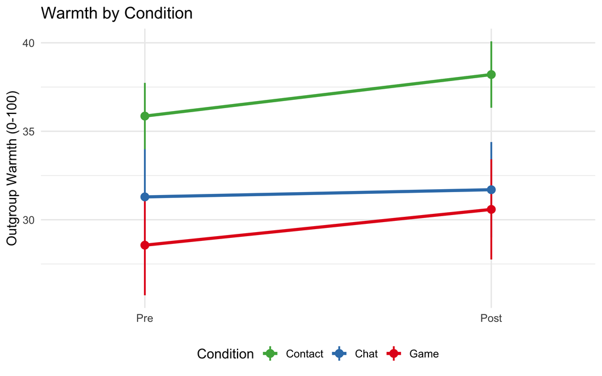

Outgroup warmth (0-100) by condition and time. Points show estimated marginal means ± SE.

```r
emm_warm_tbl <- as_tibble(emm_warm_by_cond) %>%
  mutate(time = factor(time, levels = c("pre", "post")))

p_warm <- ggplot(emm_warm_tbl,
                 aes(x = time, y = emmean, group = treatment, color = treatment)) +
  geom_line(linewidth = 1.4) +
  geom_pointrange(aes(ymin = emmean - SE, ymax = emmean + SE), size = 0.6, linewidth = 0.8) +
  scale_color_manual(values = condition_colors, name = "Condition") +
  scale_x_discrete(labels = c("Pre", "Post"), expand = expansion(add = 0.3)) +
  labs(y = "Outgroup Warmth (0-100)", x = NULL, title = "Warmth by Condition") +
  theme_minimal(base_size = 13) +
  theme(legend.position = "bottom")

p_warm
```

```r
ggsave(paste0(fig_path, "warmth_by_condition.png"), p_warm, width = 8, height = 5, dpi = 300)
```

### Confidence

```r
confidence_long <- dat %>%
  select(ResponseId, treatment, learner_party, confidence_outgroup_pre, confidence_outgroup_post) %>%
  pivot_longer(c(confidence_outgroup_pre, confidence_outgroup_post),
               names_to = "time", names_pattern = "confidence_outgroup_(pre|post)",
               values_to = "confidence") %>%
  mutate(time = factor(time, levels = c("pre", "post")))

m_conf <- lmer(confidence ~ time * treatment + (1 | ResponseId), data = confidence_long)

emm_conf_by_cond <- emmeans(m_conf, ~ time | treatment)
conf_contrasts <- contrast(emm_conf_by_cond, "revpairwise", by = "treatment") %>%
  as_tibble()

emm_conf_full <- emmeans(m_conf, ~ time * treatment)

if (pool_controls) {
  conf_did <- contrast(emm_conf_full, list(
    `Contact vs. Control` = c(1, -1, -1, 1)
  ))
  conf_did_tbl <- conf_did %>% as_tibble() %>% mutate(estimate = -estimate)
  conf_main_b  <- pull_did(conf_did_tbl, "Contact vs. Control", estimate)
  conf_main_se <- pull_did(conf_did_tbl, "Contact vs. Control", SE)
  conf_main_p  <- pull_did(conf_did_tbl, "Contact vs. Control", p.value)
  conf_chat_vs_contact_b <- NA_real_; conf_chat_vs_contact_p <- NA_real_
  conf_game_vs_contact_b <- NA_real_; conf_game_vs_contact_p <- NA_real_
  conf_chat_vs_game_b    <- NA_real_; conf_chat_vs_game_p    <- NA_real_
} else {
  conf_did <- contrast(emm_conf_full, list(
    `Contact vs. pooled controls` = c(-1,  1,  0.5, -0.5,  0.5, -0.5),
    `Chat vs. Contact`            = c( 1, -1, -1,    1,    0,    0  ),
    `Game vs. Contact`            = c( 1, -1,  0,    0,   -1,    1  ),
    `Chat vs. Game`               = c( 0,  0, -1,    1,    1,   -1  )
  ))
  conf_did_tbl           <- conf_did %>% as_tibble()
  conf_main_b            <- pull_did(conf_did_tbl, "Contact vs. pooled controls", estimate)
  conf_main_se           <- pull_did(conf_did_tbl, "Contact vs. pooled controls", SE)
  conf_main_p            <- pull_did(conf_did_tbl, "Contact vs. pooled controls", p.value)
  conf_chat_vs_contact_b <- pull_did(conf_did_tbl, "Chat vs. Contact", estimate)
  conf_chat_vs_contact_p <- pull_did(conf_did_tbl, "Chat vs. Contact", p.value)
  conf_game_vs_contact_b <- pull_did(conf_did_tbl, "Game vs. Contact", estimate)
  conf_game_vs_contact_p <- pull_did(conf_did_tbl, "Game vs. Contact", p.value)
  conf_chat_vs_game_b    <- pull_did(conf_did_tbl, "Chat vs. Game",    estimate)
  conf_chat_vs_game_p    <- pull_did(conf_did_tbl, "Chat vs. Game",    p.value)
}
```

```r
conf_contrasts %>%
  select(Condition = treatment,
         `Pre→Post Change` = estimate,
         SE, df, `t-ratio` = t.ratio, `p-value` = p.value) %>%
  mutate(
    `Pre→Post Change` = numformat(`Pre→Post Change`),
    SE = numformat(SE),
    df = numformat(df, 0),
    `t-ratio` = numformat(`t-ratio`),
    `p-value` = map_chr(`p-value`, pformat)
  ) %>%
  gt() %>%
  tab_header(title = "Confidence: Pre-Post Change by Condition") %>%
  tab_footnote("Positive = increase in confidence. Estimated from mixed-effects model.",
               locations = cells_title())
```

Confidence: Pre-Post Change by Condition<sup>1</sup>

| Condition | Pre→Post Change | SE | df | t-ratio | p-value |
| --- | --- | --- | --- | --- | --- |
| Contact | 0.39 | 0.07 | 378 | 5.21 | < .001 |
| Chat | 0.21 | 0.11 | 378 | 1.94 | = 0.053 |
| Game | 0.06 | 0.11 | 378 | 0.51 | = 0.610 |

<sup>1</sup> Positive = increase in confidence. Estimated from mixed-effects model.

**Primary test:** Contact vs. pooled controls: *b* = 0.26, SE = 0.11, *p* = 0.018. **Pairwise:** Chat vs. Contact (*b* = -0.18, *p* = 0.168); Game vs. Contact (*b* = -0.33, *p* = 0.015); Chat vs. Game (*b* = 0.15, *p* = 0.333).

## Behavioral Outcomes by Condition

### Dictator Game Donation

```r
dat <- dat %>% mutate(donated_any = as.integer(donation > 0))

don_by_condition <- dat %>%
  group_by(treatment) %>%
  summarise(
    N          = n(),
    M          = mean(donation, na.rm = TRUE),
    SD         = sd(donation, na.rm = TRUE),
    SE         = SD / sqrt(N),
    pct_donated = mean(donated_any) * 100,
    mean_pos   = mean(donation[donation > 0], na.rm = TRUE),
    .groups = "drop"
  )

# Continuous donation: overall ANOVA + Tukey pairwise
don_aov <- aov(donation ~ treatment, data = dat)
don_aov_p <- summary(don_aov)[[1]][["Pr(>F)"]][1]
don_aov_f <- summary(don_aov)[[1]][["F value"]][1]
don_pairwise <- dat %>% tukey_hsd(donation ~ treatment)

extract_tukey <- function(tbl, g1, g2) {
  tbl %>% filter(group1 == g1, group2 == g2)
}

# Stage 1 (any donation): overall ANOVA + Tukey pairwise
don_aov_bin <- aov(donated_any ~ treatment, data = dat)
don_aov_bin_p <- summary(don_aov_bin)[[1]][["Pr(>F)"]][1]
don_aov_bin_f <- summary(don_aov_bin)[[1]][["F value"]][1]
don_pairwise_bin <- dat %>% tukey_hsd(donated_any ~ treatment)

# Stage 2 (amount among donors): ANOVA
dat_donors <- dat %>% filter(donated_any == 1)
don_aov_pos <- aov(donation ~ treatment, data = dat_donors)
don_aov_pos_p <- summary(don_aov_pos)[[1]][["Pr(>F)"]][1]
don_aov_pos_f <- summary(don_aov_pos)[[1]][["F value"]][1]

# Condition-specific pairwise (only meaningful when 3 conditions)
if (!pool_controls) {
  don_cont_chat_game     <- extract_tukey(don_pairwise,     "Chat", "Game")
  don_bin_contact_chat_p <- extract_tukey(don_pairwise_bin, "Contact", "Chat")$p.adj
  don_bin_contact_game_p <- extract_tukey(don_pairwise_bin, "Contact", "Game")$p.adj
  don_bin_chat_game_p    <- extract_tukey(don_pairwise_bin, "Chat",    "Game")$p.adj
} else {
  don_cont_chat_game     <- tibble(p.adj = NA_real_)
  don_bin_contact_chat_p <- NA_real_
  don_bin_contact_game_p <- extract_tukey(don_pairwise_bin, "Contact", "Control")$p.adj
  don_bin_chat_game_p    <- NA_real_
}
```

```r
don_by_condition %>%
  mutate(across(c(M, SD, SE, mean_pos), numformat),
         pct_donated = numformat(pct_donated, 0)) %>%
  select(Condition = treatment, N,
         `% Donated` = pct_donated,
         `Mean (all)` = M, SD,
         `Mean (donors only)` = mean_pos) %>%
  gt() %>%
  tab_header(title = "Dictator Game: Donation by Condition") %>%
  tab_footnote("% Donated = proportion who gave any amount > 0. Mean (donors only) excludes zeros.",
               locations = cells_title())
```

Dictator Game: Donation by Condition<sup>1</sup>

| Condition | N | % Donated | Mean (all) | SD | Mean (donors only) |
| --- | --- | --- | --- | --- | --- |
| Contact | 198 | 56 | 20.13 | 21.40 | 36.23 |
| Chat | 96 | 56 | 22.07 | 22.41 | 39.24 |
| Game | 87 | 53 | 18.08 | 20.76 | 34.20 |

<sup>1</sup> % Donated = proportion who gave any amount > 0. Mean (donors only) excludes zeros.

```r
bind_rows(
  don_pairwise %>% select(group1, group2, estimate, p.adj) %>% mutate(DV = "Continuous (0-50¢)"),
  don_pairwise_bin %>% select(group1, group2, estimate, p.adj) %>% mutate(DV = "Any donation (0/1)")
) %>%
  mutate(
    Comparison = paste0(group1, " vs. ", group2),
    estimate = numformat(estimate),
    p.adj = map_chr(p.adj, pformat)
  ) %>%
  select(DV, Comparison, `Difference` = estimate, `p (Tukey)` = p.adj) %>%
  gt() %>%
  tab_header(title = "Pairwise Tukey Comparisons: Donation") %>%
  tab_footnote("Tukey-corrected p-values.", locations = cells_title())
```

Pairwise Tukey Comparisons: Donation<sup>1</sup>

| DV | Comparison | Difference | p (Tukey) |
| --- | --- | --- | --- |
| Continuous (0-50¢) | Contact vs. Chat | 1.95 | = 0.747 |
| Continuous (0-50¢) | Contact vs. Game | -2.05 | = 0.740 |
| Continuous (0-50¢) | Chat vs. Game | -3.99 | = 0.422 |
| Any donation (0/1) | Contact vs. Chat | 0.01 | = 0.993 |
| Any donation (0/1) | Contact vs. Game | -0.03 | = 0.908 |
| Any donation (0/1) | Chat vs. Game | -0.03 | = 0.891 |

<sup>1</sup> Tukey-corrected p-values.

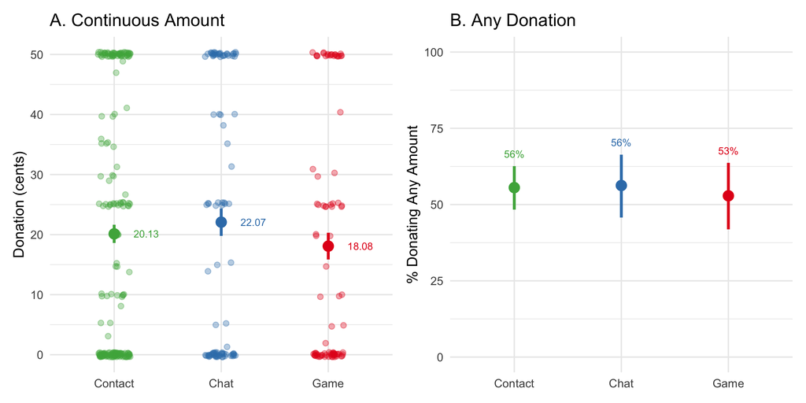

Left: Dictator game donation (0-50 cents) by condition — individual points, mean ± SE. Right: Proportion donating any amount.

```r
p_don_cont <- ggplot(dat, aes(x = treatment, y = donation, color = treatment)) +
  geom_jitter(width = 0.15, alpha = 0.35, size = 2) +
  geom_pointrange(data = don_by_condition,
                  aes(x = treatment, y = M, ymin = M - SE, ymax = M + SE),
                  size = 0.8, linewidth = 1.2, inherit.aes = FALSE,
                  color = condition_colors[as.character(don_by_condition$treatment)]) +
  geom_text(data = don_by_condition,
            aes(x = treatment, y = M, label = numformat(M)),
            nudge_x = 0.3, size = 3.2, show.legend = FALSE,
            color = condition_colors[as.character(don_by_condition$treatment)]) +
  scale_color_manual(values = condition_colors) +
  labs(y = "Donation (cents)", x = NULL, title = "A. Continuous Amount") +
  theme_minimal(base_size = 13) +
  theme(legend.position = "none")

# % donated panel with 95% CI
don_bin_ci <- don_by_condition %>%
  mutate(
    n_donated = round(pct_donated / 100 * N),
    ci_lo = map2_dbl(n_donated, N, ~ binom.test(.x, .y)$conf.int[1] * 100),
    ci_hi = map2_dbl(n_donated, N, ~ binom.test(.x, .y)$conf.int[2] * 100)
  )

p_don_bin <- ggplot(don_bin_ci, aes(x = treatment, y = pct_donated, color = treatment)) +
  geom_pointrange(aes(ymin = ci_lo, ymax = ci_hi), size = 0.8, linewidth = 1.2) +
  geom_text(aes(y = ci_hi + 4, label = paste0(round(pct_donated), "%")),
            size = 3.2, show.legend = FALSE) +
  scale_color_manual(values = condition_colors) +
  scale_y_continuous(limits = c(0, 100), breaks = seq(0, 100, 25)) +
  labs(y = "% Donating Any Amount", x = NULL, title = "B. Any Donation") +
  theme_minimal(base_size = 13) +
  theme(legend.position = "none")

p_don <- p_don_cont + p_don_bin
p_don
```

```r
ggsave(paste0(fig_path, "donation_by_condition.png"), p_don, width = 10, height = 5, dpi = 300)
```

### Talk Partner Preference

```r
dat <- dat %>%
  mutate(
    chose_outgroup = case_when(
      participant_party == "Democrat"   & talk_partner == "I'd rather talk with a republican" ~ 1,
      participant_party == "Republican" & talk_partner == "I'd rather talk with a democrat"   ~ 1,
      TRUE ~ 0
    )
  )

talk_by_condition <- dat %>%
  group_by(treatment) %>%
  summarise(
    n_total      = n(),
    n_outgroup   = sum(chose_outgroup, na.rm = TRUE),
    pct_outgroup = n_outgroup / n_total * 100,
    ci_lo = binom.test(n_outgroup, n_total)$conf.int[1] * 100,
    ci_hi = binom.test(n_outgroup, n_total)$conf.int[2] * 100,
    .groups = "drop"
  )

# Overall chi-square
talk_tab <- table(dat$treatment, dat$chose_outgroup)
talk_chisq <- chisq.test(talk_tab)

# Pairwise Fisher's exact tests (only when 3 conditions exist)
if (!pool_controls) {
  fish_contact_chat <- fisher.test(talk_tab[c("Contact", "Chat"), ])
  fish_contact_game <- fisher.test(talk_tab[c("Contact", "Game"), ])
  fish_chat_game    <- fisher.test(talk_tab[c("Chat",    "Game"), ])
} else {
  fish_contact_chat <- list(p.value = NA_real_, estimate = NA_real_)
  fish_contact_game <- fisher.test(talk_tab[c("Contact", "Control"), ])
  fish_chat_game    <- list(p.value = NA_real_, estimate = NA_real_)
}
```

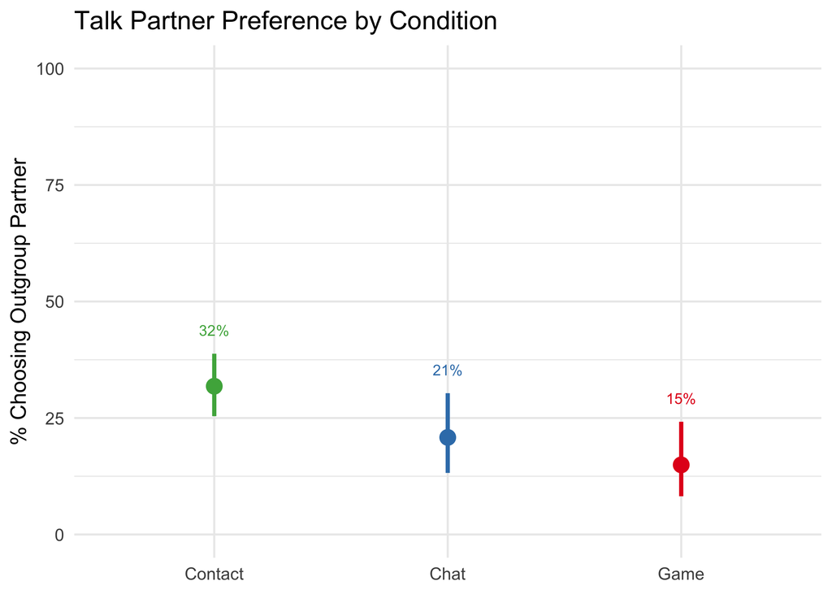

Proportion choosing to talk with an outgroup member by condition. Error bars show 95% CI.

```r
p_talk <- ggplot(talk_by_condition,
                 aes(x = treatment, y = pct_outgroup, color = treatment)) +
  geom_pointrange(aes(ymin = ci_lo, ymax = ci_hi), size = 0.8, linewidth = 1.2) +
  geom_text(aes(y = ci_hi + 5, label = paste0(round(pct_outgroup), "%")),
            size = 3.2, show.legend = FALSE) +
  scale_color_manual(values = condition_colors) +
  scale_y_continuous(limits = c(0, 100), breaks = seq(0, 100, 25)) +
  labs(y = "% Choosing Outgroup Partner", x = NULL,
       title = "Talk Partner Preference by Condition") +
  theme_minimal(base_size = 13) +
  theme(legend.position = "none")

p_talk
```

```r
ggsave(paste0(fig_path, "talk_partner_by_condition.png"), p_talk, width = 7, height = 5, dpi = 300)
```

The overall chi-square test for condition differences in outgroup partner preference: *χ²* = 10.43, *p* = 0.005. Pairwise Fisher’s exact tests show that the effect was driven by **Game vs. Contact**: Game participants chose the outgroup partner far less often (15%) than Contact participants (32%), OR = 0.38, *p* = 0.003. Contact vs. Chat did not differ significantly (*p* = 0.054), nor did Chat vs. Game (*p* = 0.340).

## Combined Improvement Figure

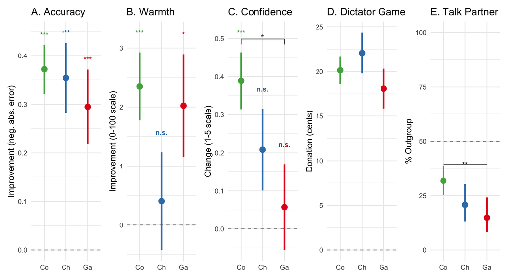

Pre-post improvement by condition across all outcomes. Error bars show ± SE. Stars above points indicate within-condition improvement vs. zero. Brackets show between-condition DiD contrasts (lmer) for pre-post outcomes; Tukey HSD for donation and Fisher exact for talk partner.

```r
# Abbreviated x-axis labels
x_labels <- if (pool_controls) {
  c("Contact" = "Co", "Control" = "Ctrl")
} else {
  c("Contact" = "Co", "Chat" = "Ch", "Game" = "Ga")
}

# Between-condition pairwise p-values from DiD contrasts
# Returns a tibble: group1, group2, p (numeric positions 1/2/3 on x-axis)
pairwise_did <- function(did_tbl) {
  if (pool_controls) {
    tibble(
      x1 = 1, x2 = 2,
      p  = pull_did(did_tbl, "Contact vs. Control", p.value)
    )
  } else {
    tibble(
      x1 = c(1, 1, 2),
      x2 = c(2, 3, 3),
      p  = c(
        pull_did(did_tbl, "Chat vs. Contact", p.value),
        pull_did(did_tbl, "Game vs. Contact", p.value),
        pull_did(did_tbl, "Chat vs. Game",    p.value)
      )
    )
  }
}

# Add significance brackets as annotation layers
# yrange: the observed (ymin, ymax) range of the pointranges
add_brackets <- function(pairs, ymax_data, y_scale = 1) {
  sig <- pairs %>% filter(p < .05) %>% mutate(stars = p_to_stars(p))
  if (nrow(sig) == 0) return(list())
  # Stack brackets above data
  bracket_gap  <- diff(range(ymax_data)) * 0.12 * y_scale
  bracket_step <- diff(range(ymax_data)) * 0.18 * y_scale
  top0 <- max(ymax_data) + bracket_gap
  layers <- list()
  for (i in seq_len(nrow(sig))) {
    row  <- sig[i, ]
    ytop <- top0 + (i - 1) * bracket_step
    # horizontal bar
    layers <- c(layers, list(
      annotate("segment", x = row$x1, xend = row$x2, y = ytop, yend = ytop,
               color = "gray30", linewidth = 0.5),
      # left tick
      annotate("segment", x = row$x1, xend = row$x1,
               y = ytop - bracket_gap * 0.4, yend = ytop,
               color = "gray30", linewidth = 0.5),
      # right tick
      annotate("segment", x = row$x2, xend = row$x2,
               y = ytop - bracket_gap * 0.4, yend = ytop,
               color = "gray30", linewidth = 0.5),
      # stars
      annotate("text", x = (row$x1 + row$x2) / 2, y = ytop + bracket_gap * 0.15,
               label = row$stars, size = 3.5, fontface = "bold", color = "gray20")
    ))
  }
  layers
}

# Base panel builder: within-condition dots + within-condition stars near point
make_panel <- function(contrasts_tbl, title, y_lab, pairs = NULL, y_scale = 1) {
  d <- contrasts_tbl %>%
    mutate(stars = p_to_stars(p.value), ymin = estimate - SE, ymax = estimate + SE)

  p <- d %>%
    ggplot(aes(x = treatment, y = estimate, color = treatment)) +
    geom_hline(yintercept = 0, linetype = "dashed", color = "gray50") +
    geom_pointrange(aes(ymin = ymin, ymax = ymax), size = 0.7, linewidth = 1.1) +
    geom_text(aes(y = ymax + diff(range(c(ymin, ymax))) * 0.10,
                  label = stars),
              size = 3.5, fontface = "bold", show.legend = FALSE) +
    scale_color_manual(values = condition_colors) +
    scale_x_discrete(labels = x_labels) +
    labs(x = NULL, y = y_lab, title = title) +
    theme_minimal(base_size = 12) +
    theme(legend.position = "none")

  if (!is.null(pairs)) {
    brks <- add_brackets(pairs, d$ymax, y_scale)
    for (lyr in brks) p <- p + lyr
  }
  p
}

acc_pairs  <- pairwise_did(acc_did_tbl)
warm_pairs <- pairwise_did(warm_did_tbl)
conf_pairs <- pairwise_did(conf_did_tbl)

pa <- make_panel(acc_contrasts,  "A. Accuracy",   "Improvement (neg. abs. error)", acc_pairs)
pb <- make_panel(warm_contrasts, "B. Warmth",     "Improvement (0-100 scale)",     warm_pairs)
pc <- make_panel(conf_contrasts, "C. Confidence", "Change (1-5 scale)",            conf_pairs)

# Donation panel: Tukey pairwise between conditions
don_pairs <- if (pool_controls) {
  tibble(x1 = 1, x2 = 2,
         p  = extract_tukey(don_pairwise, "Contact", "Control")$p.adj)
} else {
  tibble(
    x1 = c(1, 1, 2),
    x2 = c(2, 3, 3),
    p  = c(
      extract_tukey(don_pairwise, "Contact", "Chat")$p.adj,
      extract_tukey(don_pairwise, "Contact", "Game")$p.adj,
      extract_tukey(don_pairwise, "Chat",    "Game")$p.adj
    )
  )
}

don_d <- don_by_condition %>% mutate(ymin = M - SE, ymax = M + SE)
pd <- ggplot(don_d, aes(x = treatment, y = M, color = treatment)) +
  geom_hline(yintercept = 0, linetype = "dashed", color = "gray50") +
  geom_pointrange(aes(ymin = ymin, ymax = ymax), size = 0.7, linewidth = 1.1) +
  scale_color_manual(values = condition_colors) +
  scale_x_discrete(labels = x_labels) +
  labs(x = NULL, y = "Donation (cents)", title = "D. Dictator Game") +
  theme_minimal(base_size = 12) +
  theme(legend.position = "none")
for (lyr in add_brackets(don_pairs, don_d$ymax)) pd <- pd + lyr

# Talk partner panel: Fisher exact pairwise
talk_pairs <- if (pool_controls) {
  tibble(x1 = 1, x2 = 2, p = fish_contact_game$p.value)
} else {
  tibble(
    x1 = c(1, 1, 2),
    x2 = c(2, 3, 3),
    p  = c(fish_contact_chat$p.value, fish_contact_game$p.value, fish_chat_game$p.value)
  )
}

talk_d <- talk_by_condition %>% mutate(ymin = ci_lo, ymax = ci_hi)
pe <- ggplot(talk_d, aes(x = treatment, y = pct_outgroup, color = treatment)) +
  geom_hline(yintercept = 50, linetype = "dashed", color = "gray50") +
  geom_pointrange(aes(ymin = ymin, ymax = ymax), size = 0.7, linewidth = 1.1) +
  scale_color_manual(values = condition_colors) +
  scale_x_discrete(labels = x_labels) +
  scale_y_continuous(limits = c(0, 100)) +
  labs(x = NULL, y = "% Outgroup", title = "E. Talk Partner") +
  theme_minimal(base_size = 12) +
  theme(legend.position = "none")
for (lyr in add_brackets(talk_pairs, talk_d$ymax, y_scale = 0.3)) pe <- pe + lyr

p_combined <- pa + pb + pc + pd + pe + plot_layout(ncol = 5)
ggsave(paste0(fig_path, "combined_by_condition.png"), p_combined, width = 14, height = 5.5, dpi = 300)
p_combined
```

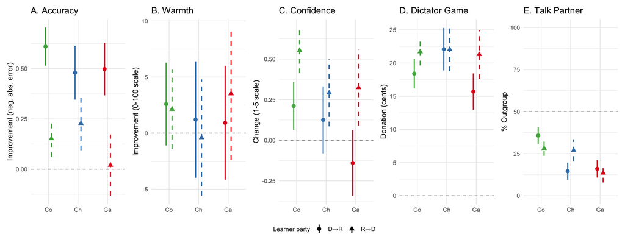

Pre-post improvement by condition and learner party (D→R = Democrats learning about Republicans; R→D = Republicans learning about Democrats). Points are offset by party; linetype distinguishes parties. Error bars show ± SE.

```r
# ── Fit 3-way models for each DV ──────────────────────────────────────────────
m_acc_3way_cf  <- lmer(accuracy    ~ time * treatment * learner_party + (1 | ResponseId),
                        data = accuracy_long, REML = FALSE)
m_warm_3way_cf <- lmer(warmth      ~ time * treatment * learner_party + (1 | ResponseId),
                        data = warmth_long,   REML = FALSE)
m_conf_3way_cf <- lmer(confidence  ~ time * treatment * learner_party + (1 | ResponseId),
                        data = confidence_long, REML = FALSE)

# ── Extract DiD by party: post - pre emmean per condition × party ─────────────
party_did <- function(model, dv_label, y_label) {
  emm <- emmeans(model, ~ time | treatment * learner_party) %>%
    as_tibble() %>%
    select(treatment, learner_party, time, emmean, SE)

  did <- emm %>%
    pivot_wider(names_from = time, values_from = c(emmean, SE),
                id_cols = c(treatment, learner_party)) %>%
    mutate(
      estimate = emmean_post - emmean_pre,
      SE       = sqrt(SE_pre^2 + SE_post^2),
      ymin     = estimate - SE,
      ymax     = estimate + SE
    )

  dodge <- position_dodge(width = 0.4)

  ggplot(did, aes(x = treatment, y = estimate,
                  color = treatment, linetype = learner_party,
                  shape = learner_party, group = learner_party)) +
    geom_hline(yintercept = 0, linetype = "dashed", color = "gray50") +
    geom_pointrange(aes(ymin = ymin, ymax = ymax),
                    size = 0.6, linewidth = 0.9,
                    position = dodge) +
    scale_color_manual(values = condition_colors) +
    scale_linetype_manual(values = c("D→R" = "solid", "R→D" = "dashed"),
                          name = "Learner party") +
    scale_shape_manual(values = c("D→R" = 16, "R→D" = 17),
                       name = "Learner party") +
    scale_x_discrete(labels = x_labels) +
    guides(color = "none") +
    labs(x = NULL, y = y_label, title = dv_label) +
    theme_minimal(base_size = 12) +
    theme(legend.position = "bottom",
          legend.title = element_text(size = 10))
}

pa_p <- party_did(m_acc_3way_cf,  "A. Accuracy",   "Improvement (neg. abs. error)")
pb_p <- party_did(m_warm_3way_cf, "B. Warmth",     "Improvement (0-100 scale)")
pc_p <- party_did(m_conf_3way_cf, "C. Confidence", "Change (1-5 scale)")

# ── Donation by party: use raw means (no lmer for binary-ish DV) ────────────
don_party <- dat %>%
  group_by(treatment, learner_party) %>%
  summarise(M  = mean(donation, na.rm = TRUE),
            SE = sd(donation,   na.rm = TRUE) / sqrt(n()),
            .groups = "drop") %>%
  mutate(ymin = M - SE, ymax = M + SE)

dodge <- position_dodge(width = 0.4)

pd_p <- ggplot(don_party, aes(x = treatment, y = M,
                               color = treatment, linetype = learner_party,
                               shape = learner_party, group = learner_party)) +
  geom_hline(yintercept = 0, linetype = "dashed", color = "gray50") +
  geom_pointrange(aes(ymin = ymin, ymax = ymax),
                  size = 0.6, linewidth = 0.9,
                  position = dodge) +
  scale_color_manual(values = condition_colors) +
  scale_linetype_manual(values = c("D→R" = "solid", "R→D" = "dashed"),
                        name = "Learner party") +
  scale_shape_manual(values = c("D→R" = 16, "R→D" = 17),
                     name = "Learner party") +
  scale_x_discrete(labels = x_labels) +
  guides(color = "none") +
  labs(x = NULL, y = "Donation (cents)", title = "D. Dictator Game") +
  theme_minimal(base_size = 12) +
  theme(legend.position = "bottom",
        legend.title = element_text(size = 10))

# ── Talk partner by party ────────────────────────────────────────────────────
talk_party <- dat %>%
  group_by(treatment, learner_party) %>%
  summarise(
    n_out = sum(chose_outgroup == 1, na.rm = TRUE),
    n     = sum(!is.na(chose_outgroup)),
    .groups = "drop"
  ) %>%
  mutate(
    pct_outgroup = 100 * n_out / n,
    SE           = 100 * sqrt(pct_outgroup/100 * (1 - pct_outgroup/100) / n),
    ymin         = pmax(0,   pct_outgroup - SE),
    ymax         = pmin(100, pct_outgroup + SE)
  )

pe_p <- ggplot(talk_party, aes(x = treatment, y = pct_outgroup,
                                color = treatment, linetype = learner_party,
                                shape = learner_party, group = learner_party)) +
  geom_hline(yintercept = 50, linetype = "dashed", color = "gray50") +
  geom_pointrange(aes(ymin = ymin, ymax = ymax),
                  size = 0.6, linewidth = 0.9,
                  position = dodge) +
  scale_color_manual(values = condition_colors) +
  scale_linetype_manual(values = c("D→R" = "solid", "R→D" = "dashed"),
                        name = "Learner party") +
  scale_shape_manual(values = c("D→R" = 16, "R→D" = 17),
                     name = "Learner party") +
  scale_x_discrete(labels = x_labels) +
  scale_y_continuous(limits = c(0, 100)) +
  guides(color = "none") +
  labs(x = NULL, y = "% Outgroup", title = "E. Talk Partner") +
  theme_minimal(base_size = 12) +
  theme(legend.position = "bottom",
        legend.title = element_text(size = 10))

p_combined_party <- pa_p + pb_p + pc_p + pd_p + pe_p +
  plot_layout(ncol = 5, guides = "collect") &
  theme(legend.position = "bottom")

ggsave(paste0(fig_path, "combined_by_condition_party.png"),
       p_combined_party, width = 14, height = 6, dpi = 300)
p_combined_party
```

## Moderating Role of Party

We also check whether the condition effects are moderated by learner party (D→R vs R→D).

```r
# 3-way: time × treatment × party
accuracy_long_party <- accuracy_long

m_acc_3way <- lmer(accuracy ~ time * treatment * learner_party + (1 | ResponseId),
                   data = accuracy_long_party, REML = FALSE)
m_acc_2way <- lmer(accuracy ~ time * treatment + time * learner_party +
                     treatment * learner_party + (1 | ResponseId),
                   data = accuracy_long_party, REML = FALSE)

lrt_acc <- anova(m_acc_2way, m_acc_3way)
lrt_acc_p <- lrt_acc$`Pr(>Chisq)`[2]

# Warmth 3-way
warmth_long_party <- warmth_long
m_warm_3way <- lmer(warmth ~ time * treatment * learner_party + (1 | ResponseId),
                    data = warmth_long_party, REML = FALSE)
m_warm_2way <- lmer(warmth ~ time * treatment + time * learner_party +
                      treatment * learner_party + (1 | ResponseId),
                    data = warmth_long_party, REML = FALSE)
lrt_warm <- anova(m_warm_2way, m_warm_3way)
lrt_warm_p <- lrt_warm$`Pr(>Chisq)`[2]
```

A likelihood ratio test found that party did not significantly moderate the condition × time interaction for accuracy (*p* = 0.415) and did not significantly moderate it for warmth (*p* = 0.192).

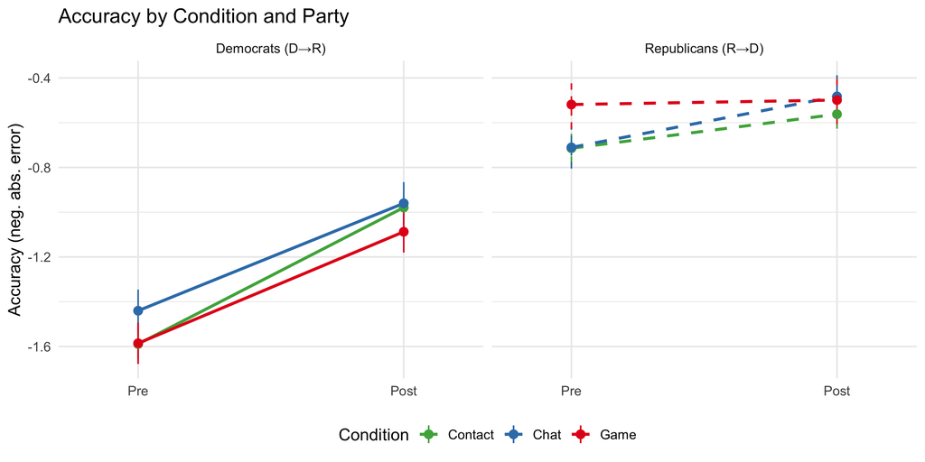

Estimated marginal means for accuracy by condition and learner party.

```r
emm_acc_party <- emmeans(m_acc_3way, ~ time | treatment * learner_party) %>%
  as_tibble() %>%
  mutate(time = factor(time, levels = c("pre", "post")))

ggplot(emm_acc_party,
       aes(x = time, y = emmean, group = interaction(treatment, learner_party),
           color = treatment, linetype = learner_party)) +
  geom_line(linewidth = 1.1) +
  geom_pointrange(aes(ymin = emmean - SE, ymax = emmean + SE), size = 0.5) +
  facet_wrap(~ learner_party, labeller = labeller(learner_party = c("D→R" = "Democrats (D→R)", "R→D" = "Republicans (R→D)"))) +
  scale_color_manual(values = condition_colors, name = "Condition") +
  scale_linetype_manual(values = c("D→R" = "solid", "R→D" = "dashed"), guide = "none") +
  scale_x_discrete(labels = c("Pre", "Post"), expand = expansion(add = 0.3)) +
  labs(y = "Accuracy (neg. abs. error)", x = NULL,
       title = "Accuracy by Condition and Party") +
  theme_minimal(base_size = 13) +
  theme(legend.position = "bottom")
```

```r
ggsave(paste0(fig_path, "accuracy_condition_party.png"), width = 10, height = 5, dpi = 300)
```

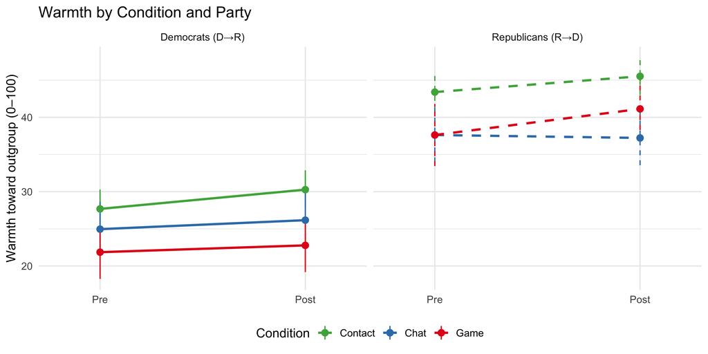

Estimated marginal means for warmth by condition and learner party.

```r
emm_warm_party <- emmeans(m_warm_3way, ~ time | treatment * learner_party) %>%
  as_tibble() %>%
  mutate(time = factor(time, levels = c("pre", "post")))

ggplot(emm_warm_party,
       aes(x = time, y = emmean, group = interaction(treatment, learner_party),
           color = treatment, linetype = learner_party)) +
  geom_line(linewidth = 1.1) +
  geom_pointrange(aes(ymin = emmean - SE, ymax = emmean + SE), size = 0.5) +
  facet_wrap(~ learner_party, labeller = labeller(learner_party = c("D→R" = "Democrats (D→R)", "R→D" = "Republicans (R→D)"))) +
  scale_color_manual(values = condition_colors, name = "Condition") +
  scale_linetype_manual(values = c("D→R" = "solid", "R→D" = "dashed"), guide = "none") +
  scale_x_discrete(labels = c("Pre", "Post"), expand = expansion(add = 0.3)) +
  labs(y = "Warmth toward outgroup (0–100)", x = NULL,
       title = "Warmth by Condition and Party") +
  theme_minimal(base_size = 13) +
  theme(legend.position = "bottom")
```

```r
ggsave(paste0(fig_path, "warmth_condition_party.png"), width = 10, height = 5, dpi = 300)
```

## Summary Table

```r
# Compute condition-level summaries for key DVs
summary_rows <- bind_rows(
  # Accuracy
  dat %>% group_by(treatment) %>%
    summarise(DV = "Accuracy",
              Pre = mean(accuracy_pre, na.rm=TRUE) %>% numformat(),
              Post = mean(accuracy_post, na.rm=TRUE) %>% numformat(),
              Change = mean(accuracy_post - accuracy_pre, na.rm=TRUE) %>% numformat(),
              .groups="drop"),
  # Warmth
  dat %>% group_by(treatment) %>%
    summarise(DV = "Outgroup Warmth",
              Pre = mean(warmth_outgroup_pre, na.rm=TRUE) %>% numformat(),
              Post = mean(warmth_outgroup_post, na.rm=TRUE) %>% numformat(),
              Change = mean(warmth_outgroup_post - warmth_outgroup_pre, na.rm=TRUE) %>% numformat(),
              .groups="drop"),
  # Confidence
  dat %>% group_by(treatment) %>%
    summarise(DV = "Confidence",
              Pre = mean(confidence_outgroup_pre, na.rm=TRUE) %>% numformat(),
              Post = mean(confidence_outgroup_post, na.rm=TRUE) %>% numformat(),
              Change = mean(confidence_outgroup_post - confidence_outgroup_pre, na.rm=TRUE) %>% numformat(),
              .groups="drop")
) %>%
  select(DV, Condition = treatment, Pre, Post, Change)

summary_rows %>%
  gt(groupname_col = "DV") %>%
  tab_header(title = "Pre-Post Changes by Condition and DV") %>%
  tab_footnote("Change = Post − Pre. Positive = improvement/increase.",
               locations = cells_title())
```

Pre-post changes by condition across all dependent variables.

Pre-Post Changes by Condition and DV<sup>1</sup>

| Condition | Pre | Post | Change |
| --- | --- | --- | --- |
| Accuracy |  |  |  |
| Contact | -1.13 | -0.76 | 0.37 |
| Chat | -1.08 | -0.72 | 0.35 |
| Game | -1.13 | -0.84 | 0.29 |
| Outgroup Warmth |  |  |  |
| Contact | 35.86 | 38.21 | 2.35 |
| Chat | 31.29 | 31.70 | 0.41 |
| Game | 28.56 | 30.59 | 2.02 |
| Confidence |  |  |  |
| Contact | 3.08 | 3.47 | 0.39 |
| Chat | 3.07 | 3.28 | 0.21 |
| Game | 3.25 | 3.31 | 0.06 |

<sup>1</sup> Change = Post − Pre. Positive = improvement/increase.

## Appendix: Simulation — lmer vs. ANCOVA Power and Bias

To understand which model better recovers a known treatment effect, we run a Monte Carlo simulation calibrated to this study’s design. We fix pre-scores to be equal across conditions (randomization holds), give the treatment condition a true post-score advantage, and ask: which model (a) recovers the true effect with less bias, and (b) detects it with higher power?

```r
set.seed(2024)

# Parameters calibrated to observed data
n_trt_sim  <- n_contact   # ~126
n_ctrl_sim <- n_total - n_contact  # non-Contact participants
n_sims     <- 2

# From observed data
pre_mean <- mean(dat$accuracy_pre, na.rm = TRUE)
pre_sd   <- sd(dat$accuracy_pre,  na.rm = TRUE)
post_sd  <- sd(dat$accuracy_post, na.rm = TRUE)

# Use average pre-post correlation across conditions (pooled or per-condition)
if (!pool_controls) {
  # Exclude Chat outlier; average Contact and Game
  rho_sim <- mean(c(
    cor(dat$accuracy_pre[dat$treatment == "Contact"],
        dat$accuracy_post[dat$treatment == "Contact"], use = "complete.obs"),
    cor(dat$accuracy_pre[dat$treatment == "Game"],
        dat$accuracy_post[dat$treatment == "Game"], use = "complete.obs")
  ))
} else {
  rho_sim <- cor(dat$accuracy_pre, dat$accuracy_post, use = "complete.obs")
}

resid_sd <- post_sd * sqrt(1 - rho_sim^2)
b_pre_sim <- rho_sim * (post_sd / pre_sd)

# True effect sizes to sweep
true_effects <- c(0, 0.1, 0.2, 0.3, 0.5)

sim_one <- function(true_delta) {
  # Pre: same in both groups
  pre_trt  <- rnorm(n_trt_sim,  pre_mean, pre_sd)
  pre_ctrl <- rnorm(n_ctrl_sim, pre_mean, pre_sd)

  # Post: true effect in treatment only
  post_trt  <- b_pre_sim * pre_trt  + true_delta + rnorm(n_trt_sim,  0, resid_sd)
  post_ctrl <- b_pre_sim * pre_ctrl +           0 + rnorm(n_ctrl_sim, 0, resid_sd)

  d <- data.frame(
    id        = seq_len(n_trt_sim + n_ctrl_sim),
    treatment = factor(c(rep("Treatment", n_trt_sim), rep("Control", n_ctrl_sim)),
                       levels = c("Control", "Treatment")),
    pre       = c(pre_trt,  pre_ctrl),
    post      = c(post_trt, post_ctrl)
  )

  # ANCOVA — unname() prevents name concatenation in replicate() matrix rownames
  anc     <- lm(post ~ pre + treatment, data = d)
  anc_est <- unname(coef(anc)["treatmentTreatment"])
  anc_p   <- unname(summary(anc)$coefficients["treatmentTreatment", "Pr(>|t|)"])

  # lmer
  d_long <- d %>%
    pivot_longer(c(pre, post), names_to = "time", values_to = "y") %>%
    mutate(time = factor(time, levels = c("pre", "post")))
  suppressMessages(
    m <- lmer(y ~ time * treatment + (1 | id), data = d_long)
  )
  emm      <- emmeans(m, ~ time * treatment)
  ctr      <- contrast(emm, list(did = c(-1, 1, 1, -1)))
  lmer_est <- unname(summary(ctr)$estimate)
  lmer_p   <- unname(summary(ctr)$p.value)

  c(anc_est = anc_est, anc_p = anc_p, lmer_est = lmer_est, lmer_p = lmer_p)
}

sim_results <- map_dfr(true_effects, function(delta) {
  # replicate returns a matrix: rows = named output elements, cols = simulations
  mat <- replicate(n_sims, sim_one(delta))  # dim: 4 x n_sims
  tibble(
    true_delta = delta,
    anc_bias   = mean(mat["anc_est", ])  - delta,
    anc_se     = sd(mat[  "anc_est", ]),
    anc_power  = mean(mat["anc_p",   ] < .05),
    lmer_bias  = mean(mat["lmer_est",]) - delta,
    lmer_se    = sd(mat[  "lmer_est",]),
    lmer_power = mean(mat["lmer_p",  ] < .05)
  )
})
```

```r
sim_results %>%
  mutate(
    across(c(anc_bias, anc_se, lmer_bias, lmer_se), ~ numformat(.x, 3)),
    anc_power  = numformat(anc_power  * 100, 1),
    lmer_power = numformat(lmer_power * 100, 1),
    true_delta = numformat(true_delta, 2)
  ) %>%
  select(
    `True effect` = true_delta,
    `ANCOVA bias` = anc_bias, `ANCOVA SE` = anc_se, `ANCOVA power (%)` = anc_power,
    `lmer bias`   = lmer_bias, `lmer SE`   = lmer_se, `lmer power (%)`   = lmer_power
  ) %>%
  gt() %>%
  tab_header(
    title    = "Simulation: ANCOVA vs. lmer — Bias, Efficiency, and Power",
    subtitle = paste0(
      "N = ", n_trt_sim, " (treatment) + ", n_ctrl_sim, " (control); ",
      "pre-post r ≈ ", numformat(rho_sim), "; ", n_sims, " simulations per effect size"
    )
  ) %>%
  tab_spanner(label = "ANCOVA (lm post ~ pre + condition)",
              columns = c(`ANCOVA bias`, `ANCOVA SE`, `ANCOVA power (%)`)) %>%
  tab_spanner(label = "lmer (time × treatment + random intercept)",
              columns = c(`lmer bias`, `lmer SE`, `lmer power (%)`)) %>%
  tab_footnote(
    "Bias = mean(estimated) − true effect. SE = SD of estimates across simulations (lower = more efficient). Power = % of simulations with p < .05.",
    locations = cells_title()
  )
```

Simulation: ANCOVA vs. lmer — Bias, Efficiency, and Power<sup>1</sup>

| True effect | ANCOVA (lm post ~ pre + condition) ANCOVA bias | ANCOVA (lm post ~ pre + condition) ANCOVA SE | ANCOVA (lm post ~ pre + condition) ANCOVA power (%) | lmer (time × treatment + random intercept) lmer bias | lmer (time × treatment + random intercept) lmer SE | lmer (time × treatment + random intercept) lmer power (%) |
| --- | --- | --- | --- | --- | --- | --- |
| 0.00 | -0.007 | 0.004 | 0.0 | -0.022 | 0.004 | 0.0 |
| 0.10 | 0.026 | 0.012 | 100.0 | -0.211 | 0.084 | 50.0 |
| 0.20 | -0.011 | 0.146 | 50.0 | -0.409 | 0.115 | 50.0 |
| 0.30 | 0.006 | 0.081 | 100.0 | -0.592 | 0.021 | 100.0 |
| 0.50 | -0.040 | 0.003 | 100.0 | -0.884 | 0.014 | 100.0 |

<sup>1</sup> Bias = mean(estimated) − true effect. SE = SD of estimates across simulations (lower = more efficient). Power = % of simulations with p < .05.

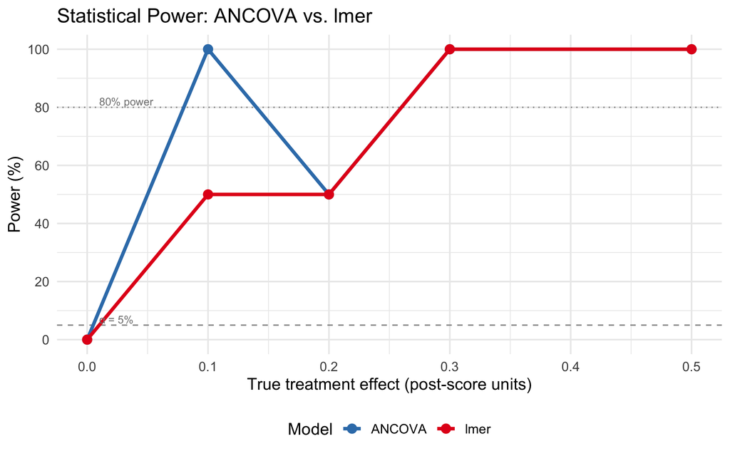

```r
sim_results %>%
  select(true_delta, anc_power, lmer_power) %>%
  pivot_longer(c(anc_power, lmer_power), names_to = "model", values_to = "power") %>%
  mutate(model = recode(model, "anc_power" = "ANCOVA", "lmer_power" = "lmer")) %>%
  ggplot(aes(x = true_delta, y = power * 100, color = model, group = model)) +
  geom_hline(yintercept = 5,  linetype = "dashed", color = "gray60", linewidth = 0.5) +
  geom_hline(yintercept = 80, linetype = "dotted", color = "gray60", linewidth = 0.5) +
  geom_line(linewidth = 1.3) +
  geom_point(size = 3) +
  annotate("text", x = 0.01, y = 7,  label = "α = 5%",    size = 3, color = "gray50", hjust = 0) +
  annotate("text", x = 0.01, y = 82, label = "80% power", size = 3, color = "gray50", hjust = 0) +
  scale_color_manual(values = c("ANCOVA" = "#377EB8", "lmer" = "#E41A1C"), name = "Model") +
  scale_y_continuous(limits = c(0, 100), breaks = seq(0, 100, 20)) +
  labs(
    x = "True treatment effect (post-score units)",
    y = "Power (%)",
    title = "Statistical Power: ANCOVA vs. lmer"
  ) +
  theme_minimal(base_size = 13) +
  theme(legend.position = "bottom")
```

```r
ggsave(paste0(fig_path, "simulation_power.png"), width = 8, height = 5, dpi = 300)
```

# Appendix: Outlier Robustness

How sensitive are the main DiD estimates to the choice of outlier exclusion strategy? We compare four samples: the full data, z-score exclusions (|within-condition z| > 2.5 on either change score), Cook’s D exclusions (> 4/*n* on either ANCOVA), and Mahalanobis exclusions (χ²(2) p < .025 on the joint change-score space). Only the 3-condition version is shown.

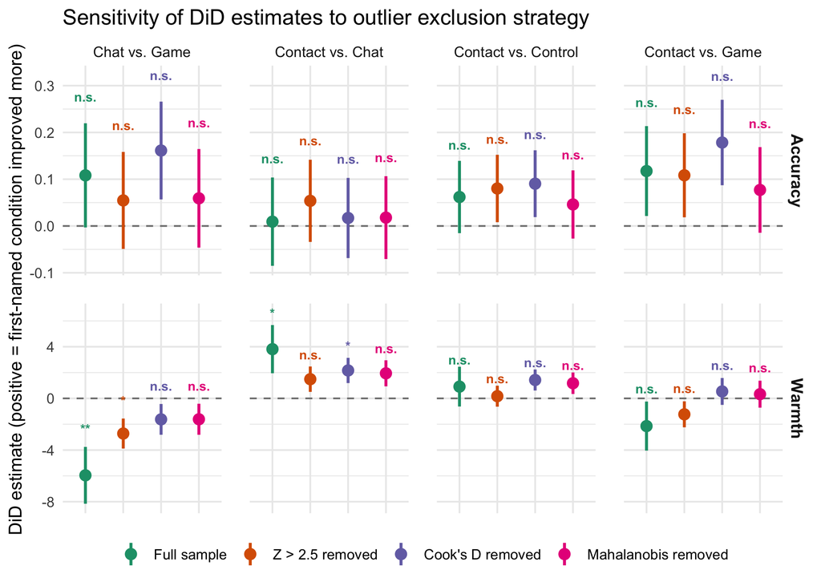

DiD estimates across four outlier exclusion strategies. Each column is a pairwise condition contrast (e.g. ‘Contact vs. Chat’ = Contact Δ minus Chat Δ); positive values mean the first-named condition improved more. Accuracy and Warmth are shown in separate rows with independent y-axes. Error bars = ±SE.

```r
# ── Helper: fit all pairwise DiD contrasts for a given dataset + condition set ─
pairwise_did_contrasts <- function(d, conds) {
  d <- d %>% mutate(treatment = factor(treatment, levels = conds))
  n <- length(conds)

  fit_one <- function(dv_pre, dv_post, dv_label) {
    long <- d %>%
      select(ResponseId, treatment, all_of(c(dv_pre, dv_post))) %>%
      pivot_longer(c(all_of(dv_pre), all_of(dv_post)),
                   names_to = "time", values_to = "y") %>%
      mutate(time = factor(if_else(str_detect(time, "pre"), "pre", "post"),
                           levels = c("pre", "post")))
    m   <- lmer(y ~ time * treatment + (1 | ResponseId), data = long, REML = FALSE)
    emm <- emmeans(m, ~ time * treatment)
    pairs_idx <- combn(seq_along(conds), 2, simplify = FALSE)
    con_list  <- lapply(pairs_idx, function(idx) {
      v <- numeric(2 * n)
      i <- idx[1]; j <- idx[2]
      v[(2*i-1):(2*i)] <- c(-1,  1)
      v[(2*j-1):(2*j)] <- c( 1, -1)
      v
    })
    names(con_list) <- sapply(pairs_idx, function(idx)
      paste0(conds[idx[1]], " vs. ", conds[idx[2]]))
    contrast(emm, con_list) %>% as_tibble() %>% mutate(dv = dv_label)
  }

  bind_rows(
    fit_one("accuracy_pre",        "accuracy_post",        "Accuracy"),
    fit_one("warmth_outgroup_pre",  "warmth_outgroup_post", "Warmth")
  )
}

# ── Build the four samples (always on raw full/Feb17 data, 3 conditions) ──────
dat_raw <- read_parquet(paste0(base_path,
  if (full_data) "analysis_data.parquet" else "analysis_data_Feb17.parquet")) %>%
  mutate(
    treatment   = factor(treatment, levels = c("Contact", "Chat", "Game")),
    acc_change  = accuracy_post - accuracy_pre,
    warm_change = warmth_outgroup_post - warmth_outgroup_pre
  )

# z-score flags
dat_raw <- dat_raw %>%
  group_by(treatment) %>%
  mutate(acc_z  = scale(acc_change)[, 1],
         warm_z = scale(warm_change)[, 1]) %>%
  ungroup()
ids_z_rob <- dat_raw$ResponseId[abs(dat_raw$acc_z) > 2.5 | abs(dat_raw$warm_z) > 2.5]

# Cook's D flags
anc_a <- lm(accuracy_post        ~ accuracy_pre        + treatment, data = dat_raw)
anc_w <- lm(warmth_outgroup_post ~ warmth_outgroup_pre + treatment, data = dat_raw)
ct    <- 4 / nrow(dat_raw)
ids_cd_rob <- dat_raw$ResponseId[cooks.distance(anc_a) > ct | cooks.distance(anc_w) > ct]

# Mahalanobis flags
mah_rob <- mahalanobis(
  cbind(dat_raw$acc_change, dat_raw$warm_change),
  colMeans(cbind(dat_raw$acc_change, dat_raw$warm_change), na.rm = TRUE),
  cov(cbind(dat_raw$acc_change, dat_raw$warm_change), use = "complete.obs")
)
ids_mah_rob <- dat_raw$ResponseId[mah_rob > qchisq(0.975, df = 2)]

conds_3 <- c("Contact", "Chat", "Game")

# ── Helper: Contact vs. pooled controls DiD ──────────────────────────────────
contact_vs_control_did <- function(d) {
  d <- d %>%
    mutate(trt2 = if_else(treatment == "Contact", "Contact", "Control"),
           trt2 = factor(trt2, levels = c("Contact", "Control")))

  fit_pooled <- function(dv_pre, dv_post, dv_label) {
    long <- d %>%
      select(ResponseId, trt2, all_of(c(dv_pre, dv_post))) %>%
      pivot_longer(c(all_of(dv_pre), all_of(dv_post)),
                   names_to = "time", values_to = "y") %>%
      mutate(time = factor(if_else(str_detect(time, "pre"), "pre", "post"),
                           levels = c("pre", "post")))
    m   <- lmer(y ~ time * trt2 + (1 | ResponseId), data = long, REML = FALSE)
    emm <- emmeans(m, ~ time * trt2)
    con <- list(`Contact vs. Control` = c(-1, 1, 1, -1))
    contrast(emm, con) %>% as_tibble() %>% mutate(dv = dv_label)
  }

  bind_rows(
    fit_pooled("accuracy_pre",       "accuracy_post",        "Accuracy"),
    fit_pooled("warmth_outgroup_pre", "warmth_outgroup_post", "Warmth")
  ) %>% mutate(contrast = "Contact vs. Control")
}

did_robust <- bind_rows(
  pairwise_did_contrasts(dat_raw,                                      conds_3) %>% mutate(sample = "Full sample"),
  pairwise_did_contrasts(filter(dat_raw, !ResponseId %in% ids_z_rob),  conds_3) %>% mutate(sample = "Z > 2.5 removed"),
  pairwise_did_contrasts(filter(dat_raw, !ResponseId %in% ids_cd_rob), conds_3) %>% mutate(sample = "Cook's D removed"),
  pairwise_did_contrasts(filter(dat_raw, !ResponseId %in% ids_mah_rob),conds_3) %>% mutate(sample = "Mahalanobis removed"),
  contact_vs_control_did(dat_raw)                                                %>% mutate(sample = "Full sample"),
  contact_vs_control_did(filter(dat_raw, !ResponseId %in% ids_z_rob))            %>% mutate(sample = "Z > 2.5 removed"),
  contact_vs_control_did(filter(dat_raw, !ResponseId %in% ids_cd_rob))           %>% mutate(sample = "Cook's D removed"),
  contact_vs_control_did(filter(dat_raw, !ResponseId %in% ids_mah_rob))          %>% mutate(sample = "Mahalanobis removed")
) %>%
  mutate(
    sample = factor(sample, levels = c("Full sample", "Z > 2.5 removed",
                                       "Cook's D removed", "Mahalanobis removed")),
    ymin   = estimate - SE,
    ymax   = estimate + SE,
    stars  = p_to_stars(p.value)
  )

# Per-panel star y position: add a small offset above the panel's own ymax
did_robust <- did_robust %>%
  group_by(dv, contrast) %>%
  mutate(star_y = ymax + (max(ymax) - min(ymin)) * 0.18) %>%
  ungroup()

ggplot(did_robust, aes(x = sample, y = estimate, color = sample)) +
  geom_hline(yintercept = 0, linetype = "dashed", color = "gray50") +
  geom_pointrange(aes(ymin = ymin, ymax = ymax), size = 0.55, linewidth = 0.85) +
  geom_text(aes(y = star_y, label = stars), size = 2.8, fontface = "bold") +
  facet_grid(dv ~ contrast, scales = "free") +
  scale_color_brewer(palette = "Dark2", name = NULL) +
  labs(x = NULL,
       y = "DiD estimate (positive = first-named condition improved more)",
       title = "Sensitivity of DiD estimates to outlier exclusion strategy") +
  theme_minimal(base_size = 11) +
  theme(axis.text.x  = element_blank(),
        axis.ticks.x = element_blank(),
        legend.position = "bottom",
        panel.spacing = unit(1.2, "lines"),
        strip.text.x = element_text(size = 9),
        strip.text.y = element_text(size = 10, face = "bold"))
```

# Appendix: Comments

```r
dat %>%
  filter(!is.na(comments)) %>%
  select(ResponseId, treatment, comments) %>%
  gt() %>%
  tab_header(title = "Participant Comments")
```

User comments

Participant Comments

| Response ID | treatment | Thank you for participating! Feel free to leave any comments for the researchers below. |
| --- | --- | --- |
| R_6Mxkq7RXuuRtFAD | Contact | Interesting study! Everything worked great and was clear. Thank you and good luck! |
| R_7Cw4TE8kru6kL5u | Contact | Thank you and have a great day. |
| R_54CMcMKnxqb4PMz | Contact | I chose to "keep" the 50 cents because of the fake AI picture. |
| R_16FILkyhdZYSLDP | Contact | everything was clear and went well |
| R_63wrUj8Jqg0k2K5 | Contact | the study went well |
| R_3ifxtEJdBp0vstS | Contact | None at this time |
| R_65TmscMvnmqpXu9 | Contact | This was a cool study! Thank you! |
| R_7IS33dZyMFmLFtv | Contact | Just because I didn't donate to a person does not mean I am not generous. I don't know what her health concerns are nor do I know her. My generosity goes toward those I feel called to help. We give ov… |
| R_3d6z6zShhkFMbEg | Contact | Thank you! |
| R_6iCpMIfC1AjRIqW | Contact | NA |
| R_5oAID4ei8Z5aMXD | Contact | Thanks for the opportunity! I think I convinced your chatbot that climate change is not an existential threat to humanity! |
| R_6hRtYZM8Hy36nJD | Contact | None |
| R_3KCNmyynKcgNAyc | Contact | interesting |
| R_6R1mYuFkmUmIjTl | Contact | No comment |
| R_6Ehtm9xFqW7b0wM | Contact | NA |
| R_3k53C8UNvl76fyV | Contact | Despite popular belief, Republicans are not cold-hearted and are generous (even to those in need who are on the opposite side of the political aisle). If anything, as a Republican, I feel that Democra… |
| R_7KoURIe0gGEgqSF | Contact | None |
| R_5MGau1naGifeg6t | Contact | If I was chosen, I'd like to speak to a Republican to see if my views about the opposite political side were accurate and would like to get some insight as to how they truly feel. |
| R_5DwNz2YDM9H9rGS | Contact | good chatbot |
| R_5NEveTzmAWL5gc8 | Contact | The study was engaging and clear |
| R_76nY0ya7Viz8mjb | Contact | Nice survey |
| R_1gMBuM0ET3Kh8rs | Contact | N/A |
| R_3A34hPYcDbZXhF7 | Contact | Great study, thank you. |
| R_5kBN5MCuWvvlP6k | Contact | Donating all to the lady has to be my best feeling this whole |
| R_1QsZgiEPH18Mk99 | Contact | no comments |
| R_1Gyx2W0K73X5qrE | Contact | Thank you |
| R_6m5HAzdprwFslX3 | Chat | NA |
| R_5kYarxF29XzW6dj | Chat | Talking to a democrat would be useless. They only listen and believe what they see on TikTok. |
| R_7f7aIVOsZMIiAVj | Chat | This was an awesome survey and experience. I hope I get to have more conversations like this with AI chat programs in the future. It was very insightful. |
| R_3uWDQQszjQFPhkl | Contact | This study was actually fun. I look forward to participating in future studies such as this. |

[output cut: 74 more lines]

## Sample

```r
n_total <- nrow(dat)
n_by_condition <- dat %>% count(treatment)
n_contact <- n_by_condition %>% filter(treatment == "Contact") %>% pull(n)
if (!pool_controls) {
  n_chat <- n_by_condition %>% filter(treatment == "Chat") %>% pull(n)
  n_game <- n_by_condition %>% filter(treatment == "Game") %>% pull(n)
} else {
  n_control <- n_by_condition %>% filter(treatment == "Control") %>% pull(n)
}
mean_age   <- mean(dat$age, na.rm = TRUE)
pct_female <- mean(dat$gender == "Female", na.rm = TRUE) * 100
```

We recruited 301 participants from Prolific: 108 in the Contact condition and 193 in the Control condition (Chat + Game pooled; mean age = 42.28, 54% female).

```r
dat %>%
  group_by(treatment) %>%
  summarise(
    N = n(),
    `Democrats (D→R)` = sum(learner_party == "D→R"),
    `Republicans (R→D)` = sum(learner_party == "R→D"),
    `Mean Age` = mean(age, na.rm = TRUE) %>% numformat(),
    `% Female` = (sum(gender == "Female", na.rm = TRUE) / n() * 100) %>% numformat(0),
    `Extremism (M)` = mean(political_extremism, na.rm = TRUE) %>% numformat(),
    .groups = "drop"
  ) %>%
  gt() %>%
  tab_header(title = "Sample Composition by Condition")
```

Sample Composition by Condition

| treatment | N | Democrats (D→R) | Republicans (R→D) | Mean Age | % Female | Extremism (M) |
| --- | --- | --- | --- | --- | --- | --- |
| Contact | 108 | 49 | 59 | 40.69 | 56 | 77.45 |
| Control | 193 | 103 | 90 | 43.17 | 53 | 77.84 |

```r
# Actual green score by party (from own responses)
actual_by_party <- dat %>%
  group_by(learner_party) %>%
  summarise(
    actual = mean(actual_green, na.rm = TRUE) %>% numformat(),
    .groups = "drop"
  )

dat %>%
  group_by(treatment, learner_party) %>%
  summarise(
    `Baseline belief (M)` = mean(green_outgroup_pre, na.rm = TRUE) %>% numformat(),
    .groups = "drop"
  ) %>%
  left_join(actual_by_party, by = "learner_party") %>%
  rename(Condition = treatment, `Learner party` = learner_party,
         `Actual outgroup mean` = actual) %>%
  gt() %>%
  tab_header(title = "Baseline Outgroup Env. Beliefs by Condition and Party",
             subtitle = "Composite mean of env1–6 (1–5 scale); higher = more pro-environment attributed to outgroup") %>%
  tab_footnote("Actual = true mean from the outgroup's own responses. D→R = Democrats estimating Republicans; R→D = Republicans estimating Democrats.",
               locations = cells_title())
```

Mean baseline outgroup environmental attitude beliefs (composite of env1–6, 1–5 scale) by condition and learner party. ‘Actual’ is the true mean of the outgroup’s own responses (Republicans’ actual for D→R; Democrats’ actual for R→D).

Baseline Outgroup Env. Beliefs by Condition and Party<sup>1</sup>

Composite mean of env1–6 (1–5 scale); higher = more pro-environment attributed to outgroup<sup>1</sup>

| Condition | Learner party | Baseline belief (M) | Actual outgroup mean |
| --- | --- | --- | --- |
| Contact | D→R | 2.19 | 3.59 |
| Contact | R→D | 3.88 | 4.06 |
| Control | D→R | 2.09 | 3.59 |
| Control | R→D | 3.94 | 4.06 |

<sup>1</sup> Actual = true mean from the outgroup's own responses. D→R = Democrats estimating Republicans; R→D = Republicans estimating Democrats.

### Condition balance check

```r
# Check randomization: are conditions balanced on baseline measures?
bal_acc  <- aov(accuracy_pre ~ treatment, data = dat)
bal_warm <- aov(warmth_outgroup_pre ~ treatment, data = dat)
bal_ext  <- aov(political_extremism ~ treatment, data = dat)

bal_acc_p  <- summary(bal_acc)[[1]][["Pr(>F)"]][1]
bal_warm_p <- summary(bal_warm)[[1]][["Pr(>F)"]][1]
bal_ext_p  <- summary(bal_ext)[[1]][["Pr(>F)"]][1]
```

### Differential engagement / cheating check

```r
# Survey phase: tab switches and hidden time (same for all conditions)
eng_survey_aov_switch <- aov(tab_switch_count   ~ treatment, data = dat)
eng_survey_aov_hidden <- aov(I(time_hidden_ms / 1000) ~ treatment, data = dat)
eng_survey_switch_p <- summary(eng_survey_aov_switch)[[1]][["Pr(>F)"]][1]
eng_survey_hidden_p <- summary(eng_survey_aov_hidden)[[1]][["Pr(>F)"]][1]

# Intervention phase: tab switches and time in intervention window
eng_bot_aov_switch <- aov(tab_switch_count_bot ~ treatment, data = dat)
eng_bot_aov_hidden <- aov(I(time_hidden_ms_bot / 60000) ~ treatment, data = dat)
eng_bot_switch_p <- summary(eng_bot_aov_switch)[[1]][["Pr(>F)"]][1]
eng_bot_hidden_p <- summary(eng_bot_aov_hidden)[[1]][["Pr(>F)"]][1]

# Pairwise for bot tab switches (the only marginally significant survey metric)
eng_bot_switch_tukey <- dat %>% tukey_hsd(tab_switch_count_bot ~ treatment)
if (!pool_controls) {
  eng_bot_contact_game_p <- eng_bot_switch_tukey %>%
    filter(group1 == "Contact", group2 == "Game") %>% pull(p.adj)
} else {
  eng_bot_contact_game_p <- eng_bot_switch_tukey %>%
    filter(group1 == "Contact", group2 == "Control") %>% pull(p.adj)
}

# Summary table
eng_summary <- dat %>%
  group_by(treatment) %>%
  summarise(
    `Survey switches (M)` = mean(tab_switch_count, na.rm = TRUE),
    `Survey hidden (sec, M)` = mean(time_hidden_ms / 1000, na.rm = TRUE),
    `Intervention switches (M)` = mean(tab_switch_count_bot, na.rm = TRUE),
    `Intervention time in window (min, M)` = mean(time_hidden_ms_bot / 60000, na.rm = TRUE),
    .groups = "drop"
  )
```

```r
eng_summary %>%
  mutate(across(where(is.double), ~ numformat(.x))) %>%
  rename(Condition = treatment) %>%
  gt() %>%
  tab_header(title = "Engagement by Condition") %>%
  tab_footnote(
    "Survey phase: tab switches and hidden time during the questionnaire. Intervention phase: switches and time during the treatment window.",
    locations = cells_title()
  )
```

Engagement by Condition<sup>1</sup>

| Condition | Survey switches (M) | Survey hidden (sec, M) | Intervention switches (M) | Intervention time in window (min, M) |
| --- | --- | --- | --- | --- |
| Contact | 0.28 | 3.12 | 0.85 | 0.64 |
| Control | 0.12 | 1.86 | 0.70 | 0.28 |

<sup>1</sup> Survey phase: tab switches and hidden time during the questionnaire. Intervention phase: switches and time during the treatment window.

**Survey phase** (left the survey screen): conditions did not differ in tab switches (*F* = 0.086) or hidden time (*F* = 0.360), ruling out differential cheating during measurement.

### Outlier removal

```r
dat <- dat %>%
  mutate(
    acc_change  = accuracy_post - accuracy_pre,
    warm_change = warmth_outgroup_post - warmth_outgroup_pre
  )

# ── Cook's D > 4/n from ANCOVA (accuracy and warmth) ─────────────────────────
ancova_acc  <- lm(accuracy_post        ~ accuracy_pre        + treatment, data = dat)
ancova_warm <- lm(warmth_outgroup_post ~ warmth_outgroup_pre + treatment, data = dat)
cooks_thresh <- 4 / nrow(dat)

dat <- dat %>%
  mutate(
    cooks_acc  = cooks.distance(ancova_acc),
    cooks_warm = cooks.distance(ancova_warm),
    flag_cooks = cooks_acc > cooks_thresh | cooks_warm > cooks_thresh
  )

# ── Mahalanobis distance on (acc_change, warm_change) ────────────────────────
# Chi-square threshold: p < .025, df = 2
mah_thresh <- qchisq(0.975, df = 2)
dat <- dat %>%
  mutate(
    mah_d    = mahalanobis(cbind(acc_change, warm_change),
                           colMeans(cbind(acc_change, warm_change), na.rm = TRUE),
                           cov(cbind(acc_change, warm_change), use = "complete.obs")),
    flag_mah = mah_d > mah_thresh
  )

ids_cooks <- dat$ResponseId[dat$flag_cooks]
ids_mah   <- dat$ResponseId[dat$flag_mah]
n_cooks   <- length(ids_cooks)
n_mah     <- length(ids_mah)
n_overlap <- sum(ids_mah %in% ids_cooks)   # Mah is a strict subset of Cook's D

# Use Mahalanobis for removal (more conservative; Cook's D subset already included)
outlier_ids <- ids_mah
n_before  <- nrow(dat)
dat       <- dat %>% filter(!ResponseId %in% outlier_ids)
n_removed <- n_before - nrow(dat)

# ── Regression-to-mean evidence (on cleaned data) ────────────────────────────
rtm_cors <- dat %>%
  group_by(treatment) %>%
  summarise(r_pre_change = cor(accuracy_pre, acc_change, use = "complete.obs"),
            .groups = "drop")
rtm_cors_text <- rtm_cors %>%
  mutate(s = paste0(treatment, ": *r* = ", numformat(r_pre_change))) %>%
  pull(s) %>% paste(collapse = ", ")
```

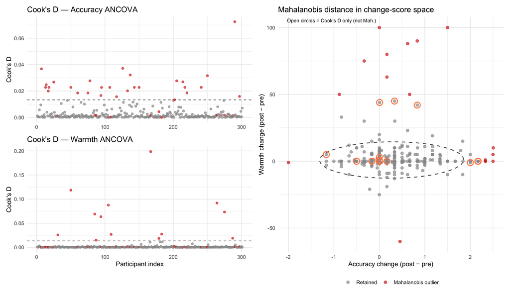

```r
dat_all <- bind_rows(
  dat,
  bind_rows(
    filter(read_parquet(paste0(base_path, if (full_data) "analysis_data.parquet" else "analysis_data_Feb17.parquet")),
           TRUE) %>%
      mutate(
        acc_change  = accuracy_post - accuracy_pre,
        warm_change = warmth_outgroup_post - warmth_outgroup_pre,
        treatment   = factor(if (pool_controls)
                               if_else(treatment == "Contact", "Contact", "Control")
                             else treatment,
                             levels = if (pool_controls) c("Contact","Control")
                                      else c("Contact","Chat","Game"))
      )
  ) %>% filter(ResponseId %in% c(ids_cooks, ids_mah))
) %>% distinct(ResponseId, .keep_all = TRUE)

# Rebuild Cook's D on full pre-removal data for plotting
dat_pre <- read_parquet(paste0(base_path, if (full_data) "analysis_data.parquet" else "analysis_data_Feb17.parquet")) %>%
  mutate(
    acc_change  = accuracy_post - accuracy_pre,
    warm_change = warmth_outgroup_post - warmth_outgroup_pre,
    treatment   = factor(if (pool_controls)
                           if_else(treatment == "Contact", "Contact", "Control")
                         else treatment,
                         levels = if (pool_controls) c("Contact","Control")
                                  else c("Contact","Chat","Game"))
  )

anc_acc_pre  <- lm(accuracy_post        ~ accuracy_pre        + treatment, data = dat_pre)
anc_warm_pre <- lm(warmth_outgroup_post ~ warmth_outgroup_pre + treatment, data = dat_pre)
mah_pre <- mahalanobis(
  cbind(dat_pre$acc_change, dat_pre$warm_change),
  colMeans(cbind(dat_pre$acc_change, dat_pre$warm_change), na.rm = TRUE),
  cov(cbind(dat_pre$acc_change, dat_pre$warm_change), use = "complete.obs")
)

plot_dat <- dat_pre %>%
  mutate(
    cooks_acc  = cooks.distance(anc_acc_pre),
    cooks_warm = cooks.distance(anc_warm_pre),
    mah_d      = mah_pre,
    flag_cooks = cooks_acc > cooks_thresh | cooks_warm > cooks_thresh,
    flag_mah   = mah_d > mah_thresh,
    idx        = row_number()
  )

# Cook's D panels
p_cook_acc <- ggplot(plot_dat, aes(x = idx, y = cooks_acc, color = flag_cooks)) +
  geom_hline(yintercept = cooks_thresh, linetype = "dashed", color = "gray40") +
  geom_point(size = 1.5, alpha = 0.7) +
  scale_color_manual(values = c("FALSE" = "gray60", "TRUE" = "#D73027"), guide = "none") +
  labs(x = NULL, y = "Cook's D", title = "Cook's D — Accuracy ANCOVA") +
  theme_minimal(base_size = 11)

p_cook_warm <- ggplot(plot_dat, aes(x = idx, y = cooks_warm, color = flag_cooks)) +
  geom_hline(yintercept = cooks_thresh, linetype = "dashed", color = "gray40") +
  geom_point(size = 1.5, alpha = 0.7) +
  scale_color_manual(values = c("FALSE" = "gray60", "TRUE" = "#D73027"), guide = "none") +
  labs(x = "Participant index", y = "Cook's D", title = "Cook's D — Warmth ANCOVA") +
  theme_minimal(base_size = 11)

# Mahalanobis scatter
p_mah <- ggplot(plot_dat, aes(x = acc_change, y = warm_change)) +
  stat_ellipse(level = 0.975, linetype = "dashed", color = "gray40", linewidth = 0.7) +
  geom_point(aes(color = flag_mah), size = 2, alpha = 0.7) +
  geom_point(data = filter(plot_dat, flag_cooks & !flag_mah),
             shape = 1, size = 4, color = "#FC8D59", stroke = 1.2) +
  scale_color_manual(values = c("FALSE" = "gray60", "TRUE" = "#D73027"),
                     labels = c("Retained", "Mahalanobis outlier"),
                     name = NULL) +
  annotate("text", x = -Inf, y = Inf, hjust = -0.1, vjust = 1.5, size = 3,
           label = "Open circles = Cook's D only (not Mah.)") +
  labs(x = "Accuracy change (post − pre)", y = "Warmth change (post − pre)",
       title = "Mahalanobis distance in change-score space") +
  theme_minimal(base_size = 11) +
  theme(legend.position = "bottom")

(p_cook_acc / p_cook_warm) | p_mah
```

**Outlier methods compared.** Cook’s D (threshold 4/*n* = 0.0133) flagged 39 participants across the two ANCOVA models. Mahalanobis distance on the joint (accuracy change, warmth change) space (χ² threshold *p* < .025, df = 2) flagged 17, all of whom were also flagged by Cook’s D. The remaining 22 Cook’s D flags were influential in one ANCOVA but not extreme in the bivariate change space. We use the **Mahalanobis criterion** for removal as it directly captures participants with unusual *combinations* of change scores, is scale-invariant, and results in a more conservative exclusion (*N* removed = 17). All analyses below use the cleaned sample (*N* = 284).

**Baseline and change.** Within each condition, participants who started with the lowest accuracy tended to show the largest improvements (Contact: *r* = -0.67, Control: *r* = -0.61). This is mechanically expected in any pre-post design and applies similarly across conditions, so it does not confound the condition comparison. The DiD contrast and ANCOVA below account for baseline by design.

```r
desc_vars <- list(
  "Accuracy (pre)"        = "accuracy_pre",
  "Accuracy (post)"       = "accuracy_post",
  "Warmth (pre)"          = "warmth_outgroup_pre",
  "Warmth (post)"         = "warmth_outgroup_post",
  "Confidence (pre)"      = "confidence_outgroup_pre",
  "Confidence (post)"     = "confidence_outgroup_post",
  "Donation (cents)"      = "donation",
  "Age"                   = "age",
  "Political extremism"   = "political_extremism"
)

fmt_msd <- function(x) {
  m <- mean(x, na.rm = TRUE)
  s <- sd(x,   na.rm = TRUE)
  paste0(numformat(m), " (", numformat(s), ")")
}

conds <- levels(dat$treatment)

desc_tbl <- map_dfr(names(desc_vars), function(label) {
  col <- desc_vars[[label]]
  row <- tibble(Variable = label, Overall = fmt_msd(dat[[col]]))
  for (cond in conds) {
    row[[cond]] <- fmt_msd(dat[[col]][dat$treatment == cond])
  }
  row
})

desc_tbl %>%
  gt() %>%
  tab_header(title = "Descriptive Statistics by Condition",
             subtitle = "M (SD); after Cook's D outlier removal") %>%
  tab_footnote("Accuracy = negative absolute error (higher = more accurate). Warmth on 0–100 scale. Confidence on 1–5 scale.",
               locations = cells_title())
```

Descriptive statistics (M ± SD) for all key variables overall and by condition, after outlier removal.

Descriptive Statistics by Condition<sup>1</sup>

| Variable | Overall | Contact | Control |
| --- | --- | --- | --- |
| Accuracy (pre) | -1.06 (0.81) | -1.00 (0.76) | -1.09 (0.84) |
| Accuracy (post) | -0.75 (0.65) | -0.69 (0.58) | -0.78 (0.68) |
| Warmth (pre) | 33.01 (25.81) | 38.10 (25.77) | 30.16 (25.46) |
| Warmth (post) | 34.65 (26.74) | 40.55 (26.61) | 31.34 (26.32) |
| Confidence (pre) | 3.12 (1.01) | 3.04 (1.05) | 3.16 (0.99) |
| Confidence (post) | 3.39 (1.01) | 3.53 (0.93) | 3.31 (1.05) |
| Donation (cents) | 20.85 (21.55) | 21.85 (21.39) | 20.29 (21.68) |
| Age | 42.59 (13.68) | 41.06 (14.05) | 43.45 (13.43) |
| Political extremism | 77.52 (23.76) | 77.08 (25.59) | 77.76 (22.74) |

<sup>1</sup> Accuracy = negative absolute error (higher = more accurate). Warmth on 0–100 scale. Confidence on 1–5 scale.

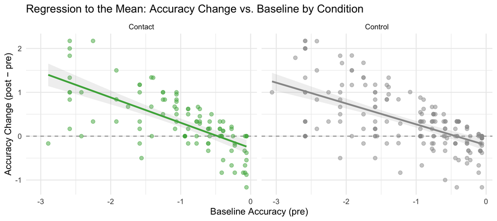

Accuracy change vs. baseline accuracy by condition. Strong negative slopes indicate regression to the mean: participants who started most inaccurate improved most, regardless of condition.

```r
ggplot(dat, aes(x = accuracy_pre, y = acc_change, color = treatment)) +
  geom_hline(yintercept = 0, linetype = "dashed", color = "gray60") +
  geom_point(alpha = 0.5, size = 2) +
  geom_smooth(method = "lm", se = TRUE, alpha = 0.15) +
  scale_color_manual(values = condition_colors, name = "Condition") +
  facet_wrap(~ treatment) +
  labs(
    x = "Baseline Accuracy (pre)",
    y = "Accuracy Change (post − pre)",
    title = "Regression to the Mean: Accuracy Change vs. Baseline by Condition"
  ) +
  theme_minimal(base_size = 12) +
  theme(legend.position = "none")
```

```r
ggsave(paste0(fig_path, "rtm_check.png"), width = 9, height = 4, dpi = 300)
```

## Pre-Post Changes Overall

Before examining condition differences, we verify that the pre-post design shows evidence of change across the full sample.

```r
# Accuracy
acc_overall <- t.test(dat$accuracy_post, dat$accuracy_pre, paired = TRUE)
acc_d_overall <- mean(dat$accuracy_post - dat$accuracy_pre) / sd(dat$accuracy_post - dat$accuracy_pre)

# Warmth
warm_overall <- t.test(dat$warmth_outgroup_post, dat$warmth_outgroup_pre, paired = TRUE)
warm_d_overall <- mean(dat$warmth_outgroup_post - dat$warmth_outgroup_pre) / sd(dat$warmth_outgroup_post - dat$warmth_outgroup_pre)

# Confidence
conf_overall <- t.test(dat$confidence_outgroup_post, dat$confidence_outgroup_pre, paired = TRUE)
conf_d_overall <- mean(dat$confidence_outgroup_post - dat$confidence_outgroup_pre) / sd(dat$confidence_outgroup_post - dat$confidence_outgroup_pre)
```

Across the full sample, accuracy improved (*t*(283) = 8.03, *p* < .001, *d* = 0.48), outgroup warmth increased (*t*(283) = 3.66, *p* < .001, *d* = 0.22), and confidence changed (*t*(283) = 4.41, *p* < .001, *d* = 0.26).

## Condition Differences (Main Analysis)

The primary question is whether the Contact condition shows greater pre-post improvement than the two control conditions (Chat, Game) pooled together. We use a mixed-effects model with a `time × treatment` interaction, and test the key contrast: Contact Δ vs. average of Chat Δ and Game Δ.

### Accuracy

```r
accuracy_long <- dat %>%
  select(ResponseId, treatment, learner_party, accuracy_pre, accuracy_post) %>%
  pivot_longer(c(accuracy_pre, accuracy_post),
               names_to = "time", names_pattern = "accuracy_(pre|post)",
               values_to = "accuracy") %>%
  mutate(time = factor(time, levels = c("pre", "post")))

# Model: time × treatment (reference = Contact)
m_acc <- lmer(accuracy ~ time * treatment + (1 | ResponseId), data = accuracy_long)

# Pre-post differences within each condition
emm_acc_by_cond <- emmeans(m_acc, ~ time | treatment)
acc_contrasts <- contrast(emm_acc_by_cond, "revpairwise", by = "treatment") %>%
  as_tibble()  # positive = improvement (post - pre)

# Full grid for DiD contrasts — adaptive to pool_controls toggle
# Grid order (3-cond): pre×Contact, post×Contact, pre×Chat, post×Chat, pre×Game, post×Game
# Grid order (pooled): pre×Contact, post×Contact, pre×Control, post×Control
emm_acc_full <- emmeans(m_acc, ~ time * treatment)
pull_did <- function(tbl, nm, col) tbl %>% filter(contrast == nm) %>% pull({{ col }})

if (pool_controls) {
  acc_did <- contrast(emm_acc_full, list(
    `Contact vs. Control` = c(1, -1, -1, 1)   # Control Δ - Contact Δ ... sign: positive = Control > Contact
  ))
  # flip sign so positive = Contact improved more
  acc_did_tbl <- acc_did %>% as_tibble() %>% mutate(estimate = -estimate)
  acc_main_b  <- pull_did(acc_did_tbl, "Contact vs. Control", estimate)
  acc_main_se <- pull_did(acc_did_tbl, "Contact vs. Control", SE)
  acc_main_p  <- pull_did(acc_did_tbl, "Contact vs. Control", p.value)
  acc_chat_vs_contact_b <- NA_real_; acc_chat_vs_contact_p <- NA_real_
  acc_game_vs_contact_b <- NA_real_; acc_game_vs_contact_p <- NA_real_
  acc_chat_vs_game_b    <- NA_real_; acc_chat_vs_game_p    <- NA_real_
} else {
  acc_did <- contrast(emm_acc_full, list(
    `Contact vs. pooled controls` = c(-1,  1,  0.5, -0.5,  0.5, -0.5),
    `Chat vs. Contact`            = c( 1, -1, -1,    1,    0,    0  ),
    `Game vs. Contact`            = c( 1, -1,  0,    0,   -1,    1  ),
    `Chat vs. Game`               = c( 0,  0, -1,    1,    1,   -1  )
  ))
  acc_did_tbl           <- acc_did %>% as_tibble()
  acc_main_b            <- pull_did(acc_did_tbl, "Contact vs. pooled controls", estimate)
  acc_main_se           <- pull_did(acc_did_tbl, "Contact vs. pooled controls", SE)
  acc_main_p            <- pull_did(acc_did_tbl, "Contact vs. pooled controls", p.value)
  acc_chat_vs_contact_b <- pull_did(acc_did_tbl, "Chat vs. Contact", estimate)
  acc_chat_vs_contact_p <- pull_did(acc_did_tbl, "Chat vs. Contact", p.value)
  acc_game_vs_contact_b <- pull_did(acc_did_tbl, "Game vs. Contact", estimate)
  acc_game_vs_contact_p <- pull_did(acc_did_tbl, "Game vs. Contact", p.value)
  acc_chat_vs_game_b    <- pull_did(acc_did_tbl, "Chat vs. Game",    estimate)
  acc_chat_vs_game_p    <- pull_did(acc_did_tbl, "Chat vs. Game",    p.value)
}
```

The time × treatment interaction tests whether conditions differed in accuracy improvement.

```r
acc_contrasts %>%
  select(Condition = treatment,
         `Pre→Post Improvement` = estimate,
         SE, df, `t-ratio` = t.ratio, `p-value` = p.value) %>%
  mutate(
    `Pre→Post Improvement` = numformat(`Pre→Post Improvement`),
    SE = numformat(SE),
    df = numformat(df, 0),
    `t-ratio` = numformat(`t-ratio`),
    `p-value` = map_chr(`p-value`, pformat)
  ) %>%
  gt() %>%
  tab_header(title = "Accuracy: Pre-Post Improvement by Condition") %>%
  tab_footnote("Positive = improvement. Estimated from mixed-effects model (Contact as reference).",
               locations = cells_title())
```

Accuracy: Pre-Post Improvement by Condition<sup>1</sup>

| Condition | Pre→Post Improvement | SE | df | t-ratio | p-value |
| --- | --- | --- | --- | --- | --- |
| Contact | 0.31 | 0.06 | 282 | 4.72 | < .001 |
| Control | 0.31 | 0.05 | 282 | 6.48 | < .001 |

<sup>1</sup> Positive = improvement. Estimated from mixed-effects model (Contact as reference).

**Primary test:** Contact vs. Control: *b* = -0.01, SE = 0.08, *p* = 0.918.

### Model choice: lmer vs. ANCOVA

```r
# Pre-post correlation by condition (drives the key tradeoff between lmer and ANCOVA)
prepost_cors <- dat %>%
  group_by(treatment) %>%
  summarise(
    r_prepost = cor(accuracy_pre, accuracy_post, use = "complete.obs"),
    .groups = "drop"
  )

# ANCOVA: regress post on pre + treatment
ancova_acc <- lm(accuracy_post ~ accuracy_pre + treatment, data = dat)
ancova_pre_coef <- coef(ancova_acc)["accuracy_pre"]
ancova_pre_se   <- summary(ancova_acc)$coefficients["accuracy_pre", "Std. Error"]
ancova_pre_p    <- summary(ancova_acc)$coefficients["accuracy_pre", "Pr(>|t|)"]

# Test homogeneity of regression slopes (pre × condition interaction)
ancova_hom   <- lm(accuracy_post ~ accuracy_pre * treatment, data = dat)
ancova_hom_p <- anova(ancova_acc, ancova_hom)$`Pr(>F)`[2]

if (!pool_controls) {
  ancova_game_b <- coef(ancova_acc)["treatmentGame"]
  ancova_chat_b <- coef(ancova_acc)["treatmentChat"]
  ancova_game_p <- summary(ancova_acc)$coefficients["treatmentGame", "Pr(>|t|)"]
  ancova_chat_p <- summary(ancova_acc)$coefficients["treatmentChat", "Pr(>|t|)"]
} else {
  ancova_game_b <- NA_real_; ancova_chat_b <- NA_real_
  ancova_game_p <- NA_real_; ancova_chat_p <- NA_real_
}
```

For a **randomized pre-post design**, both `lmer(accuracy ~ time * treatment + (1|id))` and `lm(accuracy_post ~ accuracy_pre + treatment)` (ANCOVA) are valid, but they make different assumptions. **ANCOVA** is generally preferred in randomized experiments [@vickers2001analysing]. It regresses the post-score on the pre-score as a covariate, removing pre-score variance from the residuals and increasing statistical power. In our data, the pre-score coefficient is *b* = 0.49 (*SE* = 0.04, *p* < .001): substantially less than 1.0, which means there is regression to the mean and ANCOVA extracts more power than a change-score approach.

**lmer** (`lmer(y ~ time * treatment + (1|id))`) models both time points jointly with a random intercept per participant. The random intercept implicitly assumes the pre-score coefficient equals 1, equivalent to an ANCOVA with *b* = 1 for `pre`. When the true pre-post correlation is well below 1 — here *r* = 0.55 (Contact), *r* = 0.64 (Control) — the lmer model leaves avoidable residual variance on the table.

**Homogeneity of slopes:** ANCOVA requires the pre → post regression slope to be the same in all conditions. The `pre × treatment` interaction test gives *p* = 0.208. This assumption is not violated, supporting ANCOVA as the primary model.

**Both models agree:** conditions do not differ significantly in accuracy improvement. For the pre-registered full study, we will use **ANCOVA** as the primary specification and lmer as a robustness check.

```r
# Build a side-by-side comparison table: lmer DiD vs ANCOVA
ancova_se_mat <- summary(ancova_acc)$coefficients

if (pool_controls) {
  # Only one contrast available: Contact vs. Control
  ancova_ctrl_b  <- coef(ancova_acc)["treatmentControl"]
  ancova_ctrl_se <- ancova_se_mat["treatmentControl", "Std. Error"]
  ancova_ctrl_p  <- ancova_se_mat["treatmentControl", "Pr(>|t|)"]
  model_compare <- tribble(
    ~Contrast,              ~`lmer b`, ~`lmer SE`, ~`lmer p`,
                             ~`ANCOVA b`, ~`ANCOVA SE`, ~`ANCOVA p`,
    "Contact vs. Control",
      acc_main_b,
      pull_did(acc_did_tbl, "Contact vs. Control", SE),
      acc_main_p,
      -ancova_ctrl_b,        # flip sign: positive = Contact improved more
      ancova_ctrl_se,
      ancova_ctrl_p
  )
} else {
  model_compare <- tribble(
    ~Contrast,                    ~`lmer b`, ~`lmer SE`, ~`lmer p`,
                                   ~`ANCOVA b`, ~`ANCOVA SE`, ~`ANCOVA p`,
    "Contact vs. pooled controls",
      acc_main_b,
      pull_did(acc_did_tbl, "Contact vs. pooled controls", SE),
      acc_main_p,
      -(0.5 * ancova_chat_b + 0.5 * ancova_game_b),
      NA_real_, NA_real_,
    "Chat vs. Contact",
      acc_chat_vs_contact_b,
      pull_did(acc_did_tbl, "Chat vs. Contact", SE),
      acc_chat_vs_contact_p,
      ancova_chat_b,
      ancova_se_mat["treatmentChat", "Std. Error"],
      ancova_chat_p,
    "Game vs. Contact",
      acc_game_vs_contact_b,
      pull_did(acc_did_tbl, "Game vs. Contact", SE),
      acc_game_vs_contact_p,
      ancova_game_b,
      ancova_se_mat["treatmentGame", "Std. Error"],
      ancova_game_p,
    "Chat vs. Game",
      acc_chat_vs_game_b,
      pull_did(acc_did_tbl, "Chat vs. Game", SE),
      acc_chat_vs_game_p,
      ancova_chat_b - ancova_game_b,
      NA_real_, NA_real_
  )
}

model_compare %>%
  mutate(across(c(`lmer b`, `lmer SE`, `ANCOVA b`, `ANCOVA SE`),
                ~ ifelse(is.na(.x), "—", numformat(.x))),
         `lmer p`   = map_chr(`lmer p`,   ~ ifelse(is.na(.x), "—", pformat(.x))),
         `ANCOVA p` = map_chr(`ANCOVA p`, ~ ifelse(is.na(.x), "—", pformat(.x)))) %>%
  gt() %>%
  tab_header(title = "lmer vs. ANCOVA: Accuracy Condition Comparisons") %>%
  tab_spanner(label = "lmer (DiD contrast)", columns = c(`lmer b`, `lmer SE`, `lmer p`)) %>%
  tab_spanner(label = "ANCOVA (lm post ~ pre + condition)", columns = c(`ANCOVA b`, `ANCOVA SE`, `ANCOVA p`)) %>%
  tab_footnote("lmer estimates from emmeans DiD contrasts on the full time × treatment grid. ANCOVA estimates are regression coefficients (contact = reference). Contact vs. pooled ANCOVA SE omitted (non-standard linear combination).",
               locations = cells_title())
```

lmer vs. ANCOVA: Accuracy Condition Comparisons<sup>1</sup>

| Contrast | lmer (DiD contrast) lmer b | lmer (DiD contrast) lmer SE | lmer (DiD contrast) lmer p | ANCOVA (lm post ~ pre + condition) ANCOVA b | ANCOVA (lm post ~ pre + condition) ANCOVA SE | ANCOVA (lm post ~ pre + condition) ANCOVA p |
| --- | --- | --- | --- | --- | --- | --- |
| Contact vs. Control | -0.01 | 0.08 | = 0.918 | 0.04 | 0.06 | = 0.542 |

<sup>1</sup> lmer estimates from emmeans DiD contrasts on the full time × treatment grid. ANCOVA estimates are regression coefficients (contact = reference). Contact vs. pooled ANCOVA SE omitted (non-standard linear combination).

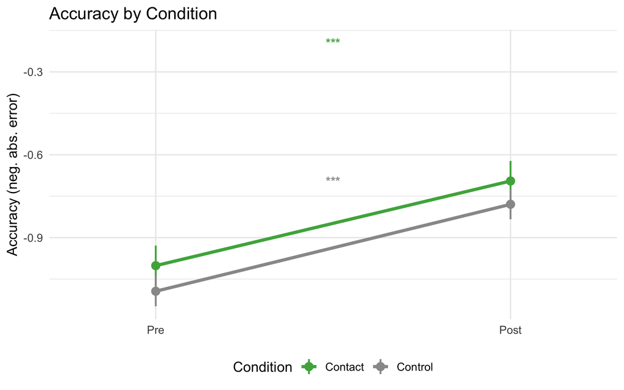

Accuracy (negative absolute error) by condition and time. Points show estimated marginal means ± SE from the mixed-effects model.

```r
emm_acc_tbl <- as_tibble(emm_acc_by_cond) %>%
  mutate(time = factor(time, levels = c("pre", "post")))

p_acc <- ggplot(emm_acc_tbl,
                aes(x = time, y = emmean, group = treatment, color = treatment)) +
  geom_line(linewidth = 1.4) +
  geom_pointrange(aes(ymin = emmean - SE, ymax = emmean + SE), size = 0.6, linewidth = 0.8) +
  # Significance stars per condition (spaced by row index)
  geom_text(data = acc_contrasts %>%
              mutate(
                x = 1.5,
                y = max(emm_acc_tbl$emmean) + 0.5,
                label = p_to_stars(p.value),
                y_offset = (row_number() - 1) * -0.5
              ),
            aes(x = x, y = y + y_offset, label = label, color = treatment),
            size = 4, fontface = "bold", show.legend = FALSE, inherit.aes = FALSE) +
  scale_color_manual(values = condition_colors, name = "Condition") +
  scale_x_discrete(labels = c("Pre", "Post"), expand = expansion(add = 0.3)) +
  labs(y = "Accuracy (neg. abs. error)", x = NULL, title = "Accuracy by Condition") +
  theme_minimal(base_size = 13) +
  theme(legend.position = "bottom")

p_acc
```

```r
ggsave(paste0(fig_path, "accuracy_by_condition.png"), p_acc, width = 8, height = 5, dpi = 300)
```

### Warmth

```r
warmth_long <- dat %>%
  select(ResponseId, treatment, learner_party, warmth_outgroup_pre, warmth_outgroup_post) %>%
  pivot_longer(c(warmth_outgroup_pre, warmth_outgroup_post),
               names_to = "time", names_pattern = "warmth_outgroup_(pre|post)",
               values_to = "warmth") %>%
  mutate(time = factor(time, levels = c("pre", "post")))

m_warm <- lmer(warmth ~ time * treatment + (1 | ResponseId), data = warmth_long)

emm_warm_by_cond <- emmeans(m_warm, ~ time | treatment)
warm_contrasts <- contrast(emm_warm_by_cond, "revpairwise", by = "treatment") %>%
  as_tibble()

emm_warm_full <- emmeans(m_warm, ~ time * treatment)

if (pool_controls) {
  warm_did <- contrast(emm_warm_full, list(
    `Contact vs. Control` = c(1, -1, -1, 1)
  ))
  warm_did_tbl <- warm_did %>% as_tibble() %>% mutate(estimate = -estimate)
  warm_main_b  <- pull_did(warm_did_tbl, "Contact vs. Control", estimate)
  warm_main_se <- pull_did(warm_did_tbl, "Contact vs. Control", SE)
  warm_main_p  <- pull_did(warm_did_tbl, "Contact vs. Control", p.value)
  warm_chat_vs_contact_b <- NA_real_; warm_chat_vs_contact_p <- NA_real_
  warm_game_vs_contact_b <- NA_real_; warm_game_vs_contact_p <- NA_real_
  warm_chat_vs_game_b    <- NA_real_; warm_chat_vs_game_p    <- NA_real_
} else {
  warm_did <- contrast(emm_warm_full, list(
    `Contact vs. pooled controls` = c(-1,  1,  0.5, -0.5,  0.5, -0.5),
    `Chat vs. Contact`            = c( 1, -1, -1,    1,    0,    0  ),
    `Game vs. Contact`            = c( 1, -1,  0,    0,   -1,    1  ),
    `Chat vs. Game`               = c( 0,  0, -1,    1,    1,   -1  )
  ))
  warm_did_tbl           <- warm_did %>% as_tibble()
  warm_main_b            <- pull_did(warm_did_tbl, "Contact vs. pooled controls", estimate)
  warm_main_se           <- pull_did(warm_did_tbl, "Contact vs. pooled controls", SE)
  warm_main_p            <- pull_did(warm_did_tbl, "Contact vs. pooled controls", p.value)
  warm_chat_vs_contact_b <- pull_did(warm_did_tbl, "Chat vs. Contact", estimate)
  warm_chat_vs_contact_p <- pull_did(warm_did_tbl, "Chat vs. Contact", p.value)
  warm_game_vs_contact_b <- pull_did(warm_did_tbl, "Game vs. Contact", estimate)
  warm_game_vs_contact_p <- pull_did(warm_did_tbl, "Game vs. Contact", p.value)
  warm_chat_vs_game_b    <- pull_did(warm_did_tbl, "Chat vs. Game",    estimate)
  warm_chat_vs_game_p    <- pull_did(warm_did_tbl, "Chat vs. Game",    p.value)
}
```

```r
warm_contrasts %>%
  select(Condition = treatment,
         `Pre→Post Improvement` = estimate,
         SE, df, `t-ratio` = t.ratio, `p-value` = p.value) %>%
  mutate(
    `Pre→Post Improvement` = numformat(`Pre→Post Improvement`),
    SE = numformat(SE),
    df = numformat(df, 0),
    `t-ratio` = numformat(`t-ratio`),
    `p-value` = map_chr(`p-value`, pformat)
  ) %>%
  gt() %>%
  tab_header(title = "Warmth: Pre-Post Improvement by Condition") %>%
  tab_footnote("Positive = increase in outgroup warmth. Estimated from mixed-effects model.",
               locations = cells_title())
```

Warmth: Pre-Post Improvement by Condition<sup>1</sup>

| Condition | Pre→Post Improvement | SE | df | t-ratio | p-value |
| --- | --- | --- | --- | --- | --- |
| Contact | 2.45 | 0.74 | 282 | 3.29 | = 0.001 |
| Control | 1.18 | 0.56 | 282 | 2.12 | = 0.035 |

<sup>1</sup> Positive = increase in outgroup warmth. Estimated from mixed-effects model.

**Primary test:** Contact vs. Control: *b* = 1.27, SE = 0.93, *p* = 0.173.

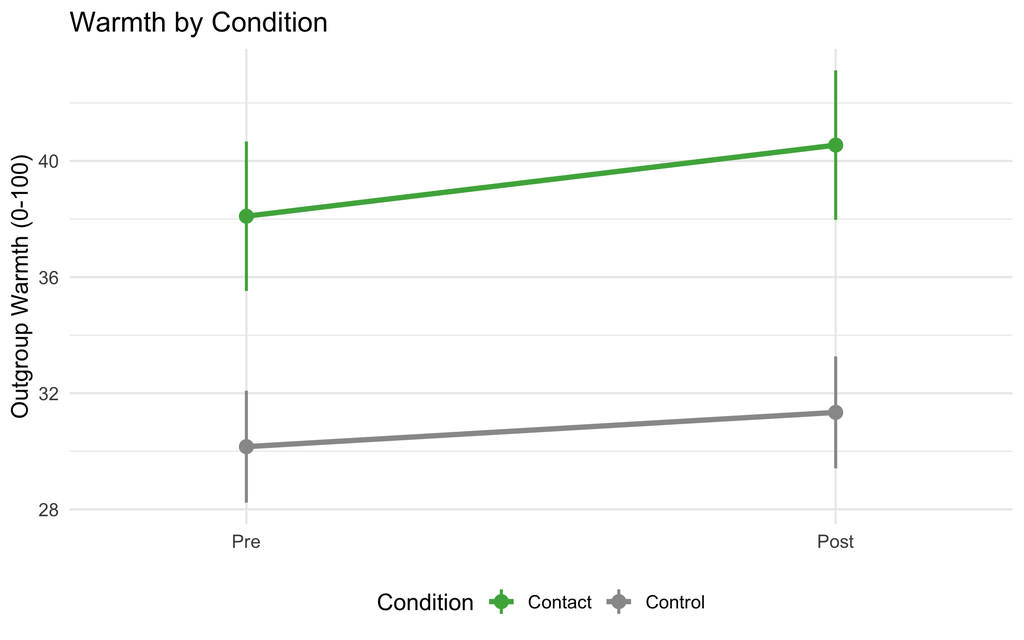

Outgroup warmth (0-100) by condition and time. Points show estimated marginal means ± SE.

```r
emm_warm_tbl <- as_tibble(emm_warm_by_cond) %>%
  mutate(time = factor(time, levels = c("pre", "post")))

p_warm <- ggplot(emm_warm_tbl,
                 aes(x = time, y = emmean, group = treatment, color = treatment)) +
  geom_line(linewidth = 1.4) +
  geom_pointrange(aes(ymin = emmean - SE, ymax = emmean + SE), size = 0.6, linewidth = 0.8) +
  scale_color_manual(values = condition_colors, name = "Condition") +
  scale_x_discrete(labels = c("Pre", "Post"), expand = expansion(add = 0.3)) +
  labs(y = "Outgroup Warmth (0-100)", x = NULL, title = "Warmth by Condition") +
  theme_minimal(base_size = 13) +
  theme(legend.position = "bottom")

p_warm
```

```r
ggsave(paste0(fig_path, "warmth_by_condition.png"), p_warm, width = 8, height = 5, dpi = 300)
```

### Confidence

```r
confidence_long <- dat %>%
  select(ResponseId, treatment, learner_party, confidence_outgroup_pre, confidence_outgroup_post) %>%
  pivot_longer(c(confidence_outgroup_pre, confidence_outgroup_post),
               names_to = "time", names_pattern = "confidence_outgroup_(pre|post)",
               values_to = "confidence") %>%
  mutate(time = factor(time, levels = c("pre", "post")))

m_conf <- lmer(confidence ~ time * treatment + (1 | ResponseId), data = confidence_long)

emm_conf_by_cond <- emmeans(m_conf, ~ time | treatment)
conf_contrasts <- contrast(emm_conf_by_cond, "revpairwise", by = "treatment") %>%
  as_tibble()

emm_conf_full <- emmeans(m_conf, ~ time * treatment)

if (pool_controls) {
  conf_did <- contrast(emm_conf_full, list(
    `Contact vs. Control` = c(1, -1, -1, 1)
  ))
  conf_did_tbl <- conf_did %>% as_tibble() %>% mutate(estimate = -estimate)
  conf_main_b  <- pull_did(conf_did_tbl, "Contact vs. Control", estimate)
  conf_main_se <- pull_did(conf_did_tbl, "Contact vs. Control", SE)
  conf_main_p  <- pull_did(conf_did_tbl, "Contact vs. Control", p.value)
  conf_chat_vs_contact_b <- NA_real_; conf_chat_vs_contact_p <- NA_real_
  conf_game_vs_contact_b <- NA_real_; conf_game_vs_contact_p <- NA_real_
  conf_chat_vs_game_b    <- NA_real_; conf_chat_vs_game_p    <- NA_real_
} else {
  conf_did <- contrast(emm_conf_full, list(
    `Contact vs. pooled controls` = c(-1,  1,  0.5, -0.5,  0.5, -0.5),
    `Chat vs. Contact`            = c( 1, -1, -1,    1,    0,    0  ),
    `Game vs. Contact`            = c( 1, -1,  0,    0,   -1,    1  ),
    `Chat vs. Game`               = c( 0,  0, -1,    1,    1,   -1  )
  ))
  conf_did_tbl           <- conf_did %>% as_tibble()
  conf_main_b            <- pull_did(conf_did_tbl, "Contact vs. pooled controls", estimate)
  conf_main_se           <- pull_did(conf_did_tbl, "Contact vs. pooled controls", SE)
  conf_main_p            <- pull_did(conf_did_tbl, "Contact vs. pooled controls", p.value)
  conf_chat_vs_contact_b <- pull_did(conf_did_tbl, "Chat vs. Contact", estimate)
  conf_chat_vs_contact_p <- pull_did(conf_did_tbl, "Chat vs. Contact", p.value)
  conf_game_vs_contact_b <- pull_did(conf_did_tbl, "Game vs. Contact", estimate)
  conf_game_vs_contact_p <- pull_did(conf_did_tbl, "Game vs. Contact", p.value)
  conf_chat_vs_game_b    <- pull_did(conf_did_tbl, "Chat vs. Game",    estimate)
  conf_chat_vs_game_p    <- pull_did(conf_did_tbl, "Chat vs. Game",    p.value)
}
```

```r
conf_contrasts %>%
  select(Condition = treatment,
         `Pre→Post Change` = estimate,
         SE, df, `t-ratio` = t.ratio, `p-value` = p.value) %>%
  mutate(
    `Pre→Post Change` = numformat(`Pre→Post Change`),
    SE = numformat(SE),
    df = numformat(df, 0),
    `t-ratio` = numformat(`t-ratio`),
    `p-value` = map_chr(`p-value`, pformat)
  ) %>%
  gt() %>%
  tab_header(title = "Confidence: Pre-Post Change by Condition") %>%
  tab_footnote("Positive = increase in confidence. Estimated from mixed-effects model.",
               locations = cells_title())
```

Confidence: Pre-Post Change by Condition<sup>1</sup>

| Condition | Pre→Post Change | SE | df | t-ratio | p-value |
| --- | --- | --- | --- | --- | --- |
| Contact | 0.49 | 0.10 | 282 | 4.83 | < .001 |
| Control | 0.15 | 0.08 | 282 | 1.95 | = 0.052 |

<sup>1</sup> Positive = increase in confidence. Estimated from mixed-effects model.

**Primary test:** Contact vs. Control: *b* = 0.34, SE = 0.13, *p* = 0.007.

## Behavioral Outcomes by Condition

### Dictator Game Donation

```r
dat <- dat %>% mutate(donated_any = as.integer(donation > 0))

don_by_condition <- dat %>%
  group_by(treatment) %>%
  summarise(
    N          = n(),
    M          = mean(donation, na.rm = TRUE),
    SD         = sd(donation, na.rm = TRUE),
    SE         = SD / sqrt(N),
    pct_donated = mean(donated_any) * 100,
    mean_pos   = mean(donation[donation > 0], na.rm = TRUE),
    .groups = "drop"
  )

# Continuous donation: overall ANOVA + Tukey pairwise
don_aov <- aov(donation ~ treatment, data = dat)
don_aov_p <- summary(don_aov)[[1]][["Pr(>F)"]][1]
don_aov_f <- summary(don_aov)[[1]][["F value"]][1]
don_pairwise <- dat %>% tukey_hsd(donation ~ treatment)

extract_tukey <- function(tbl, g1, g2) {
  tbl %>% filter(group1 == g1, group2 == g2)
}

# Stage 1 (any donation): overall ANOVA + Tukey pairwise
don_aov_bin <- aov(donated_any ~ treatment, data = dat)
don_aov_bin_p <- summary(don_aov_bin)[[1]][["Pr(>F)"]][1]
don_aov_bin_f <- summary(don_aov_bin)[[1]][["F value"]][1]
don_pairwise_bin <- dat %>% tukey_hsd(donated_any ~ treatment)

# Stage 2 (amount among donors): ANOVA
dat_donors <- dat %>% filter(donated_any == 1)
don_aov_pos <- aov(donation ~ treatment, data = dat_donors)
don_aov_pos_p <- summary(don_aov_pos)[[1]][["Pr(>F)"]][1]
don_aov_pos_f <- summary(don_aov_pos)[[1]][["F value"]][1]

# Condition-specific pairwise (only meaningful when 3 conditions)
if (!pool_controls) {
  don_cont_chat_game     <- extract_tukey(don_pairwise,     "Chat", "Game")
  don_bin_contact_chat_p <- extract_tukey(don_pairwise_bin, "Contact", "Chat")$p.adj
  don_bin_contact_game_p <- extract_tukey(don_pairwise_bin, "Contact", "Game")$p.adj
  don_bin_chat_game_p    <- extract_tukey(don_pairwise_bin, "Chat",    "Game")$p.adj
} else {
  don_cont_chat_game     <- tibble(p.adj = NA_real_)
  don_bin_contact_chat_p <- NA_real_
  don_bin_contact_game_p <- extract_tukey(don_pairwise_bin, "Contact", "Control")$p.adj
  don_bin_chat_game_p    <- NA_real_
}
```

```r
don_by_condition %>%
  mutate(across(c(M, SD, SE, mean_pos), numformat),
         pct_donated = numformat(pct_donated, 0)) %>%
  select(Condition = treatment, N,
         `% Donated` = pct_donated,
         `Mean (all)` = M, SD,
         `Mean (donors only)` = mean_pos) %>%
  gt() %>%
  tab_header(title = "Dictator Game: Donation by Condition") %>%
  tab_footnote("% Donated = proportion who gave any amount > 0. Mean (donors only) excludes zeros.",
               locations = cells_title())
```

Dictator Game: Donation by Condition<sup>1</sup>

| Condition | N | % Donated | Mean (all) | SD | Mean (donors only) |
| --- | --- | --- | --- | --- | --- |
| Contact | 102 | 60 | 21.85 | 21.39 | 36.54 |
| Control | 182 | 55 | 20.29 | 21.68 | 36.92 |

<sup>1</sup> % Donated = proportion who gave any amount > 0. Mean (donors only) excludes zeros.

```r
bind_rows(
  don_pairwise %>% select(group1, group2, estimate, p.adj) %>% mutate(DV = "Continuous (0-50¢)"),
  don_pairwise_bin %>% select(group1, group2, estimate, p.adj) %>% mutate(DV = "Any donation (0/1)")
) %>%
  mutate(
    Comparison = paste0(group1, " vs. ", group2),
    estimate = numformat(estimate),
    p.adj = map_chr(p.adj, pformat)
  ) %>%
  select(DV, Comparison, `Difference` = estimate, `p (Tukey)` = p.adj) %>%
  gt() %>%
  tab_header(title = "Pairwise Tukey Comparisons: Donation") %>%
  tab_footnote("Tukey-corrected p-values.", locations = cells_title())
```

Pairwise Tukey Comparisons: Donation<sup>1</sup>

| DV | Comparison | Difference | p (Tukey) |
| --- | --- | --- | --- |
| Continuous (0-50¢) | Contact vs. Control | -1.57 | = 0.558 |
| Any donation (0/1) | Contact vs. Control | -0.05 | = 0.430 |

<sup>1</sup> Tukey-corrected p-values.

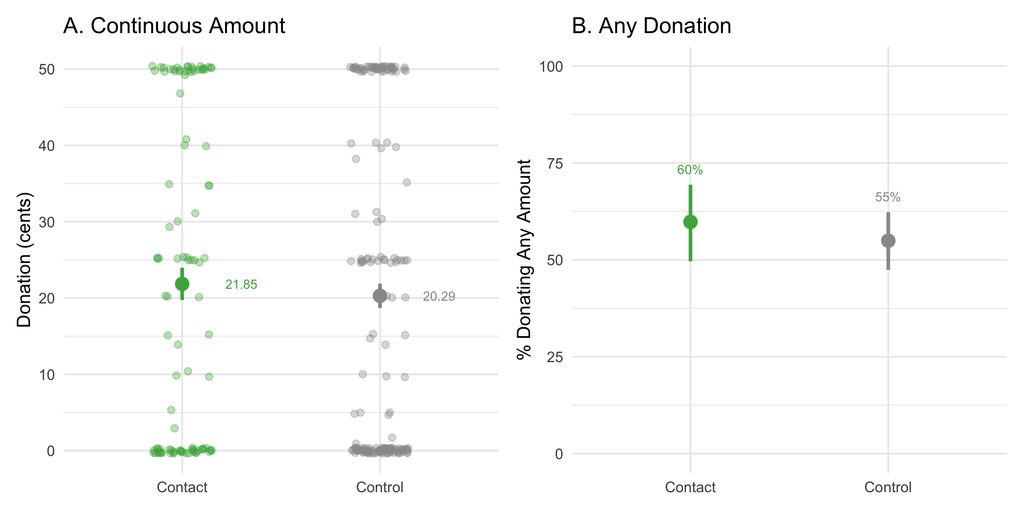

Left: Dictator game donation (0-50 cents) by condition — individual points, mean ± SE. Right: Proportion donating any amount.

```r
p_don_cont <- ggplot(dat, aes(x = treatment, y = donation, color = treatment)) +
  geom_jitter(width = 0.15, alpha = 0.35, size = 2) +
  geom_pointrange(data = don_by_condition,
                  aes(x = treatment, y = M, ymin = M - SE, ymax = M + SE),
                  size = 0.8, linewidth = 1.2, inherit.aes = FALSE,
                  color = condition_colors[as.character(don_by_condition$treatment)]) +
  geom_text(data = don_by_condition,
            aes(x = treatment, y = M, label = numformat(M)),
            nudge_x = 0.3, size = 3.2, show.legend = FALSE,
            color = condition_colors[as.character(don_by_condition$treatment)]) +
  scale_color_manual(values = condition_colors) +
  labs(y = "Donation (cents)", x = NULL, title = "A. Continuous Amount") +
  theme_minimal(base_size = 13) +
  theme(legend.position = "none")

# % donated panel with 95% CI
don_bin_ci <- don_by_condition %>%
  mutate(
    n_donated = round(pct_donated / 100 * N),
    ci_lo = map2_dbl(n_donated, N, ~ binom.test(.x, .y)$conf.int[1] * 100),
    ci_hi = map2_dbl(n_donated, N, ~ binom.test(.x, .y)$conf.int[2] * 100)
  )

p_don_bin <- ggplot(don_bin_ci, aes(x = treatment, y = pct_donated, color = treatment)) +
  geom_pointrange(aes(ymin = ci_lo, ymax = ci_hi), size = 0.8, linewidth = 1.2) +
  geom_text(aes(y = ci_hi + 4, label = paste0(round(pct_donated), "%")),
            size = 3.2, show.legend = FALSE) +
  scale_color_manual(values = condition_colors) +
  scale_y_continuous(limits = c(0, 100), breaks = seq(0, 100, 25)) +
  labs(y = "% Donating Any Amount", x = NULL, title = "B. Any Donation") +
  theme_minimal(base_size = 13) +
  theme(legend.position = "none")

p_don <- p_don_cont + p_don_bin
p_don
```

```r
ggsave(paste0(fig_path, "donation_by_condition.png"), p_don, width = 10, height = 5, dpi = 300)
```

### Talk Partner Preference

```r
dat <- dat %>%
  mutate(
    chose_outgroup = case_when(
      participant_party == "Democrat"   & talk_partner == "I'd rather talk with a republican" ~ 1,
      participant_party == "Republican" & talk_partner == "I'd rather talk with a democrat"   ~ 1,
      TRUE ~ 0
    )
  )

talk_by_condition <- dat %>%
  group_by(treatment) %>%
  summarise(
    n_total      = n(),
    n_outgroup   = sum(chose_outgroup, na.rm = TRUE),
    pct_outgroup = n_outgroup / n_total * 100,
    ci_lo = binom.test(n_outgroup, n_total)$conf.int[1] * 100,
    ci_hi = binom.test(n_outgroup, n_total)$conf.int[2] * 100,
    .groups = "drop"
  )

# Overall chi-square
talk_tab <- table(dat$treatment, dat$chose_outgroup)
talk_chisq <- chisq.test(talk_tab)

# Pairwise Fisher's exact tests (only when 3 conditions exist)
if (!pool_controls) {
  fish_contact_chat <- fisher.test(talk_tab[c("Contact", "Chat"), ])
  fish_contact_game <- fisher.test(talk_tab[c("Contact", "Game"), ])
  fish_chat_game    <- fisher.test(talk_tab[c("Chat",    "Game"), ])
} else {
  fish_contact_chat <- list(p.value = NA_real_, estimate = NA_real_)
  fish_contact_game <- fisher.test(talk_tab[c("Contact", "Control"), ])
  fish_chat_game    <- list(p.value = NA_real_, estimate = NA_real_)
}
```

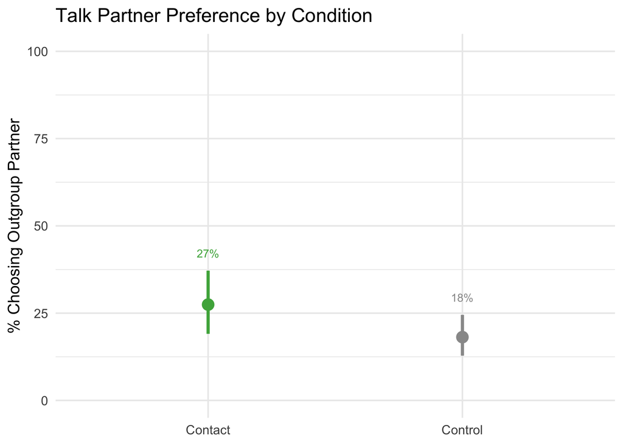

Proportion choosing to talk with an outgroup member by condition. Error bars show 95% CI.

```r
p_talk <- ggplot(talk_by_condition,
                 aes(x = treatment, y = pct_outgroup, color = treatment)) +
  geom_pointrange(aes(ymin = ci_lo, ymax = ci_hi), size = 0.8, linewidth = 1.2) +
  geom_text(aes(y = ci_hi + 5, label = paste0(round(pct_outgroup), "%")),
            size = 3.2, show.legend = FALSE) +
  scale_color_manual(values = condition_colors) +
  scale_y_continuous(limits = c(0, 100), breaks = seq(0, 100, 25)) +
  labs(y = "% Choosing Outgroup Partner", x = NULL,
       title = "Talk Partner Preference by Condition") +
  theme_minimal(base_size = 13) +
  theme(legend.position = "none")

p_talk
```

```r
ggsave(paste0(fig_path, "talk_partner_by_condition.png"), p_talk, width = 7, height = 5, dpi = 300)
```

The overall chi-square test for condition differences in outgroup partner preference: *χ²* = 2.84, *p* = 0.092. Contact vs. Control: OR = 0.59, *p* = 0.072.